# Basic Histology: Smart Study Notes

Junqueira 17th edition — understand, recognize, remember

2026

# START HERE

## Understand it. See it. Remember it.

**Histology explains how microscopic structure makes an organ work.** Learn to recognize a tissue, explain why it has its structure, and distinguish it from its closest look-alike. These notes follow the 23 chapters of **Junqueira’s Basic Histology: Text & Atlas, 17th edition**. They make the reference easier to study; for the complete atlas and finer details, use the corresponding Junqueira chapter.

Each chapter opens with a **concept map**: the central idea leads to six branches with two key facts each. Read the two arrow pathways, then the **Quick notes**: essentials, a comparison, a memory cue and a recall question. A clear explanation follows. At the end, test yourself using the chapter summary, recall questions, a worked examination question and a specimen-identification task. **Students and teachers use the same book.**

### The five-step method

1. **Preview:** Trace the mind map from center to branches, then read the Quick notes. Name one topic you already understand and one you cannot yet explain.
2. **Understand:** Read the explanation in small sections. Link each structure to **location, appearance and function**.
3. **Recognize:** Look at the diagram and then a real microscope image. Identify **two visible landmarks** and one plausible look-alike.
4. **Recall:** Close the page. Reconstruct the main idea, answer the questions and explain why a tempting wrong answer is wrong.
5. **Return:** Test yourself again after roughly **1, 3, 7, 14 and 30 days**. Shorten the interval for anything forgotten. Keep a small error log instead of rereading the whole chapter.

**For teachers:** Start with the mind map, explain each branch with the Quick notes, demonstrate its histological landmarks, compare two similar tissues and finish with closed-book recall and the chapter’s worked question. No separate instructor manual is needed.

### Five questions for an unfamiliar slide

1. **Surface or boundary:** Is there a lumen, capsule, basement membrane or free surface?
2. **Overall pattern:** Are the structures layers, follicles, tubules, acini, cords, bundles or sinusoids?
3. **Diagnostic feature:** Which nuclei, granules, fibers, glands or cell arrangement establish the identity?
4. **Function:** What task does the structure make possible—exchange, secretion, absorption, support, movement or protection?
5. **Closest mimic:** What single observation distinguishes it from the likeliest alternative?

*Example:* Intestinal villi point to small intestine, not colon. **Brunner glands in the submucosa** strongly suggest duodenum; if the biopsy lacks submucosa, absence of those glands is not decisive.

### Your examination pathway

The following labels use the chapter lists supplied for Afghanistan’s Ministry of Public Health specialist entrance preparation. **Confirm the current official notice** before excluding any chapter.

| Track | Junqueira chapters | Total |
| --- | --- | --- |
| **Internal Medicine (داخله)** | 1–6, 9, 11–18, 20 | 16 |
| **Surgery (جراحی)** | 1–14, 19, 21–23 | 18 |
| **Shared foundation** | 1–6, 9, 11–14 | 11 |

Chapter 24 is an optional rapid review, not an additional assigned Junqueira chapter. The 100 questions at the end are **original practice questions**, not verified past Ministry examination questions.

### Source and illustrations

**Primary reference:** Mescher AL. *Junqueira’s Basic Histology: Text & Atlas*. 17th ed. McGraw Hill; 2024. Chapters 1–23 follow the same numbered subjects. Use the reference’s atlas or the viewing-only slide links in Appendix E for genuine microscopic appearances.

The **23 original concept maps and 12 original tissue schematics** appear within the relevant chapters. They organize ideas and illustrate structures; they are not H&E photographs or scale drawings. Appendix D indexes the twelve tissue schematics. Appendix C lists further scientific reading.

# PART I — CELLS AND TECHNIQUES

## 1 · Histology & Its Methods of Study

**SPECIALTY EXAM:** `INTERNAL MEDICINE` · `SURGERY`

**In this chapter:** Preparation of Tissues for Study · Light Microscopy · Electron Microscopy · Autoradiography · Cell & Tissue Culture · Enzyme Histochemistry · Visualizing Specific Molecules · Interpretation of Structures in Tissue Sections

### Chapter mind map — see the whole first

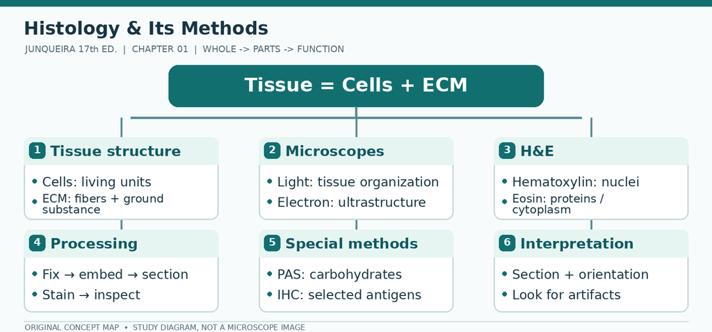

Chapter 1 original concept map: Tissue = Cells + ECM; branches for Tissue structure, Microscopes, H&E, Processing, Special methods, Interpretation

**Two pathways to remember**

- **Composition:** Tissue → Cells + Extracellular Matrix → ECM fibers + ground substance
- **Progression:** Specimen → fixation → embedding → sectioning → staining → interpretation

### Quick notes — understand in 90 seconds

- **Histology** studies cells, extracellular matrix (ECM), and how tissues form functioning organs.
- **Routine H&E workflow:** fixation → dehydration → clearing → paraffin embedding → thin section → staining.
- **Hematoxylin** highlights nucleic-acid-rich regions (blue/purple); **eosin** stains many proteins (pink).
- **Light microscopy** shows tissue architecture; **electron microscopy** resolves organelle ultrastructure.
- **Artifacts** from shrinkage, folding, and poor fixation may resemble genuine tissue features.

**High-yield comparison:** PAS highlights many carbohydrate-rich structures; immunohistochemistry locates a selected antigen—neither is equivalent to routine H&E.

> **MNEMONIC** — Always ask: **What was preserved? What was stained? At what resolution?**

**Recall without looking:** Which preparation step can remove stored lipid and leave adipocytes apparently empty?

### Learning objectives

By the end of this chapter you should be able to:

1. Trace a tissue from patient to stained slide, and explain what each step preserves.
2. Predict what hematoxylin and eosin will color, and why.
3. Choose the right special technique for a target molecule (carbohydrate, lipid, protein, nucleic acid, antigen).
4. Explain how section thickness, fixation, and artifact can mislead you when you interpret a two-dimensional image.

### The core idea

Histology explores the body’s tissues and how they are arranged to produce functional organs. Tissues have two interacting components: **cells and extracellular matrix (ECM)**. The ECM is not packing material — it supports the cells, carries the fluid that brings nutrients and removes waste, and its molecules bind specific cell-surface receptors connected to structural components inside the cell, forming a continuum in which cells and matrix function together.

Organs form by an orderly combination of these tissues. Because cells and matrix components are small, histology depends on microscopes and molecular methods — and many routine bright-field images come from fixed, dehydrated, cleared, embedded, sectioned and stained tissue. Frozen sections, live-cell imaging and some specialized methods use different workflows.

Knowing what each step does tells you which appearances are real and which are artifacts.

### Preparation of Tissues for Study

[output not shown]

**A concentration note.** Formalin is often described as a buffered isotonic solution of 37% formaldehyde. That 37–40% solution is the **stock** from which working fixative is made; tissue is fixed in **10% formalin**, equivalent to about 3.7–4% formaldehyde, buffered to pH 7.2–7.4 (neutral buffered formalin). Keep the two concentrations apart in practical questions.

**The units** you should be able to convert: 1 µm = 1/1000 mm; 1 nm = 0.001 µm = 10⁻⁶ mm; 1 Å = 0.1 nm = 10⁻⁴ µm.

**Plastic resins** are used for both light and electron microscopy. They are infiltrated after dehydration and harden when cross-linking polymerisers are added; some resins can be polymerized at lower temperatures than paraffin processing, but resin embedding does not eliminate processing artifacts, and some protocols use heat.

> **CLINICAL** — **Biopsies** are tissue samples removed during surgery or routine procedures, fixed in vials of formalin. When the result is needed *before the procedure ends* — typically to know whether a growth is malignant before the patient is closed — the specimen is **rapidly frozen** using an appropriate cooling method and sectioned in a **cryostat**. Direct immersion in liquid nitrogen is not universally used and may introduce freezing artifacts. Freezing is also used for histochemistry of **sensitive enzymes or small molecules**, because freezing can preserve enzyme activities that routine fixation may diminish; and because routine organic solvents extract many lipids, **frozen sections are often preferred for demonstrating neutral lipids**.

### Staining

Most cells and extracellular material are completely colorless. Dyes behave like acidic or basic compounds and form **electrostatic (salt) linkages** with ionisable radicals of tissue macromolecules.

| Term | Meaning | Examples |
| --- | --- | --- |
| **Basophilic** | Anionic (net negative) components with affinity for **basic dyes** — nucleic acids, glycosaminoglycans | Toluidine blue, alcian blue, methylene blue, **hematoxylin** |
| **Acidophilic** | Cationic components with many ionised amino groups, staining with **acidic dyes** — mitochondria, secretory granules, collagen | **Eosin**, orange G, acid fuchsin |

**H&E** is the most common method. **Hematoxylin** stains DNA in the nucleus, RNA-rich cytoplasm, and cartilage matrix dark blue-purple; **eosin** stains other cytoplasmic structures and collagen pink and acts as the **counterstain**. **Trichrome** stains (eg, Masson) allow greater distinction among extracellular components.

**The PAS reaction** uses the hexose rings of polysaccharides and other carbohydrate-rich structures and stains them distinctly **purple or magenta** — the basis for demonstrating glycogen, mucin, and basement membranes. The **Feulgen reaction** is a distinct DNA-specific method: controlled acid hydrolysis exposes aldehyde groups in DNA, which then react with Schiff reagent.

**Enzyme digestion** identifies what a stain is binding: pretreating a section with an enzyme that digests one substrate. Pretreatment with **ribonuclease** greatly reduces cytoplasmic basophilia with little effect on the nucleus, proving that the cytoplasmic staining depended on RNA.

**Lipid-soluble dyes** such as **Sudan black** reveal lipid-rich structures — provided the processing steps that remove lipids (heat and organic solvents) are avoided. **Metal impregnation** with silver salts visualizes certain ECM fibers and specific elements in nervous tissue. The staining procedures used for most light micrographs are conventional, and the ones you will meet are summarized below.

**The staining palette.** Learn what each one makes visible, because a report that says “Mallory trichrome” is telling you which structures were deliberately contrasted:

| Stain | Nuclei | Cytoplasm | Collagen / other | Where you meet it |
| --- | --- | --- | --- | --- |
| **H&E** | Blue-purple (hematoxylin) | Pink (eosin) | Collagen pink | Almost every chapter |
| **PT** (pararosaniline–toluidine blue) | Purple chromatin | Lighter violet | Collagen pale violet | Plastic sections needing fine detail |
| **Mallory trichrome** | Purple | Red-orange (also keratin, erythrocytes) | **Blue** | Connective tissue, small vessels, pituitary, kidney |
| **Picrosirius–hematoxylin (PSH)** | Purple | Pink-violet | **Collagen red**, birefringent under polarized light | Ovary, cartilage, tendon |
| **PAS** | — | Magenta where carbohydrate is abundant | Glycogen, mucin, basement membrane, glycocalyx | Gut, kidney, cartilage |
| **Wright–Giemsa** | Purple | Granules color differentially | Erythrocytes pink | Blood and marrow smears |
| **Silver / gold** | — | — | Nerve filaments and **reticulin (type III)** black-brown | Nervous tissue, lymphoid organs |
| **Elastin stains** (Weigert, aldehyde fuchsin, orcein) | — | — | Elastic fibers brown-purple | Aorta, lung, skin |
| **Lipid stains** (oil red O, Sudan black, osmium tetroxide) | — | — | Lipid droplets and myelin | Adipose tissue, steroid cells, nerve |

Slide preparation, from fixation to observation, takes **12 hours to 2½ days**, depending on tissue size, embedding medium, and staining method.

### Light Microscopy

The **bright-field microscope** has three lens sets:

- **Condenser** — collects and focuses a cone of light onto the slide.
- **Objective** — enlarges and projects the image; routine objectives are **×4** (large field), **×10** (medium), **×40** (detail).
- **Eyepiece (ocular)** — magnifies a further **×10**, giving total magnifications of **×40, ×100, ×400**. Total magnification = objective × ocular.

**Resolving power** — the smallest distance at which two structures are seen as separate — is the critical factor, and conventional bright-field light microscopy typically achieves lateral resolution of about **0.2 µm** under favorable conditions. Higher magnification alone cannot recover detail below the resolution limit. Anything smaller or thinner than 0.2 µm (a single ribosome, a microfilament) cannot be distinguished, and two mitochondria closer than 0.2 µm appear as one. Resolution depends mainly on the **objective lens**; the ocular only enlarges and does **not** improve resolution. *Magnification is of value only when accompanied by resolution.*

**Virtual microscopy** converts a stained slide into high-resolution digital images captured in a grid at multiple magnifications, stored so a browser can navigate the original slide — now replacing glass slide collections in teaching laboratories.

| Method | Principle | Use |
| --- | --- | --- |
| **Fluorescence** | Fluorophores emit longer-wavelength light when irradiated; bright on a dark background | **DAPI** and **Hoechst** bind DNA (blue); **acridine orange** binds DNA and RNA and emits different colors, localizing them separately; fluorescein-coupled probes and labeled antibodies |
| **Phase-contrast** | Light changes speed through structures of different refractive index, producing contrast in transparent objects | **Living, unstained cultured cells**; **DIC (Nomarski optics)** gives a more three-dimensional image |
| **Confocal** | A laser point source and a **pinhole aperture** optically conjugated to the focal plane block out-of-focus light; the beam scans the specimen | Thin **optical sections**, localization with great precision, and 3-D reconstruction |
| **Polarizing** | A polarizing filter passes light vibrating in one direction; oriented macromolecules rotate it and appear bright against a dark background — **birefringence** | Collagen, cellulose, microtubules, actin filaments; only material with repetitive periodic structure is seen |

Digital cameras extend all of these methods: images can be quantified, enhanced, and analyzed by software for features not visible through the eyepieces.

### Electron Microscopy

The wavelength of an electron beam is far shorter than that of light, so the electron microscope can resolve structures far below the light-microscope limit — in principle, a thousandfold improvement.

**Transmission EM (TEM)** resolves to about **3 nm** in routine biological sections — the working figure, limited by section thickness and staining rather than by the instrument alone. A modern TEM can reach a point-to-point resolution of about **0.2 nm** on suitable specimens, which is why both numbers appear in teaching; use **3 nm for sectioned tissue** and **0.2 nm only when the question asks for the instrument’s limit**. Either way, TEM views isolated particles magnified as much as **400,000×**. Routine tissue sections of **40–90 nm** embedded in resin are studied at up to about **120,000×**. Electrons pass through the section to produce an image in black, white, and gray: areas that transmitted electrons appear **electron lucent** (bright), while denser areas or those binding heavy metal ions appear **electron dense** (dark). The column is configured like an upside-down light microscope, with electromagnetic lenses and a tungsten filament cathode accelerating electrons at 60–120 kV.

**Scanning EM (SEM)** images the surface in three dimensions.

### Autoradiography

A **radiolabeled precursor** is incorporated into newly synthesized macromolecules and detected by a photographic emulsion applied over the section — so the silver grains mark the **cellular sites where those macromolecules were made**. The classic application is **³H-thymidine** labeling of cells in S phase.

### Cell & Tissue Culture

Living cells maintained outside the body, observed with phase-contrast or DIC microscopy, allow behavior, differentiation, and drug responses to be studied directly — without fixation, which is precisely the advantage.

### Enzyme Histochemistry

A substrate is converted by a specific enzyme into an **insoluble, colored product** deposited at the site of the enzyme, localizing enzyme activity within cells. **Acid phosphatase** for lysosomes is the standard example.

### Visualizing Specific Molecules

**Immunohistochemistry (IHC)** depends on the specific reaction between an antigen and an antibody labeled with a visible marker — a fluorescent compound or **peroxidase** for light microscopy, **gold particles** for TEM.

| Method | How it works | Why it is used |
| --- | --- | --- |
| **Direct IHC** | A labeled **primary antibody** binds the antigen directly | Simple, fewer steps |
| **Indirect IHC** | An unlabeled primary antibody is detected by labeled **secondary antibodies** | **More commonly used** — the extra level of binding **amplifies the signal** and gives greater technical flexibility |

**In situ hybridization (ISH)** uses labeled **cDNA probes** to detect specific gene sequences or mRNAs microscopically.

### Interpretation of Structures in Tissue Sections

Two rules govern the interpretation of every section:

1. Many processing, preparation, and staining steps introduce **artifacts** — spaces and precipitates not present in living tissue — and these must be recognized for what they are.
2. Sections are essentially **two-dimensional planes through three-dimensional structures**, so what you see is a slice, not the whole object.

> **MICRO** — Before identifying anything, decide whether it could be an artifact. A clear space around every cell usually means shrinkage; a straight edge through the tissue is a knife mark; granular debris is precipitated stain. True structure has irregular, biological boundaries.

> **TIP** — Three numbers carry the chapter: **0.2 µm** (light microscope resolution), **3–10 µm** (paraffin section thickness), **about 3 nm** (TEM resolution of routine sections). If a question asks why the electron microscope reveals organelles that the light microscope cannot, the answer is **the shorter wavelength of the electron beam**, not the magnification.

> **PEARL** — A useful chain to remember from Chapter 1: **dehydration precedes clearing**, clearing makes the tissue translucent, and **freezing avoids both** — which is why frozen sections are used for rapid diagnosis, for enzymes, and for lipids.

### Laboratory Reasoning: Choosing a Method and Recognizing Artifacts

A useful histology result begins with a **question**, not a stain. Decide what structure or molecule must be demonstrated, what resolution is required, and what the specimen-processing method might destroy.

| Question | Useful starting approach | Important limitation |
| --- | --- | --- |
| What is the overall tissue architecture? | Formalin-fixed, paraffin-embedded section with H&E | Fine molecular identity cannot be inferred from color alone |
| Is a carbohydrate-rich structure present? | PAS with appropriate controls; diastase digestion when testing for glycogen | PAS positivity is not specific for glycogen |
| Where is a particular protein expressed? | Validated immunohistochemistry or immunofluorescence | Antibody specificity, fixation and controls determine interpretability |
| Are neutral lipid droplets present? | Suitable frozen section with a lipid stain | Routine paraffin processing extracts many lipids |
| What is the ultrastructure of a membrane or organelle? | Electron microscopy with appropriate preparation | Small field of view and preparation artifacts complicate interpretation |
| Is a target nucleic-acid sequence present? | In situ hybridization with appropriate probes and controls | Signal quality depends on preservation, accessibility and probe specificity |

**Artifact checklist.** Tissue shrinkage can produce artificial gaps between cells. Poor fixation can cause loss of cellular detail and autolysis. Compression or chatter during microtomy can distort tissue architecture. Folding may mimic an additional epithelial layer. A poorly oriented cut may make a round tubule look elongated or hide a gland’s opening.

**Worked example.** A pale circular space in a paraffin section is not automatically a blood vessel. Ask whether it has an endothelial lining, contains erythrocytes, and is connected to other vascular structures. An adipocyte may also appear empty because lipid was extracted during processing, but it usually has a thin rim of cytoplasm and a displaced nucleus.

**Quality-control habit.** Record the stain, magnification, specimen orientation and relevant positive and negative controls before drawing a molecular conclusion. Distinguish what is directly visible from what is inferred.

### Chapter 1 — summary

- H&E = the routine survey stain; hematoxylin is basic (nuclei, rough ER), eosin is acidic (collagen, cytoplasm).
- Resolution: light microscope about 0.2 µm; TEM about 3 nm in routine sections.
- Fixation cross-links proteins; formalin is the standard fixative, glutaraldehyde for EM.
- Paraffin sections are 3–10 µm; frozen sections are used for urgent diagnosis and for lipid.
- PAS stains carbohydrates magenta; it demonstrates glycogen, mucin, and basement membranes.
- Immunohistochemistry localizes a specific antigen with an antibody; in situ hybridization localizes a specific nucleic acid sequence.
- Artifacts — shrinkage, knife marks, precipitated stain — must be recognized before any structure is identified.
- A 2D section samples one plane, so a tube can look like a ring and a sphere like a circle.

### Active recall

Answer each from memory before checking.

1. **What does formalin do to a tissue?** — Cross-links proteins, preserving structure while making the tissue firm enough to section.
2. **Which dye stains nuclei, and why?** — Hematoxylin, a basic dye that binds acidic nucleic acids (DNA and RNA).
3. **What does PAS demonstrate?** — Carbohydrates, glycogen, and glycoprotein-rich structures such as basement membranes.
4. **Light microscope versus electron microscope resolution?** — About 0.2 µm versus about 3 nm in routine sections, roughly two orders of magnitude.
5. **Why is a 5-µm section dangerous to interpret in one glance?** — It samples a single plane; a tube can look like a ring, a sphere like a circle, and a fold like a septum.

### Exam-style question

**A research group needs to show that a newly described protein is present in the basal layer of the epidermis. Which technique is the most direct choice?**

A. Hematoxylin and eosin  
B. Periodic acid–Schiff  
C. Immunohistochemistry with a specific antibody  
D. Sudan black

**Answer: C** — Immunohistochemistry localizes a specific protein by antibody binding. H&E shows general morphology, PAS shows carbohydrates, and Sudan black shows lipids.

### Practical identification

Work with a real or virtual H&E section. At low power, locate the tissue edge, any free surface and any capsule; at high power, find nuclei, cytoplasm and extracellular matrix. Then look deliberately for artifacts: clear spaces around cells (shrinkage), straight knife marks, folded or torn areas, and precipitated stain.

If phase-contrast, fluorescence or confocal images are available, compare what each reveals and explain why a structure may be visible in one preparation and invisible in another.

## 2 · The Cytoplasm

**SPECIALTY EXAM:** `INTERNAL MEDICINE` · `SURGERY`

**In this chapter:** Cell Differentiation · The Plasma Membrane · Cytoplasmic Organelles · The Cytoskeleton · Inclusions

### Chapter mind map — see the whole first

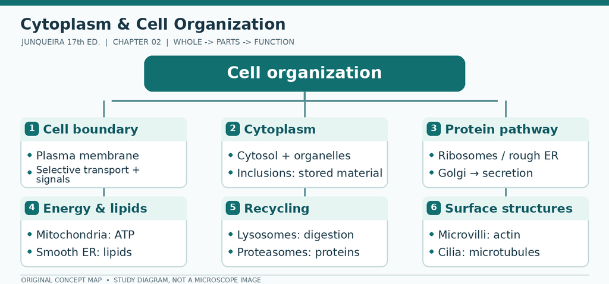

Chapter 2 original concept map: Cell organization; branches for Cell boundary, Cytoplasm, Protein pathway, Energy & lipids, Recycling, Surface structures

**Two pathways to remember**

- **Composition:** Cell → plasma membrane + cytoplasm + genetic compartment (most human cells)
- **Progression:** Secreted protein → rough ER → Golgi → vesicle → cell surface

### Quick notes — understand in 90 seconds

- **Rough ER + ribosomes:** production of secreted and membrane proteins; abundant in plasma cells.
- **Smooth ER:** lipid/steroid metabolism and detoxification; prominent in steroid-secreting cells.
- **Golgi:** protein modification, sorting, and packaging into vesicles.
- **Mitochondria:** ATP generation; concentrated where active transport is intense.
- **Microvilli** have actin cores; most motile cilia have 9+2 axonemes; primary cilia generally have 9+0 doublet axonemes.

**High-yield comparison:** A **basal body** contains nine microtubule **triplets**; a **primary-cilium axoneme** contains nine peripheral **doublets**.

> **MNEMONIC** — Protein export: **rough ER → Golgi → secretory vesicle**.

**Recall without looking:** A cell makes large amounts of peptide hormone. Which two organelles should be conspicuous?

### Learning objectives

By the end of this chapter you should be able to:

1. Describe each membrane-bound organelle and match it to the cell type that needs it most.
2. Explain how proteins are sorted from ribosome to final destination.
3. Distinguish the three cytoskeletal systems by subunit, diameter, and motor protein.
4. Predict the ultrastructure of a cell from its function (steroid synthesis, protein export, phagocytosis, movement).

### The core idea

A cell is a compartmentalization machine. Each organelle is a membrane-bound solution to a specific logistics problem: making protein, making lipid, generating ATP, degrading waste, or moving cargo. Learn the *job*, and the morphology follows automatically.

### Cell Differentiation

The chapter opens with differentiation, because it explains why one genome produces hundreds of cell shapes. Cells become specialized by **differential gene expression** — the same DNA, different genes switched on. Differentiation is accompanied by changes in the amount and type of organelles, which is exactly what you recognize down a microscope: an erythroblast loses its nucleus, a plasma cell fills with rough ER, a muscle cell fills with contractile filaments.

**Stem cells** retain the capacity to self-renew and produce differentiated progeny. They can undergo **asymmetric division** (one daughter retains stem-cell identity and one differentiates) or **symmetric division** (expanding or reducing the stem-cell pool according to context). The balance helps regulate tissue renewal in the gut, epidermis, and bone marrow (Chapter 3).

### The Plasma Membrane

A **7.5–10 nm phospholipid bilayer** with embedded proteins — the **fluid mosaic model**. Amphipathic phospholipids form the bilayer spontaneously; cholesterol modulates fluidity; glycolipids and glycoproteins project outward as the **glycocalyx**, which mediates cell recognition, adhesion, and immune identity.

| Protein class | Position | Function |
| --- | --- | --- |
| **Integral (transmembrane)** | Span the bilayer | Channels, pumps, receptors, adhesion |
| **Peripheral** | Attached to one face | Signaling, cytoskeletal anchoring, enzymes |

**Lipid rafts** are cholesterol- and sphingolipid-enriched microdomains that concentrate signaling molecules. **Caveolae** are small flask-shaped invaginations involved in uptake and signaling.

**Transport across the membrane**

- **Simple diffusion** — small, non-polar molecules down a gradient.
- **Osmosis** — water movement through the bilayer and aquaporins.
- **Facilitated diffusion** — carrier or channel, down the gradient, no energy.
- **Active transport** — against the gradient, ATP-dependent. The **Na⁺/K⁺-ATPase** exchanges 3 Na⁺ out for 2 K⁺ in and consumes a large fraction of the cell’s resting energy budget.
- **Endocytosis** — **phagocytosis** (large particles, actin-driven), **pinocytosis** (fluid), **receptor-mediated endocytosis** (clathrin-coated pits; the classic example is LDL uptake, and its failure causes familial hypercholesterolemia).
- **Exocytosis** — vesicle fusion with the plasma membrane; requires SNARE proteins and calcium.
- **Transcytosis** — endocytosis on one face plus exocytosis on the other; used by endothelial cells and antibodies crossing epithelia.

### Cytoplasmic Organelles

**Mitochondria.** Double membrane; the inner membrane folds into **cristae** carrying the electron transport chain and ATP synthase. The matrix contains circular mitochondrial DNA, mitochondrial ribosomes, and calcium granules. Mitochondria are **maternally inherited** and semi-autonomous. Cells with huge energy demand (cardiac muscle, brown fat, proximal tubule, sperm midpiece) are packed with them. **Cells that synthesize steroid hormone have mitochondria with tubular rather than lamellar cristae**, a reliable ultrastructural marker.

**Ribosomes.** 15–20 nm particles of rRNA plus protein, made of a large and small subunit. Free ribosomes make cytosolic protein for internal use; ribosomes bound to the rough ER make protein for secretion, membranes, or lysosomes. **Polyribosomes (polysomes)** are strings of ribosomes on one mRNA, and a **polyribosome** is the functional unit of translation.

**Endoplasmic reticulum (ER).** An anastomosing network of intercommunicating channels and cisternae, continuous with the outer nuclear membrane. **Rough ER (RER)** — flattened cisternae studded with ribosomes. Sites of synthesis of secretory proteins, integral membrane proteins, and lysosomal enzymes. It is the structure responsible for **basophilia** — and in neurons, stacked RER plus polysomes form the **Nissl bodies**.

**Smooth ER (SER)** — tubular and ribosome-free. Three jobs: **lipid and steroid synthesis**, **detoxification** (hepatic cytochrome P450), and **calcium storage** (sarcoplasmic reticulum of muscle). Hepatocytes, adrenal cortical cells, Leydig cells, and the corpus luteum are rich in SER — which is why steroid-secreting cells look pale and foamy rather than blue.

**Golgi apparatus.** A stack of 4–8 flattened cisternae with a **cis (forming) face** that receives vesicles from the ER and a **trans (maturing) face** that releases vesicles. Vesicles leave the ER in **COPII**-coated vesicles and fuse with the cis face; retrograde transport back to the ER uses **COPI**-coated vesicles. Functions: modification (glycosylation, sulfation, phosphorylation), sorting, and packaging. The **trans-Golgi network** is the dispatch center routing proteins to secretory granules, lysosomes, or the membrane. Cells specialized for secretion (plasma cells, pancreatic acinar cells, goblet cells) have an obvious, often supra-nuclear Golgi.

**Lysosomes.** 0.05–0.5 µm vesicles of acid hydrolases at pH ≈ 5 maintained by a proton pump. **Primary lysosomes** are newly formed; **secondary lysosomes** are the product of fusion with a phagosome or autophagosome; **residual bodies** remain after digestion and accumulate as **lipofuscin**, the “wear-and-tear” pigment of long-lived cells such as cardiac myocytes and neurons.

**Peroxisomes.** Small, membrane-bound oxidative organelles containing **catalase** and oxidases. They perform β-oxidation of very long-chain fatty acids, detoxify ethanol, and destroy H₂O₂.

**Proteasomes.** Cytosolic barrel-shaped complexes that degrade ubiquitin-tagged proteins.

### The Cytoskeleton

| Element | Diameter | Protein | Main roles |
| --- | --- | --- | --- |
| **Microfilament** | 6–8 nm | **Actin** | Microvilli core, cell cortex, stress fibers, cleavage furrow, muscle contraction |
| **Intermediate filament** | 10 nm | **Keratin, vimentin, desmin, GFAP, neurofilament, lamin** | Mechanical strength; tissue-specific identity |
| **Microtubule** | 25 nm | **Tubulin (α/β dimer)** | Spindle, cilia and flagella, intracellular transport |

**Intermediate filaments are the histologist’s best friend**, because each cell type keeps its own: **keratin** in epithelium, **vimentin** in mesenchyme, **desmin** in muscle, **GFAP** in astrocytes, **neurofilament** in neurons, **lamins** in the nucleus. This is why immunohistochemistry can identify the origin of a tumor that looks undifferentiated.

**Microtubules are polar.** **Kinesin** walks cargo toward the plus end (anterograde, away from the cell body); **dynein** walks toward the minus end (retrograde, back to the cell body). Rabies and herpes viruses exploit dynein to travel to the neuronal soma.

**Motile cilia** in respiratory and many other epithelia generally contain a **9 + 2** axoneme (nine peripheral microtubule doublets and a central pair); dynein drives their beating. Most **primary cilia** are instead nonmotile **9 + 0** sensory organelles (nine peripheral doublets without a central pair). The anchoring **basal body** has **nine microtubule triplets**, like a centriole, rather than the same doublet organization as the axoneme. Specialized exceptions include motile 9 + 0 nodal cilia. Dynein defects cause some cases of **primary ciliary dyskinesia**; Kartagener syndrome (situs inversus, bronchiectasis, chronic sinusitis) is a classic, but not universal, presentation.

### Inclusions

Non-membranous accumulations of metabolites or pigments: **glycogen** (PAS-positive, liver and muscle), **lipid droplets** (Sudan-positive), **melanin**, **lipofuscin**, **hemosiderin**, and crystals.

> **CLINICAL** — Lysosomal storage diseases are the direct consequence of a missing acid hydrolase. In **Tay–Sachs disease** hexosaminidase A is absent, so GM2 ganglioside accumulates in neurons, producing developmental regression, a cherry-red macular spot, and death in early childhood. In **I-cell disease** the enzyme that tags hydrolases with mannose-6-phosphate is defective, so the enzymes are secreted instead of delivered to lysosomes.

> **MICRO** — Learn to read a cell’s job from its EM. Abundant RER and a large Golgi = protein secretion. Abundant SER and lipid droplets, mitochondria with tubular cristae = steroid secretion. Many mitochondria and few other organelles = energy transduction. Numerous lysosomes and residual bodies = phagocytosis or long life. Bundles of filaments = mechanical work.

> **MNEMONIC** — **“Keratins Keep Epithelium; Vimentin is Versatile mesenchyme; Desmin Does muscle; GFAP Glues astrocytes; Neurofilaments are Neuronal.”**

> **TIP** — Keep two distinctions straight. The Golgi **modifies and sorts** proteins; the RER makes them. The mitochondrion generates ATP; the lysosome degrades material.

### Chapter 2 — summary

- Rough ER makes membrane and secretory proteins; smooth ER makes lipids and steroids and detoxifies.
- The Golgi is polarized: cis face receives, medial cisternae modify, trans face sorts and packages.
- Mitochondria have outer and inner membranes; cristae shape reflects the cell’s energy demand.
- The peroxisome contains catalase and performs β-oxidation of very long-chain fatty acids.
- The lysosome is the acid hydrolase compartment; its failure produces storage diseases.
- Microtubules are 25 nm, actin filaments 7 nm, intermediate filaments 10 nm.
- Kinesin walks toward the microtubule plus end (anterograde); dynein toward the minus end (retrograde).
- Most motile epithelial cilia have a 9 + 2 axoneme; primary sensory cilia usually have a 9 + 0 axoneme; basal bodies contain nine microtubule triplets. Microvilli have an actin core.

### Active recall

1. **Rough versus smooth ER — what distinguishes them functionally?** — Rough ER carries ribosomes and makes membrane and secretory proteins; smooth ER makes lipids and steroids and detoxifies.
2. **Why is the Golgi described as polarized?** — Cis face receives, medial cisternae modify, trans face packages and sorts.
3. **Which organelle contains catalase, and what does it do?** — The peroxisome; catalase breaks down hydrogen peroxide, and peroxisomes also perform β-oxidation of very long-chain fatty acids.
4. **Which cytoskeletal element forms the mitotic spindle, and which motor walks toward its plus end?** — Microtubules; kinesin moves toward the plus end (anterograde), dynein toward the minus end (retrograde).
5. **What ultrastructural feature identifies a cell that secretes steroid hormone?** — Abundant smooth ER and lipid droplets, with mitochondria that have tubular cristae.

### Exam-style question

**A cell in the adrenal cortex is examined by electron microscopy. Which combination of features is most consistent with its function?**

A. Abundant rough ER and apical zymogen granules  
B. Abundant smooth ER, lipid droplets, and tubular mitochondrial cristae  
C. Numerous lysosomes and residual bodies  
D. Dense arrays of actin filaments and desmosomes

**Answer: B** — Steroid synthesis requires cholesterol (stored as lipid droplets), smooth ER for the enzymatic steps, and mitochondria with tubular cristae.

### Practical identification

On an electron micrograph, identify the plasma membrane, rough ER (parallel cisternae bearing ribosomes), smooth ER (tubules without ribosomes), Golgi (stacked flattened cisternae with vesicles), mitochondria (double membrane and cristae), lysosomes (dense bodies) and inclusions (glycogen rosettes, lipid droplets, pigment).

On H&E, ribosome-rich cytoplasm is basophilic; many protein-rich regions are eosinophilic.

## 3 · The Nucleus

**SPECIALTY EXAM:** `INTERNAL MEDICINE` · `SURGERY`

**In this chapter:** Components of the Nucleus · The Cell Cycle · Mitosis · Stem Cells & Tissue Renewal · Meiosis · Apoptosis

### Chapter mind map — see the whole first

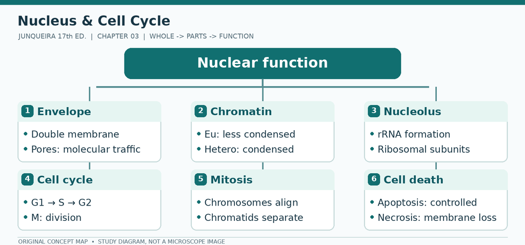

Chapter 3 original concept map: Nuclear function; branches for Envelope, Chromatin, Nucleolus, Cell cycle, Mitosis, Cell death

**Two pathways to remember**

- **Composition:** Nucleus → envelope + chromatin + nucleolus
- **Progression:** Cell cycle → G1 → S (DNA copied) → G2 → M (segregation)

### Quick notes — understand in 90 seconds

- **Euchromatin:** less condensed, commonly transcriptionally active; **heterochromatin:** condensed and often less active.
- **Nucleolus:** ribosomal RNA transcription and assembly of ribosomal subunits.
- **S phase:** DNA replication; **M phase:** chromosome segregation and cell division.
- **Mitosis:** produces genetically similar somatic daughter cells; **meiosis:** reduces chromosome number in germ cells.
- **Apoptosis:** organized cell death with relatively limited inflammation; **necrosis:** membrane damage often with inflammation.

**High-yield comparison:** A highly basophilic nucleus need not be dividing; inspect chromatin, nucleolus and mitotic figures separately.

> **MNEMONIC** — DNA is **copied in S**; chromatids **separate in M**.

**Recall without looking:** Which two features help distinguish apoptosis from necrosis?

### Learning objectives

By the end of this chapter you should be able to:

1. Describe the nuclear envelope, lamina, and pore complex as a selective transport system.
2. Explain how DNA is packaged into nucleosomes, chromatin, and chromosomes.
3. Sequence the cell cycle and name the checkpoints that guard it.
4. Contrast mitosis, meiosis, and apoptosis, and explain what goes wrong when each fails.

### The core idea

The nucleus stores the genome, transcribes it, and duplicates it before division. Its morphology is a readout of transcriptional activity: **dark, condensed chromatin means silent genes; pale, dispersed chromatin means active genes.**

### Components of the Nucleus

**Nuclear envelope.** Two membranes separated by a **perinuclear cisterna**, continuous with the rough ER. Beneath the inner membrane lies the **nuclear lamina**, a meshwork of **lamins A, B, and C** that supports the envelope and organizes chromatin. **Mutations in lamin A cause Hutchinson–Gilford progeria.**

**Centrosomes.** Most typical cycling animal cells possess a **centrosome** containing a pair of **centrioles**, each assembled from nine microtubule triplets, and surrounding pericentriolar material. Centrosomes organize spindle microtubules; centrioles can become the **basal bodies** of cilia. This is not universal: mature human erythrocytes lack a centrosome, and differentiated cell types vary in centrosome organization.

**Nuclear pores.** 3,000–4,000 per nucleus. Each is a **nuclear pore complex** about 100 nm wide, built from roughly 34 nucleoporins, and can pass up to about 1,000 macromolecules per second. Small molecules diffuse; proteins and RNA require **importins and exportins** and a Ran-GTP gradient.

**Chromatin.** Each human cell holds about **2 meters of DNA — 3.2 billion base pairs** — which must be packaged into a nucleus a few micrometers across. The DNA wraps around a core of **eight histones** (two copies each of H2A, H2B, H3, H4) with **about 150 bp of DNA per nucleosome** (about 1.65 turns around the octamer), plus a larger **H1** histone on the outside: that unit is the **nucleosome**, which in EM looks like **10-nm beads on a string**. Further folding into 30-nm fibers and beyond involves nonhistone scaffold proteins and is less well understood. **Heterochromatin** is condensed and transcriptionally inactive; **euchromatin** is dispersed and active. **Constitutive** heterochromatin is permanently silent; **facultative** heterochromatin can be reactivated. The **Barr body** is a facultatively heterochromatic, inactivated X chromosome — one per somatic cell in a female.

**Nucleolus.** Not membrane-bound; a factory for ribosomal subunits, with a **pars fibrosa** (rRNA transcription) and a **pars granulosa** (ribosome assembly), organized around **nucleolar organizer regions** on the acrocentric chromosomes **13, 14, 15, 21, and 22**. Cells that make large amounts of protein have prominent nucleoli, and malignant cells often do too.

### The Cell Cycle

| Phase | What happens | Duration (typical cycling cell) |
| --- | --- | --- |
| **G1** | Cell grows, checks nutrients and DNA integrity; restriction point | ~10 h |
| **S** | DNA replication; histones synthesized | ~8 h |
| **G2** | Repair check, prepare for mitosis | ~4 h |
| **M** | Mitosis and cytokinesis | ~1 h |

The durations above are typical of a **rapidly dividing cultured cell**; most adult tissues cycle far more slowly or not at all, so do not transplant these numbers to the body. Progression is driven by **cyclin–CDK complexes**. **p53** halts the cycle at G1 to allow repair and triggers apoptosis if repair fails — hence “guardian of the genome” — and it is mutated in about half of human cancers. **Rb** is the G1/S brake lost in retinoblastoma. **G0** is the quiescent state of cells that have left the cycle.

### Mitosis

- **Prophase** — chromosomes condense, centrioles move to opposite poles, the nuclear envelope begins to break down.
- **Metaphase** — chromosomes align at the equatorial plate; the spindle attaches to kinetochores.
- **Anaphase** — sister chromatids separate and are pulled poleward.
- **Telophase** — nuclear envelopes re-form, chromosomes decondense.
- **Cytokinesis** — an **actin** contractile ring pinches the cell in two.

### Stem Cells & Tissue Renewal

- **Totipotent** — can form the whole organism (zygote, early blastomeres).
- **Pluripotent** — can form all three germ layers (inner cell mass; embryonic stem cells; induced pluripotent stem cells reprogrammed with the Yamanaka factors Oct4, Sox2, Klf4, c-Myc).
- **Multipotent** — form a restricted set of cell types (hematopoietic stem cell).
- **Unipotent** — one cell type.

Tissues are **labile** (continuous turnover — epidermis, gut, marrow), **stable** (low turnover, can be triggered — liver, kidney, fibroblasts), or **permanent** (most neurons, cardiac myocytes, lens fibers), with little or no regenerative capacity under normal conditions.

### Meiosis

Two divisions produce **four haploid cells** from one diploid cell, with **crossing over** between homologous chromosomes during **pachytene of prophase I**, held together by the **synaptonemal complex**. Meiosis generates genetic diversity and halves the chromosome number; **non-disjunction** produces aneuploid gametes, the mechanism behind trisomy 21.

### Apoptosis

Programmed cell death: **caspases** are activated, **cytochrome c** escapes mitochondria, the **Bcl-2 family** decides survival versus death, chromatin condenses, the cell shrinks and buds into **apoptotic bodies** that are phagocytosed **without inflammation**.

| Feature | Apoptosis | Necrosis |
| --- | --- | --- |
| Trigger | Physiological or programmed | Injury, ischemia, toxin |
| Energy | ATP-dependent | Passive |
| Cell size | Shrinks | Swells |
| Nucleus | Condenses, fragments | Pyknosis, karyorrhexis, karyolysis |
| Membrane | Intact, blebbing | Ruptures |
| Inflammation | **Absent** | **Present** |
| Spread | Single cells | Contiguous sheets |

The contrast is a teaching simplification. **Necroptosis** and **pyroptosis** are regulated lytic deaths, and apoptotic cells that are not cleared promptly can provoke inflammation, so the presence or absence of inflammation is a strong rule of thumb rather than an absolute distinction.

> **CLINICAL** — **Lamin A mutation** causes progeria with premature aging. Changes in nuclear shape and chromatin texture are also one of the oldest cancer-screening tools: the irregular, hyperchromatic nucleus of a dysplastic cervical cell is what a Pap smear is looking for.

> **MICRO** — An active cell has a pale nucleus with a prominent, reticulated nucleolus and lots of euchromatin. A quiescent cell — a small lymphocyte, a spermatozoon, a superficial keratinocyte — has dense heterochromatin and little visible nucleolus. **Nuclear texture is a functional readout.**

> **TIP** — **One Barr body** in a normal female somatic cell, **zero** in a male, one in Klinefelter syndrome (47, XXY), none in Turner syndrome (45, X). Count Barr bodies and you have counted X chromosomes minus one.

### Chapter 3 — summary

- Nuclear lamina = lamins; lamin A mutation = progeria.
- Nuclear envelope = two membranes + perinuclear cisterna, continuous with rough ER.
- Nuclear pores = 3,000–4,000 per nucleus; importins and exportins, Ran-GTP gradient.
- Nucleosome = eight histones + about 150 bp of DNA; H1 sits outside; 10-nm beads on a string.
- Heterochromatin = condensed and silent; euchromatin = dispersed and active.
- Barr body = facultative heterochromatin of one inactivated X chromosome.
- Nucleolus = rRNA synthesis and ribosome assembly; NORs on 13, 14, 15, 21, 22.
- Cell cycle = G1 → S → G2 → M; DNA replicates in S.
- Cyclin–CDK complexes drive the cycle; p53 arrests at G1; Rb is the G1/S brake.
- p53 = G1 checkpoint and apoptosis; mutated in about half of human cancers.
- Mitosis order = prophase, metaphase, anaphase, telophase; actin ring divides the cell.
- Meiosis = four haploid cells, crossing over in pachytene, held by the synaptonemal complex.
- Non-disjunction = aneuploid gametes, the mechanism of trisomy 21.
- Apoptosis = caspases, cytochrome c, Bcl-2 family, apoptotic bodies, no inflammation.
- Necrosis = swelling, membrane rupture, inflammation.
- Labile tissue turns over constantly; stable tissue can be triggered; permanent tissue has little or no regenerative capacity.

### Active recall

1. **What is a nucleosome?** — About 150 bp of DNA wrapped around an octamer of histones (two each of H2A, H2B, H3, H4), with H1 on the outside.
2. **Heterochromatin versus euchromatin?** — Heterochromatin is condensed and transcriptionally silent; euchromatin is dispersed and active.
3. **What is a Barr body?** — The facultatively heterochromatic, inactivated X chromosome in a female somatic cell.
4. **Which checkpoint does p53 guard, and what happens if repair fails?** — The G1 checkpoint; p53 triggers apoptosis if the DNA cannot be repaired.
5. **Name two ways apoptosis differs from necrosis.** — Apoptosis is ATP-dependent, shrinks the cell, keeps the membrane intact, and causes no inflammation; necrosis is classically passive — it swells and ruptures the cell and inflames the tissue — although regulated lytic deaths such as necroptosis blur the boundary.

### Exam-style question

**A cell is blocked in metaphase with colchicine. Its chromosomes number 46. Which statement is correct?**

A. It is a haploid gamete  
B. It is a diploid somatic or pre-meiotic germ cell  
C. It has completed meiosis II  
D. It is an anucleate cell

**Answer: B** — Colchicine arrests cells in metaphase, when sister chromatids are still attached; a count of 46 means diploid. Haploid cells would show 23.

### Practical identification

Find a cell with a large, pale nucleus and a prominent nucleolus, such as a neuron or a plasma cell, and contrast it with a small lymphocyte, whose dense nucleus almost fills the cell. Identify mitotic figures by their condensed chromosomes and absent nuclear envelope, and distinguish them from apoptotic bodies, which are fragmented, membrane-bound and lack a spindle.

In a buccal smear from a female, look for the Barr body at the nuclear margin.

# PART II — THE FOUR BASIC TISSUES

## 4 · Epithelial Tissue

**SPECIALTY EXAM:** `INTERNAL MEDICINE` · `SURGERY`

**In this chapter:** Characteristic Features of Epithelial Cells · Specializations of the Apical Cell Surface · Types of Epithelia · Transport Across Epithelia · Renewal of Epithelial Cells

### Chapter mind map — see the whole first

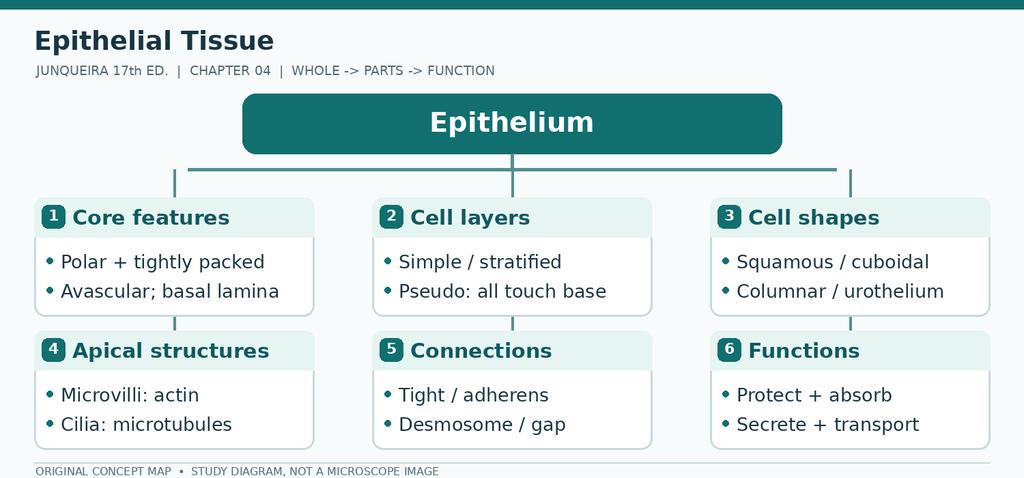

Chapter 4 original concept map: Epithelium; branches for Core features, Cell layers, Cell shapes, Apical structures, Connections, Functions

**Two pathways to remember**

- **Composition:** Epithelium → layer count + surface cell shape → specific type
- **Progression:** Apical specializations → microvillus (actin) / motile cilium (9+2) / primary cilium (usually 9+0)

### Quick notes — understand in 90 seconds

- **Epithelium:** closely packed polarized cells on a basal lamina; usually avascular.
- Classify by **number of layers** and **shape of the surface cells**.
- **Simple squamous:** diffusion and filtration; **stratified squamous:** protection against abrasion.
- **Pseudostratified:** nuclei at different heights but **every cell contacts the basal lamina**.
- **Microvilli:** actin-based absorption; **motile cilia:** microtubule-based surface transport.
- **Urothelium:** distensible urinary lining with specialized umbrella cells.

**High-yield comparison:** **Pseudostratified ≠ stratified.** Nuclei at different heights do not prove several true cell layers.

> **MNEMONIC** — Start at the **free surface**, then trace cells toward the **basal lamina**.

**Recall without looking:** A ciliated respiratory lining appears multilayered. Which observation proves it is pseudostratified?

**Visual anchor — simplified schematic:**

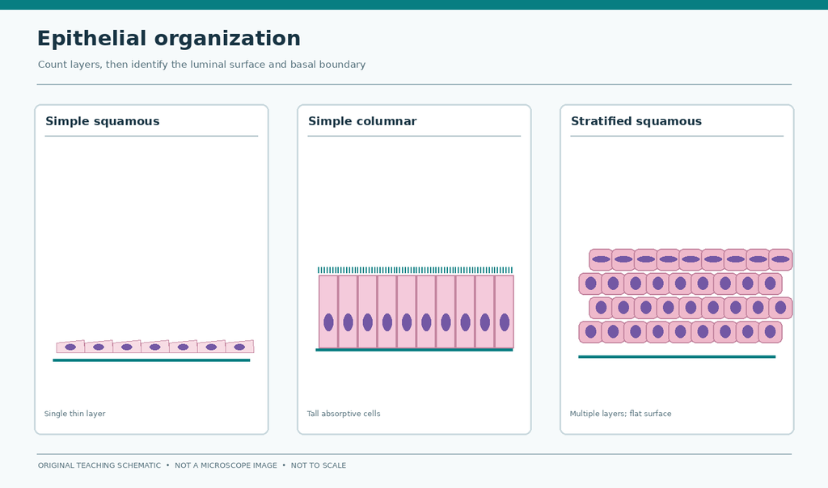

Original schematic comparing epithelial layers

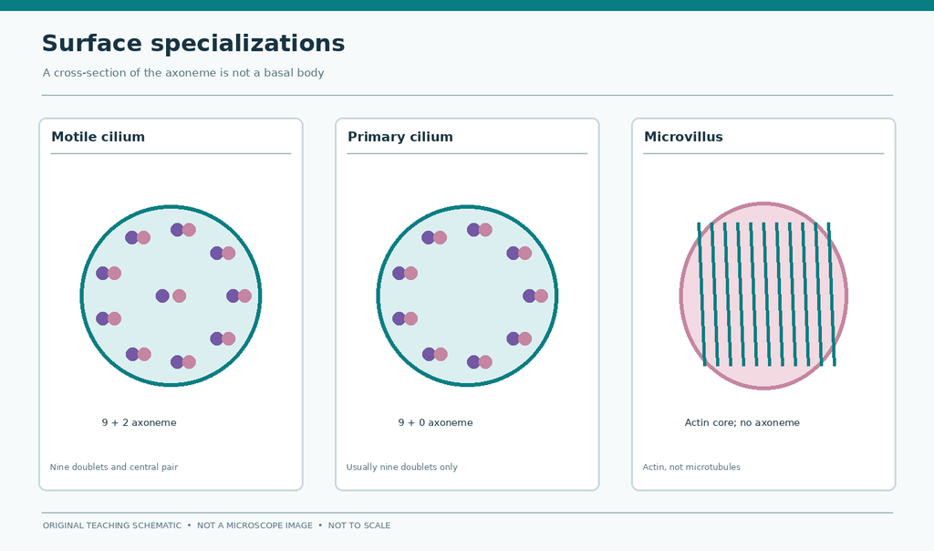

Original schematic comparing motile and sensory cilia with microvilli

### Learning objectives

By the end of this chapter you should be able to:

1. Classify any epithelium by the number of layers and the shape of its surface cells.
2. Match each junctional complex to its molecular components and its function.
3. Explain how microvilli, stereocilia, and cilia differ in structure and purpose.
4. Predict where a given epithelium will be found from the mechanical or transport job it must do.

### The core idea

Epithelial tissues are composed of closely aggregated polyhedral cells adhering strongly to one another and to a thin layer of ECM, forming cellular sheets that line the cavities of organs and cover the body surface. Epithelia (Gr. *epi*, upon + *thele*, nipple) line all external and internal surfaces of the body, and **many exchanges between an organ and its environment occur across epithelial barriers**.

Everything else — the number of layers, the shape of the cells, the specializations on the apex — is a solution to one of four problems: **protection, absorption, secretion, or transport**.

**The four basic tissues** (the framework for the whole subject):

| Tissue | Cells | Extracellular matrix | Main functions |
| --- | --- | --- | --- |
| **Epithelial** | Aggregated polyhedral cells | **Small amount** | Lining of surface or body cavities; glandular secretion |
| **Connective** | Several types of fixed and wandering cells | **Abundant amount** | Support and protection of tissues/organs |
| **Muscle** | Elongated contractile cells | Moderate amount | Strong contraction; body movements |
| **Nervous** | Elongated cells with extremely fine processes | **Very small amount** | Transmission of nerve impulses |

Most organs are divided into the **parenchyma** — the cells responsible for the organ’s specialized functions — and the **stroma**, which plays a supporting role. **In most organs, stroma includes supporting connective tissue and vessels.** The brain and spinal cord have specialized neural supporting tissue (notably glia) and also contain connective tissue associated with blood vessels and coverings.

### Characteristic Features of Epithelial Cells

The principal functions of epithelial tissues are **covering, lining, and protecting surfaces** (eg, epidermis), **absorption** (eg, the intestinal lining), and **secretion** (eg, parenchymal cells of glands). Specific cells of certain epithelia may be contractile (**myoepithelial cells**) or specialized sensory cells, such as those of taste buds or the olfactory epithelium.

Cell shape and nuclear shape correspond: **columnar** cells have elongated nuclei, **squamous** cells flattened nuclei, and **cuboidal or pyramidal** cells spherical nuclei. This is the fastest identification rule in the whole subject.

The defining features:

1. Cells are closely apposed with minimal intercellular space.
2. There is a **free (apical) surface** facing air, a lumen, or a cavity.
3. Cells rest on a **basement membrane**.
4. The tissue is **avascular** — nourishment arrives by diffusion from vessels in the underlying connective tissue.
5. Cells are **polarized**: apical, lateral, and basal domains differ in structure and function.

**The basement membrane** is often demonstrated by PAS or silver staining. Electron microscopy identifies a basal lamina, usually described by its lamina densa and sometimes an electron-lucent zone; the classical lamina lucida can be influenced by preparation. An associated reticular lamina is not uniformly present beneath every epithelium:

| Layer | Composition | Made by |
| --- | --- | --- |
| **Lamina lucida** (classical EM description) | Zone adjacent to the cell membrane; its appearance depends partly on preparation | Primarily epithelial contributions |
| **Lamina densa** | **Type IV collagen**, heparan sulfate proteoglycan | Epithelial cells |
| **Lamina reticularis** | **Type III (reticular) collagen** | Fibroblasts of underlying connective tissue |

**Cell junctions**

| Junction | Transmembrane protein | Cytoskeletal link | Function |
| --- | --- | --- | --- |
| **Tight junction** (zonula occludens) | Claudins, occludins | Actin | Seals the intercellular space; creates the **blood–brain barrier** and apical/basal polarity |
| **Adherent junction** (zonula adherens) | **E-cadherin** (Ca²⁺-dependent) | Actin | Mechanical adhesion; the belt that holds sheets together |
| **Desmosome** (macula adherens) | **Desmoglein, desmocollin** | **Keratin** | Spot-welds resisting shear; autoantibodies cause **pemphigus vulgaris** |
| **Gap junction** (nexus) | **Connexins** | None | Direct cytoplasmic communication |
| **Hemidesmosome** | **Integrins** | Keratin → laminin | Anchors basal cells; antibodies cause **bullous pemphigoid** |

The pattern is worth memorizing: **tight seals, adherens belts to actin, desmosomes to keratin, gap junctions for talk, hemidesmosomes for feet.**

### A Practical Approach to Epithelial Identification

Epithelial classification becomes reliable when three separate observations are recorded: **layering**, **shape of the luminal cells**, and **apical or basal specialization**. Begin at the free surface, then trace individual cells toward the basement membrane. A tangential cut may make a simple epithelium appear stratified, while nuclei at different heights in pseudostratified epithelium do not imply that every cell fails to reach the basal lamina.

| Observation | Interpretation | Common pitfall |
| --- | --- | --- |
| One layer of very flat cells | Simple squamous epithelium, as in endothelium or alveolar lining | Thin cytoplasm may be almost invisible on H&E |
| One layer of cells about as tall as wide | Simple cuboidal epithelium, common in small ducts and tubules | An oblique section changes apparent cell height |
| One layer of tall cells | Simple columnar epithelium, often absorptive or secretory | Goblet cells and cilia are not present at every site |
| Nuclei at different heights, cells sharing the basal lamina | Pseudostratified epithelium | It is functionally one epithelial layer, not truly multilayered |
| Several layers with flattened surface cells | Stratified squamous epithelium | Keratinization must be assessed at the surface, not inferred from location |
| Superficial dome-shaped cells, variable thickness with distension | Urothelium | Flattened umbrella cells in a distended specimen may obscure the classic dome shape |

**Decision sequence.** (1) Find the luminal boundary. (2) Determine whether the tissue is genuinely multilayered. (3) Describe the surface cells. (4) Look for cilia, microvilli, keratin, goblet cells or umbrella cells. (5) Use surrounding tissue and organ architecture to confirm the identification.

**Clinical reasoning.** Epithelial metaplasia changes a tissue’s differentiation program, but the new lining is not automatically malignant. Dysplasia describes disordered growth and cytologic atypia; invasive carcinoma requires evidence of invasion through the relevant tissue boundary. Routine histology must be interpreted in clinical context.

**Check your understanding.** A respiratory lining has nuclei at several levels, cilia and mucus-producing cells, yet its cells contact the basal lamina. **Answer:** pseudostratified ciliated columnar epithelium. The critical evidence is basal attachment, not the apparent number of nuclear rows.

### Specializations of the Apical Cell Surface

**Microvilli.** Finger-like extensions with a core of **actin** filaments cross-linked by actin-bundling proteins (villin, fimbrin) and anchored in a **terminal web**. They multiply surface area for absorption. In the proximal tubule and small intestine they form a **brush border** visible as a fuzzy eosinophilic rim. In the epididymis and inner ear, unusually long, stiff microvilli are called **stereocilia** — a misnomer, because they contain no microtubules.

**Cilia.** Conventional **motile epithelial cilia** have a **9 + 2 axoneme** (nine peripheral microtubule doublets plus a central pair, with dynein driving beating). Most **primary sensory cilia** have a **9 + 0 axoneme** (nine peripheral doublets, without a central pair) and act as signaling organelles; defects in ciliary signaling can cause kidney cystic diseases. Both arise from a **basal body formed from a centriole with nine microtubule triplets**. Do not confuse the triplet-based basal body with a 9 + 0 axoneme. Motile 9 + 0 nodal cilia are a specialized exception.

**Basal infoldings.** Deep folds of the basal membrane packed with mitochondria — the “striated” appearance in the ducts of salivary glands and the distal tubule of the kidney. They are the morphological signature of **active ion transport**.

### Types of Epithelia

| Type | Structure | Location | Function |
| --- | --- | --- | --- |
| **Simple squamous** | One flat layer, central nucleus | Alveoli, endothelium, mesothelium, Bowman capsule | Diffusion, filtration, lubrication |
| **Simple cuboidal** | One layer, nuclei round and central | Kidney tubules, small ducts, thyroid follicles, surface of ovary | Secretion, absorption, conduit |
| **Simple columnar** | One layer, tall cells | Stomach, intestine, gallbladder, uterine tube | Absorption, secretion, protection |
| **Pseudostratified ciliated columnar** | Single layer with nuclei at different heights; cilia and goblet cells | Trachea, bronchi, nasal cavity | Mucus clearance (“respiratory epithelium”) |
| **Stratified squamous, keratinized** | Many layers, outermost anucleate keratin | Epidermis | Protection against abrasion and dehydration |
| **Stratified squamous, non-keratinized** | Many layers, outermost live nucleated cells | Oral cavity, esophagus, vagina, anal canal, cornea | Protection in a wet environment |
| **Stratified cuboidal / columnar** | Two or more layers | Ducts of sweat glands, conjunctiva | Conduit with protection |
| **Transitional (urothelium)** | Stratified, with dome-shaped **umbrella cells** whose apical membrane is stiffened by **uroplakin** plaques | Renal pelvis, ureter, bladder, proximal urethra | Stretchable barrier to urine |
| **Epithelioid** | Cells in clusters with no free surface | Adrenal cortex, islets of Langerhans, liver cords | Endocrine secretion |

Two naming traps to avoid. **Endothelium and mesothelium are both simple squamous epithelium** — one lines blood vessels, the other body cavities; they are not separate tissue types. And **pseudostratified** epithelium is truly a **single layer** in which every cell touches the basement membrane, even though the nuclei sit at different levels.

### Transport Across Epithelia

An epithelium that moves material from one side to the other is built like a machine: **entry at the apical face, exit at the basal face**, with the tight junction preventing back-leak and mitochondrial-rich basal infoldings powering the pumps. In the intestinal enterocyte, glucose enters apically via **Na⁺-glucose cotransport (SGLT1)** and exits basolaterally via **GLUT2**; the Na⁺ gradient is maintained by basolateral Na⁺/K⁺-ATPase.

This is **transcellular transport**. **Paracellular** transport passes between cells and is limited by tight junctions.

### Renewal of Epithelial Cells

Epithelia wear out. They are replaced from **stem cells** whose location varies with the tissue: the **basal layer** of stratified squamous epithelium, the **crypt base** of the intestine, the **isthmus** of the gastric gland, and the basal layer of the epidermis. Renewal rate is a diagnostic index: the intestinal epithelium turns over in days, the epidermis in weeks.

Because the stem cells rest on the basement membrane, an epithelium can regenerate completely after superficial injury — but not after the basement membrane itself is destroyed.

### Glands

- **Exocrine** — connected to a surface by a duct. **Endocrine** — ductless, secreting into the blood.
- **Unicellular** — the goblet cell (mucin; empty cup-shaped apex after secretion).
- **Simple** — one unbranched duct (simple tubular = intestinal crypt; simple coiled tubular = eccrine sweat gland; simple branched acinar = sebaceous gland).
- **Compound** — branched duct (salivary glands, pancreas, mammary gland).
- **Mechanism:** **merocrine** (exocytosis — pancreas, sweat glands), **apocrine** (membrane and cytoplasm bud off — the lipid component of mammary secretion), **holocrine** (whole cell disintegrates — sebaceous gland).

**Myoepithelial cells** sit between secretory cells and the basement membrane and contract to expel product — visible in mammary and salivary glands.

> **CLINICAL** — Epithelial junctions are the target of autoimmune blistering. In **pemphigus vulgaris**, antibodies against **desmoglein** break desmosomes, so the epidermis detaches *within* the epithelium and thin-walled blisters form. In **bullous pemphigoid**, antibodies against **hemidesmosomal** antigens split the epidermis from the basement membrane and the blister is thick-walled and tense. The level of the split is dictated by which junction fails.

> **MICRO** — Count layers, not nuclei. If every cell rests on the basement membrane and only the nuclei sit at different heights, the epithelium is **pseudostratified** — tall, ciliated, respiratory. If cells are stacked on one another, it is **stratified**. Then the top layer: **flat and anucleate** = keratinized; **flat with nuclei** = non-keratinized; **dome-shaped and large** = transitional; **tall with cilia** = respiratory.

> **MNEMONIC** — **“Simple for exchange, stratified for stress, transitional for stretch.”** Most motile respiratory cilia have a **9 + 2 axoneme**, while most primary sensory cilia have a **9 + 0 axoneme**. A basal body has **nine triplets**, not axonemal doublets.

> **TIP** — Where is ciliated simple columnar epithelium found? The **uterine tube** — cilia move the ovum — and parts of the respiratory tract, where the epithelium is pseudostratified. Students often wrongly assign all ciliated epithelium to the lung.

### Chapter 4 — summary

- Epithelium sits on a basal lamina, is avascular, and is normally adjacent to connective tissue.
- Simple = one layer (exchange, absorption, secretion); stratified = protection; pseudostratified = all cells touch the basement membrane.
- Squamous = flat; cuboidal = height ≈ width; columnar = height > width.
- Keratinized stratified squamous = dry, abrasive surfaces; nonkeratinized = wet surfaces (mouth, esophagus, vagina).
- Urothelium (transitional) = dome-shaped umbrella cells; stretches.
- Tight junction (zonula occludens) = seal and fence; it creates apical–basal polarity.
- Zonula adherens anchors actin; desmosomes anchor intermediate filaments; gap junctions couple cells.
- Hemidesmosomes attach the basal cell to the basal lamina.
- Basal lamina = lamina lucida + lamina densa (type IV collagen, laminin); the reticular lamina (type III) belongs to connective tissue.
- Microvilli and stereocilia have an actin core; conventional motile epithelial cilia usually have a 9 + 2 axoneme, while most primary sensory cilia have a nonmotile 9 + 0 axoneme.
- Basal bodies anchor cilia and comprise nine microtubule triplets; the 9 + 0 notation describes the usual primary-cilium axoneme, with nine outer doublets.
- Apical specializations serve absorption or movement; basal specializations anchor and receive signals.
- Epithelia renew from stem cells: labile (gut, skin) versus stable (liver, kidney).

### Active recall

1. **How do you classify an epithelium in one pass?** — First count the layers (simple, stratified, pseudostratified), then name the surface cell shape (squamous, cuboidal, columnar).
2. **What does a tight junction do besides sealing?** — It fences membrane proteins, creating and maintaining apical–basal polarity.
3. **Which junction attaches a cell to the basal lamina?** — The hemidesmosome.
4. **Microvillus, stereocilium, cilium — core structure?** — Microvillus and stereocilium: actin-based; most motile epithelial cilia: 9 + 2 axoneme; typical primary cilium: 9 + 0 axoneme; a basal body has nine microtubule triplets.
5. **Why is urothelium suited to the bladder?** — Umbrella cells with uroplakin plaques and tight junctions form an osmotic barrier, and the epithelium thins as the bladder fills.

### Exam-style question

**An epithelium lines a dry, abrasion-prone surface. Which description fits it?**

A. Simple columnar with goblet cells  
B. Stratified squamous keratinized  
C. Simple squamous with fenestrations  
D. Pseudostratified ciliated columnar

**Answer: B** — Keratinized stratified squamous epithelium is the body’s answer to mechanical wear plus water loss (skin, hard palate, gingiva).

### Practical identification

Classify any epithelium with two questions: how many layers, and what shape is the surface cell? Then find the basal lamina, the underlying connective tissue and the apical specialization — microvilli, cilia, stereocilia or keratin. Distinguish pseudostratified from stratified by checking whether every cell reaches the basement membrane.

In a gland, decide whether the secretory unit is serous, mucous or mixed, and whether the duct is intercalated, striated or excretory.

## 5 · Connective Tissue

**SPECIALTY EXAM:** `INTERNAL MEDICINE` · `SURGERY`

**In this chapter:** Cells of Connective Tissue · Fibers · Ground Substance · Types of Connective Tissue

### Chapter mind map — see the whole first

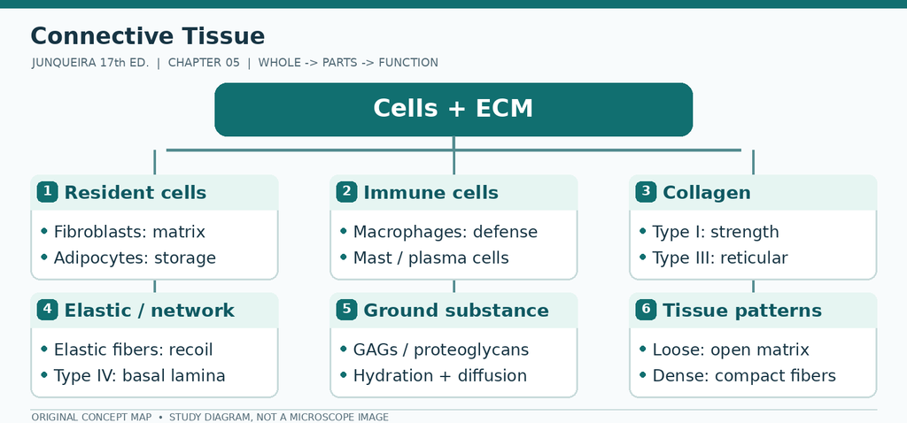

**Two pathways to remember**

- **Composition:** Connective tissue → cells + extracellular matrix → fibers + ground substance
- **Progression:** ECM fibers → collagen (tension) / elastic (recoil) / reticular (support)

### Quick notes — understand in 90 seconds

- **Connective tissue = cells + fibers + ground substance**; unlike epithelium, ECM is abundant.
- **Type I collagen:** tendon, dermis, bone; **type II:** cartilage; **type III:** reticular networks; **type IV:** basal lamina.
- **Fibroblasts** synthesize much of the ECM; **mast cells** contain inflammatory mediators.
- **Plasma cells:** eccentric nucleus, coarse ‘clock-face’ chromatin, perinuclear Golgi zone.
- **Macrophage origin is tissue-dependent**; many resident populations arise from embryonic precursors.

**High-yield comparison:** **Dense regular:** parallel collagen for one-way tension. **Dense irregular:** interwoven collagen for multidirectional resistance.

> **MNEMONIC** — Collagen mnemonic: **I strong; II cartilage; III reticular; IV basement**.

**Recall without looking:** Why do tendon and dermis resist forces in different directions?

### Learning objectives

By the end of this chapter you should be able to:

1. Name the cells, fibers, and ground substance of connective tissue and give each one’s job.
2. Match collagen types I–IV to their locations and to the diseases caused by their failure.
3. Distinguish loose from dense connective tissue, and regular from irregular, by collagen arrangement.
4. Explain how connective tissue repairs and why scurvy and Ehlers–Danlos syndrome look the way they do.

### The core idea

Connective tissue is the tissue whose defining feature is **abundance of extracellular matrix**. The cells are widely separated because the *matrix* — not the cells — does the mechanical work. Name the matrix and you have named the tissue’s job: collagen for tension, elastin for recoil, ground substance for compression and diffusion.

### Cells of Connective Tissue

[output not shown]

### Fibers

| Fiber | Protein | Properties | Where |
| --- | --- | --- | --- |
| **Collagen** | Tropocollagen (types I–XXVIII) | High tensile strength, inelastic | Everywhere; the most abundant protein in the body |
| **Reticular** | **Type III collagen** | Fine, branched; silver-staining | Lymphoid organs, bone marrow, liver, endocrine glands |
| **Elastic** | **Elastin** core + **fibrillin** microfibrils | Stretch and recoil | Aorta, skin, lung, elastic cartilage, ligaments |

| Type | Form | Main location | Disease if defective |
| --- | --- | --- | --- |
| **I** | Thick fibrils | Bone, dermis, tendon, cornea | **Osteogenesis imperfecta** |
| **II** | Fibrils | Hyaline and elastic cartilage, vitreous | Chondrodysplasias |
| **III** | Reticular fibers | Lymph node, spleen, bone marrow, skin | **Ehlers–Danlos vascular type** |
| **IV** | Network | **Basement membrane** | Alport syndrome |
| **V** | Fibrils with type I | Cornea, bone, placenta | Ehlers–Danlos |

**Collagen synthesis in five steps** — a reliable structured-question answer:

1. **Translation** on the RER as preprocollagen.
2. **Hydroxylation** of proline and lysine — **requires vitamin C**.
3. **Glycosylation** in the ER and Golgi.
4. **Procollagen** is secreted and the propeptides cleaved → **tropocollagen**.
5. **Fibril assembly** with cross-links formed by **lysyl oxidase**, which requires **copper**.

This pathway explains two diseases. Without vitamin C, hydroxylation fails and the result is **scurvy** — bleeding gums, poor wound healing, perifollicular hemorrhage. Without copper, cross-linking fails, as in **Menkes disease**. In **Ehlers–Danlos syndrome** the defect is in collagen processing or type; in **Marfan syndrome** the defect is in **fibrillin**, so the aorta dilates and the lens dislocates.

### Ground Substance

An amorphous, hydrated gel of **glycosaminoglycans (GAGs)**, **proteoglycans**, and **glycoproteins**, which resists compression, lubricates, and controls diffusion.

- **GAGs** (also called mucopolysaccharides) are long polymers of repeating disaccharide units, usually with many negative charges that attract water: **hyaluronic acid** (the only **unsulfated** one, not attached to protein, and the backbone of the gel) and the **sulfated GAGs** — chondroitin sulfate, keratan sulfate, dermatan sulfate, and heparan sulfate.
- **Proteoglycans** are a core protein with GAG side chains — the classic is **aggrecan**, a very large molecule with a **250-kDa core protein** heavily bound with chondroitin and keratan sulfate and joined to hyaluronan by a **link protein**. Its water-binding is why cartilage resists compression.
- **Perlecan** is the key proteoglycan of **all basal laminae** — the one name that links ground substance to the basement membrane.
- **Glycoproteins** — **fibronectin** (binds cells to matrix via integrins, important in wound healing) and **laminin** (basement membrane).

### Types of Connective Tissue

- **Loose (areolar)** — abundant ground substance, scattered fibers, many cells. Fills spaces, surrounds vessels, underlies epithelia.
- **Dense irregular** — thick collagen bundles in many directions; dermis, organ capsules. Resists stress from all directions.
- **Dense regular** — parallel collagen bundles; **tendon** and ligament. Resists stress in one direction.
- **Elastic** — many elastic fibers; elastic ligament, vocal cord, large arteries.
- **Reticular** — type III collagen network; lymphoid organs and marrow.
- **Mucous (Wharton’s jelly)** — gelatinous, in the umbilical cord.
- **Embryonic** — mesenchyme.

Besides fibroblasts, the resident population includes **adipocytes**, **macrophages**, mast cells, and the **leukocytes** that migrate in (especially **lymphocytes** and plasma cells in chronic inflammation) — which is why older descriptions divided them into fixed and wandering cells.

**Repair.** Inflammation → **granulation tissue** (proliferating capillaries, fibroblasts, macrophages) → collagen deposition → **scar**. **Primary intention** occurs in clean apposed wounds; **secondary intention** in larger, open wounds with more granulation and contraction.

> **CLINICAL** — **Scurvy** is the purest histology-to-clinic link in the chapter: inadequate hydroxylation produces defective collagen, which produces fragile capillaries (bleeding gums, petechiae) and failed wound healing. **Scleroderma** is the opposite failure — excess collagen in skin and internal organs. **Keloid** is an overgrowth of dense collagen beyond the original wound margin, common in darker skin.

> **MICRO** — **Collagen is pink, wavy, and in bundles; elastin is sparse, often darker, and best shown by orcein.** A plasma cell has an **eccentric clock-face nucleus with a pale perinuclear halo**; a mast cell’s granules stain metachromatically; the eosinophil’s bilobed nucleus is unmistakable.

> **MNEMONIC** — **“1 bone, 2 cartilage, 3 reticulin, 4 basement membrane.”**

> **TIP** — The distinction that matters most here is **dense regular versus dense irregular**, and the answer is one word: **direction**. Regular = parallel = tendon = one axis of force. Irregular = random = dermis = many axes.

### Chapter 5 — summary

- Connective tissue = cells + fibers + ground substance; it is vascular except in cartilage.
- Type I collagen = bone, tendon, dermis, scar. Type II = hyaline and elastic cartilage. Type III = reticulin. Type IV = basal lamina.
- Collagen synthesis needs vitamin C for proline and lysine hydroxylation; deficiency = scurvy.
- Elastic fibers = elastin core + fibrillin microfibrils; orcein stains them.
- Ground substance = GAGs and proteoglycans; **hyaluronan is the only unsulfated GAG**.
- Fibroblast makes collagen; myofibroblast contracts (wound closure).
- Plasma cell = eccentric clock-face nucleus, perinuclear Golgi halo, antibody factory.
- Mast cell = heparin, histamine, proteases; metachromatic granules; IgE receptor.
- Macrophages are phagocytic immune cells that may develop from embryonic tissue-resident precursors or circulating monocytes, depending on the organ; foreign-body and Langhans giant cells form through macrophage-lineage cell fusion.
- Adipocytes, mast cells, and leukocytes are resident connective tissue cells.
- Loose (areolar) tissue = cells and vessels; dense irregular = dermis; dense regular = tendon.
- Reticular tissue = type III collagen framework of lymphoid organs and marrow.
- Edema = excess fluid in ground substance; it follows increased pressure, leaky vessels, or low albumin.

### Active recall

1. **Which collagen type forms the basal lamina?** — Type IV (with laminin), over a reticular lamina of type III.
2. **Which collagen type is defective in osteogenesis imperfecta?** — Type I.
3. **What is the only unsulfated GAG?** — Hyaluronan.
4. **How do you tell dense regular from dense irregular connective tissue?** — Direction: regular has parallel bundles (tendon), irregular has randomly oriented bundles (dermis).
5. **What does a plasma cell look like, and what does it make?** — Eccentric clock-face nucleus with a pale perinuclear Golgi halo; it secretes antibody.

### Exam-style question

**A patient has bleeding gums, poor wound healing, and perifollicular hemorrhages. Which step in collagen synthesis is defective?**

A. Transcription of collagen genes  
B. Hydroxylation of proline and lysine  
C. Cleavage of propeptides  
D. Cross-linking by lysyl oxidase

**Answer: B** — Vitamin C is the cofactor for prolyl and lysyl hydroxylase; without hydroxylation the triple helix is unstable — scurvy.

### Practical identification

Identify the three fiber types by their appearance and staining: collagen bundles (pink with eosin, blue with trichrome), elastic fibers (wavy, refractile, black with orcein) and reticular fibers (fine and argyrophilic). Name the resident cells — fibroblast, macrophage, mast cell with its heparin granules, adipocyte, and plasma cell with its clock-face nucleus — and the ground substance that fills the spaces.

Distinguish loose from dense irregular and dense regular tissue by fiber orientation and cell density.

## 6 · Adipose Tissue

**SPECIALTY EXAM:** `INTERNAL MEDICINE` · `SURGERY`

**In this chapter:** White Adipose Tissue · Brown Adipose Tissue

### Chapter mind map — see the whole first

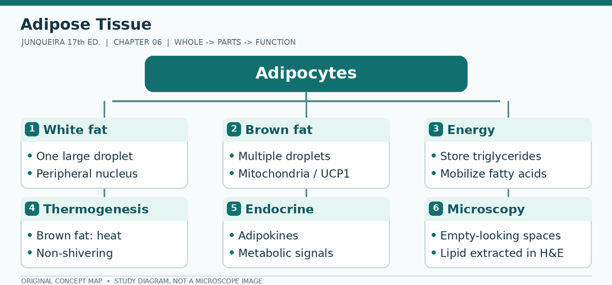

Chapter 6 original concept map: Adipocytes; branches for White fat, Brown fat, Energy, Thermogenesis, Endocrine, Microscopy

**Two pathways to remember**

- **Composition:** Adipose tissue → white (unilocular) + brown (multilocular)
- **Progression:** Brown adipocyte → mitochondria + UCP1 → heat production

### Quick notes — understand in 90 seconds

- **White adipocytes:** one large lipid droplet and a peripheral flattened nucleus.
- **Brown adipocytes:** multiple small droplets and mitochondria rich in UCP1.
- **White fat:** stores energy, cushions organs, secretes metabolic signals.
- **Brown fat:** generates heat through non-shivering thermogenesis.
- Routine paraffin processing extracts lipid, so white adipocytes often look **empty** on H&E.

**High-yield comparison:** **White = unilocular storage** versus **brown = multilocular heat production**.

> **MNEMONIC** — Large clear ring → think **white adipose**; many droplets → think **brown adipose**.

**Recall without looking:** What creates the empty appearance of a white adipocyte in routine H&E?

### Learning objectives

By the end of this chapter you should be able to:

1. Distinguish white and brown adipocytes by light and electron microscopy.
2. Explain how white adipose tissue works as an endocrine organ.
3. Explain the mechanism of non-shivering thermogenesis and where brown fat is found.
4. Relate adipose storage limits to obesity, lipotoxicity, and lipodystrophy.

### The core idea

Adipose tissue is an endocrine and metabolic organ disguised as a filling tissue. White fat stores energy; brown fat burns it for heat. Both are built from the same cell with a completely different internal architecture.

### White Adipose Tissue

**Unilocular.** Each white adipocyte is a very large cell, **50–150 µm** in diameter, containing one enormous lipid droplet that displaces the cytoplasm to a thin rim and flattens the nucleus against the plasmalemma — the **signet-ring** appearance. Adipose tissue is normally **15–20% of body weight in men** and somewhat more in women. The lipid dissolves during routine processing, so on an H&E slide the cell appears as an empty circle with a thin border.

Functions: energy storage, insulation, cushioning of organs (retro-orbital, perirenal, mesenteric), and **endocrine signaling**.

**Where the stored fat comes from — three sources:** dietary fat carried as **chylomicrons**; triglycerides made in the **liver** and carried as **VLDLs**; and fatty acids and glycerol **synthesized by the adipocytes themselves**. Mobilization is by **hormone-sensitive lipase**, activated by **norepinephrine** from the adrenal gland and sympathetic nerves, and by growth hormone; **insulin inhibits** that lipase and stimulates lipid synthesis. The cells are supported by **reticular fibers**, with connective tissue septa dividing the tissue into lobules.

**Adipose-derived factors** — the ones worth knowing (the last is an enzyme, not an adipokine):

- **Leptin** — from adipocytes, acts on the hypothalamus to reduce appetite.
- **Adiponectin** — increases insulin sensitivity; low in obesity.
- **Resistin, TNF-α, IL-6** — pro-inflammatory, part of why obesity is a chronic inflammatory state.
- **Aromatase** — an enzyme, not a cytokine: it converts androgens to estrogens, making adipose tissue a peripheral estrogen source (the reason obesity raises estrogen levels).

### Brown Adipose Tissue

**Multilocular.** Many small lipid droplets, a **central round nucleus**, and — the diagnostic feature — **numerous mitochondria with abundant cristae** containing **uncoupling protein 1 (UCP1, thermogenin)**, which short-circuits the proton gradient so energy is released as heat instead of ATP.

Found in the fetus and newborn (interscapular, axillary, perirenal, along the great vessels), much reduced in adults. Sympathetic innervation drives it. **“Beige” adipocytes** appear within white fat after cold exposure.

| Feature | White | Brown |
| --- | --- | --- |
| Lipid droplets | One (unilocular) | Many (multilocular) |
| Nucleus | Peripheral | Central |
| Mitochondria | Few | **Many, cristae-rich** |
| UCP1 | Absent | **Present** |
| Main role | Energy storage, endocrine | **Non-shivering thermogenesis** |
| Sympathetic innervation | Sparse | Rich |

> **CLINICAL** — In **lipodystrophy** fat is absent or redistributed, and the metabolic consequences are paradoxical: severe insulin resistance with hypertriglyceridemia, because the remaining fat cannot store lipid safely. In **obesity** the same storage limit is approached, so lipid spills into liver (steatosis), muscle, and pancreas — **lipotoxicity**. Brown fat is a therapeutic target: activating it increases energy expenditure, and PET imaging shows active depots in adults.

> **MICRO** — **One big hole per cell with a flattened nucleus at the rim = white. Many small holes with a round central nucleus and granular eosinophilic cytoplasm = brown.**

> **TIP** — Do not confuse adipose tissue with **steatosis**. Adipocytes are a normal tissue with a capsule and vessels; steatosis is lipid accumulating inside hepatocytes or myocytes as vacuoles.

### Chapter 6 — summary

- White adipocyte: **one large lipid droplet**, nucleus flattened at the rim, few mitochondria.
- Brown adipocyte: **many small droplets**, round central nucleus, many cristae-rich mitochondria.
- White fat = energy storage plus an **endocrine organ**: leptin, adiponectin, and other adipokines.
- Brown fat = **non-shivering thermogenesis** through **UCP1**, which uncouples the proton gradient.
- Brown fat is richest in the newborn (neck, back, mediastinum) and persists in adult neck and supraclavicular depots.
- Beige/brite adipocytes are an inducible, brown-like population within white fat.
- Adipose tissue is vascular and innervated; white fat’s sympathetic supply is sparse, brown fat’s is rich.
- Obesity is expansion by hypertrophy and hyperplasia; the storage limit produces lipotoxicity.
- Lipodystrophy = absent or redistributed fat with severe insulin resistance.
- Leptin signals energy stores to the hypothalamus; adiponectin increases insulin sensitivity.

### Active recall

1. **One histological difference between white and brown fat?** — White: one large droplet, peripheral flattened nucleus. Brown: many small droplets, central round nucleus, eosinophilic granular cytoplasm.
2. **What is UCP1 and where does it act?** — Uncoupling protein 1 in the inner mitochondrial membrane; it lets protons leak back without ATP synthesis, releasing heat.
3. **Name two adipokines.** — Leptin (signals stored energy) and adiponectin (increases insulin sensitivity).
4. **When is brown fat most abundant?** — In the newborn (neck, back, mediastinum); it persists in adult neck and supraclavicular depots.
5. **What is lipotoxicity?** — When adipose storage capacity is exceeded, lipid accumulates in liver, muscle, and pancreas, impairing their function.

### Exam-style question

**A newborn’s PET scan shows active supraclavicular fat that burns energy without shivering. Which feature explains this?**

A. Unilocular droplets and few mitochondria  
B. Multilocular droplets, abundant mitochondria, and UCP1  
C. Dense collagen bundles and few cells  
D. Abundant rough ER and zymogen granules

**Answer: B** — Brown adipocytes are built for heat production: many small droplets for rapid lipolysis, cristae-rich mitochondria, and UCP1.

### Practical identification

Distinguish white from brown adipose tissue in a single section. White adipocytes are large, unilocular and appear empty after lipid extraction; brown adipocytes are smaller, multilocular, with central nuclei and eosinophilic cytoplasm packed with mitochondria. Identify the capillary network around brown adipocytes and explain why the two tissues look so different after routine processing, and what a frozen section would add.

## 7 · Cartilage

**SPECIALTY EXAM:** `SURGERY`

**In this chapter:** Hyaline Cartilage · Elastic Cartilage · Fibrocartilage · Cartilage Formation, Growth, & Repair

### Chapter mind map — see the whole first

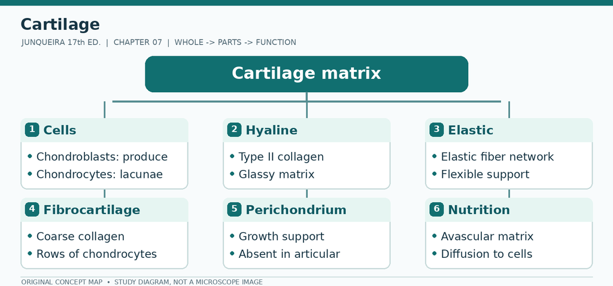

Chapter 7 original concept map: Cartilage matrix; branches for Cells, Hyaline, Elastic, Fibrocartilage, Perichondrium, Nutrition

**Two pathways to remember**

- **Composition:** Cartilage → cells in lacunae + hydrated ECM
- **Progression:** Cartilage types → hyaline / elastic / fibrocartilage

### Quick notes — understand in 90 seconds

- Cartilage has **chondrocytes in lacunae** and a hydrated, largely avascular ECM.
- **Hyaline cartilage:** glassy type II collagen-rich matrix; common in airway supports and articular surfaces.
- **Elastic cartilage:** elastic fiber network; flexible structures such as the external ear.
- **Fibrocartilage:** coarse collagen bundles with rows of chondrocytes; resists tension and compression.
- **Articular cartilage and fibrocartilage** generally lack a perichondrium.

**High-yield comparison:** **Elastic vs hyaline:** look for elastic fibers. **Fibrocartilage vs tendon:** look for chondrocytes inside lacunae.

> **MNEMONIC** — Cartilage: **cells in lacunae + no blood vessels within matrix**.

**Recall without looking:** A sample has rows of chondrocytes between thick collagen bundles. Identify it.

**Visual anchor — simplified schematic:**

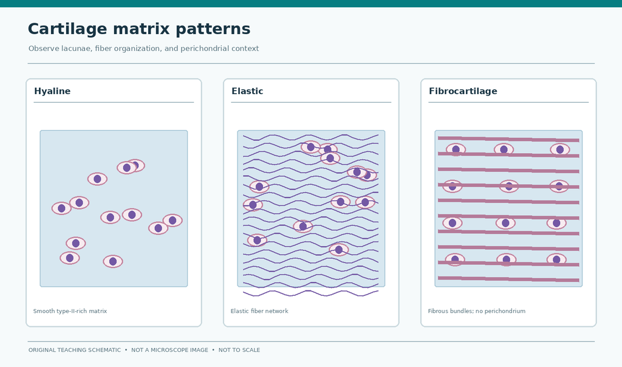

Original schematic showing three types of cartilage

### Learning objectives

By the end of this chapter you should be able to:

1. Distinguish hyaline, elastic, and fibrocartilage by matrix, cells, and perichondrium.
2. Explain why cartilage heals so poorly and what tissue replaces it.
3. Describe appositional and interstitial growth and when each is possible.
4. Identify cartilage types in a micrograph and relate each to its mechanical role.

### The core idea

Cartilage is a **tough, resilient** connective tissue in which the extracellular matrix — collagen, proteoglycans, and water — is the bulk of the tissue; **chondrocytes** occupy only a small fraction of its volume, sitting in lacunae. **Aggrecan** binds a large amount of water, giving the matrix its compressive resilience.

Cartilage supports soft tissues, notably in the respiratory tract, and provides **cushioned, low-friction surfaces in joints**. It is **avascular and aneural** — no blood vessels, lymphatics, or nerves — and is usually surrounded by a vascularized **perichondrium** of dense connective tissue whose fibroblasts form its outer fibrous layer.

Its extracellular matrix provides mechanical resilience; the absence of vessels contributes to its limited capacity for repair.

### The shared architecture

- Cells: **chondroblasts** (immature, at the surface) and **chondrocytes** (mature, in **lacunae**).
- Matrix: **territorial matrix** immediately around the lacuna (rich in proteoglycan, basophilic) and **interterritorial matrix** between cells (more collagen, eosinophilic).
- **Isogenous groups** — clusters of 2–8 chondrocytes from one parent cell, indicating recent **interstitial growth**.
- **Perichondrium** — fibrous outer layer plus chondrogenic inner layer; present on most cartilage, **absent on fibrocartilage and on articular surfaces**.

### Hyaline Cartilage

The commonest type and the template for most of the fetal skeleton. Glassy, homogeneous matrix; **collagen makes up 40% of hyaline cartilage’s dry weight**, all of it embedded in a hydrated gel of proteoglycans and structural glycoproteins, with more proteoglycan and less collagen immediately around the lacunae (the **territorial matrix**).

Perichondrium is present except on **articular surfaces** and the epiphyses of growing long bones, where the cartilage itself forms the smooth, low-friction bearing surface of joints. Found in the **trachea, bronchi, nose, ribs, epiphyseal plate, and articular surfaces**.

### Elastic Cartilage

Type II collagen plus a network of **elastic fibers**, giving flexibility with recoil. Found in the **epiglottis, pinna, external auditory canal, and Eustachian tube** — that is, everywhere something must bend and spring back.

### Fibrocartilage

**Type I and type II collagen** in coarse bundles, with chondrocytes arranged in **parallel rows** between them. **No perichondrium.** Found where compressive and tensile forces meet: **intervertebral disc, symphysis pubis, menisci, temporomandibular joint**. The disc is the perfect example, with an inner **nucleus pulposus** (notochord remnant, rich in hyaluronic acid) and an outer **annulus fibrosus** of concentric fibrocartilage lamellae.

| Feature | **Hyaline** | **Elastic** | **Fibrocartilage** |
| --- | --- | --- | --- |
| Collagen | **Type II** | Type II + **elastic fibers** | **Type I + II** |
| Cells | Isogenous groups | More numerous | **Rows** between bundles |
| Perichondrium | Present (not on articular surfaces) | Present | **Absent** |
| Locations | Trachea, bronchi, nose, ribs, epiphyseal plate, joints | Epiglottis, pinna, auditory canal | Disc, symphysis pubis, menisci |
| Function | Smooth bearing surface, template for bone | Flexible support | Shock absorption, tensile strength |

### Reading Cartilage on a Slide

Cartilage is recognized by **chondrocytes in lacunae** embedded in a substantial extracellular matrix. The presence or absence of a perichondrium helps classification but is not decisive by itself: articular hyaline cartilage lacks one, and fibrocartilage also lacks one.

| Type | Most useful positive clues | Important limitation |
| --- | --- | --- |
| Hyaline | Smooth, glassy-appearing matrix on H&E; rounded chondrocytes, sometimes in isogenous groups | Type II collagen fibers are usually not individually resolved by routine H&E |
| Elastic | Chondrocytes in lacunae and a dense branching elastic-fiber network | Elastic fibers may require a special stain for confident demonstration |
| Fibrocartilage | Rows of chondrocytes between conspicuous eosinophilic collagen bundles | May resemble dense regular connective tissue unless lacunae are found |

**Three-pass exercise.** At low power, locate the cartilage and its boundary. At medium power, search for lacunae and collagen-bundle organization. At higher power, identify chondrocytes and describe whether the matrix is homogeneous or fibrous. Only then choose a cartilage subtype.

**Structure–function question.** Why does the meniscus contain fibrocartilaginous tissue rather than a uniform glassy matrix? **Answer:** its collagen organization helps resist tensile forces while its hydrated matrix participates in load distribution and compression resistance. Mechanical behavior depends on the complete tissue architecture, not a single collagen type.

**Repair question.** Why does a focal articular-cartilage defect often persist? **Answer:** articular cartilage has no direct blood supply and lacks a perichondrium; mature chondrocytes have limited capacity to replace a substantial defect. Repair responses depend on lesion depth and whether subchondral bone is involved.

### Cartilage Formation, Growth, & Repair

- **Appositional growth** — new cartilage added at the periphery by chondroblasts of the perichondrium. Increases width.
- **Interstitial growth** — chondrocytes divide within lacunae and secrete matrix, separating daughter cells. It is prominent during development and in growth plates; some interstitial matrix turnover continues in mature cartilage, although its capacity for growth is limited.

Because cartilage is avascular, nutrition depends on diffusion from the perichondrium or synovial fluid. This limits repair: some defects may fill with **fibrocartilaginous repair tissue**, particularly after procedures that access subchondral bone; many untreated full-thickness articular defects heal poorly or incompletely.

> **CLINICAL** — **Osteoarthritis** is a whole-joint disorder involving cartilage, subchondral bone, synovium and other joint tissues; a central feature is disruption of chondrocyte-mediated matrix maintenance: proteoglycans are depleted, water content rises, collagen fibrils fragment, and the surface fissures. Articular cartilage itself is aneural, so pain arises from innervated structures such as subchondral bone, capsule, ligaments and synovium; pain can occur at different stages and does not correlate perfectly with cartilage loss. **Rheumatoid arthritis** is different: an autoimmune synovitis destroys cartilage from the surface inward, producing a pannus.

> **MICRO** — Identify cartilage by the **lacuna**: a cell alone in a clear space within a solid matrix. Then the matrix: **glassy purple with cells in clusters = hyaline; wavy dark fibers = elastic; thick parallel pink bundles with cells in rows = fibrocartilage.**

> **TIP** — Two commonly confused points: **hyaline cartilage contains type II collagen, not type I**, and **fibrocartilage has no perichondrium**, which is why disc injuries persist.

### Chapter 7 — summary

- Cartilage = chondrocytes in lacunae + solid matrix; no blood vessels, no nerves.
- Hyaline cartilage = **type II collagen** + aggrecan; glassy; perichondrium present except at articular surfaces.
- Elastic cartilage = type II collagen + **elastic fibers**; perichondrium present; epiglottis, auricle, auditory tube.
- Fibrocartilage = **type I + type II collagen**, rows of chondrocytes, **no perichondrium**; discs, menisci, pubic symphysis.
- Territorial matrix surrounds each lacuna; interterritorial matrix lies between groups.
- Isogenous groups = daughter cells from recent division, still in one lacuna.
- Appositional growth = from perichondrium, adds width.
- Interstitial growth = division inside lacunae, adds length, young cartilage only.
- Articular cartilage is hyaline **without perichondrium** and heals poorly.
- Cartilage repair fills with fibrocartilage, not hyaline.
- Osteoarthritis = matrix failure; rheumatoid arthritis = synovial inflammation with pannus.
- Chondroblasts make matrix; chondrocytes maintain it.

### Active recall

1. **Which cartilage has no perichondrium, and why does that matter?** — Fibrocartilage; without a perichondrial source of new chondroblasts, disc and meniscal injuries heal poorly.
2. **Which collagen types are in hyaline and fibrocartilage?** — Hyaline: type II. Fibrocartilage: type I and type II.
3. **What is an isogenous group?** — Daughter chondrocytes from a recent division, still sharing one lacuna.
4. **Appositional versus interstitial growth?** — Appositional adds cartilage at the periphery and increases width; interstitial growth divides chondrocytes inside lacunae, increases length, and occurs only in young cartilage.
5. **Why is articular cartilage a poor repairer?** — It is avascular, aneural, and lacks perichondrium, so nutrition depends on synovial fluid diffusion.

### Exam-style question

**A tissue shows rows of chondrocytes between thick parallel bundles of type I collagen and has no perichondrium. Which is it?**

A. Hyaline cartilage  
B. Elastic cartilage  
C. Fibrocartilage  
D. Decalcified bone

**Answer: C** — Rows of chondrocytes plus type I bundles and no perichondrium identify fibrocartilage (intervertebral disc, meniscus, pubic symphysis).

### Practical identification

Compare hyaline, elastic and fibrocartilage in one session. Hyaline has a glassy matrix, chondrocytes in lacunae often in isogenous groups, and a perichondrium except at articular surfaces; elastic cartilage has visible elastic fibers in the matrix; fibrocartilage has thick collagen bundles and no perichondrium. Locate the territorial and interterritorial matrix, and explain why the staining differs between them.

## 8 · Bone

**SPECIALTY EXAM:** `SURGERY`

**In this chapter:** Bone Cells · Bone Matrix · Periosteum & Endosteum · Types of Bone · Osteogenesis · Bone Remodeling & Repair · Metabolic Role of Bone · Joints

### Chapter mind map — see the whole first

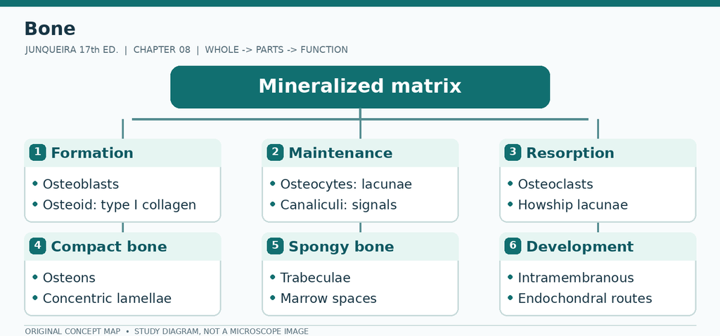

Chapter 8 original concept map: Mineralized matrix; branches for Formation, Maintenance, Resorption, Compact bone, Spongy bone, Development

**Two pathways to remember**

- **Composition:** Bone cells → osteoblast (build) → osteocyte (embedded) / osteoclast (resorb)
- **Progression:** Compact bone → osteon → central canal + lamellae + lacunae

### Quick notes — understand in 90 seconds

- **Osteoblast:** bone-forming cell on a surface; secretes osteoid.
- **Osteocyte:** mature cell in lacunae connected by canaliculi.
- **Osteoclast:** large multinucleated bone-resorbing cell in Howship lacunae.
- **Compact bone:** osteons with concentric lamellae around central canals.
- **Spongy bone:** trabeculae with marrow spaces; bone matrix is rich in **type I collagen** and mineral.

**High-yield comparison:** Osteoblasts **build**; osteoclasts **resorb**; osteocytes **maintain and sense**.

> **MNEMONIC** — **Blasts build, clasts clear**; lacunae hold osteocytes.

**Recall without looking:** Which bone cell is multinucleated and lies in a resorption depression?

**Visual anchor — simplified schematic:**

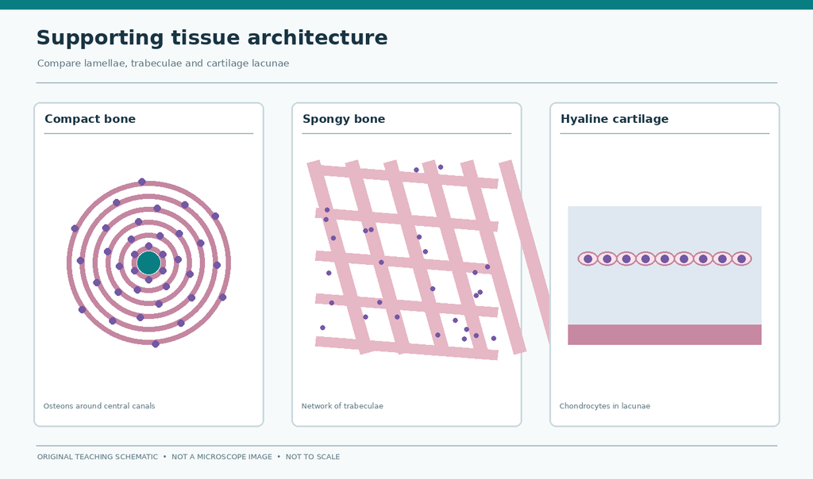

Original schematic comparing compact and trabecular bone with cartilage

### Learning objectives

By the end of this chapter you should be able to:

1. Describe the cells and matrix of bone and how each contributes to strength and turnover.
2. Distinguish woven from lamellar bone, and compact from spongy bone.
3. Sequence endochondral and intramembranous ossification.
4. Explain remodeling, calcium homeostasis, and fracture repair.

### The core idea

Bone is the main constituent of the adult skeleton: it gives **solid support**, protects vital organs of the cranial and thoracic cavities, encloses **medullary cavities** where blood cells form, and acts as a **reservoir of calcium and phosphate**, storing or releasing them to keep body fluid concentrations constant. It also forms a system of **levers** that multiply the force of muscle contraction into movement.

Its stiffness comes from mineral, its toughness from collagen, and its capacity to adapt from four cell types that continuously demolish and rebuild it — and most skeletal disease reflects failure of one of those cells, or of the balance between them.

### Bone Cells

| Cell | Origin | Function | Marker / feature |
| --- | --- | --- | --- |
| **Osteoprogenitor** | Mesenchyme | Divide and differentiate into osteoblasts | Periosteum (inner layer), endosteum |
| **Osteoblast** | Osteoprogenitor (periosteum, endosteum) | Secrete **osteoid**, rich in **type I collagen** plus proteoglycans; mineralize it; regulate osteoclasts via **RANKL** | Cuboidal, basophilic, cover existing bone surfaces; **alkaline phosphatase** high |
| **Osteocyte** | Osteoblast that becomes embedded | Maintain matrix; sense mechanical load | In **lacunae**, connected by **canaliculi** via gap junctions |
| **Osteoclast** | **Monocyte/macrophage lineage** | **Resorb bone** | Large, multinucleated, **ruffled border**, resorption bay (**Howship lacuna**); **TRAP**, carbonic anhydrase II, H⁺-ATPase |

As osteoid calcifies and hardens it **entraps some osteoblasts**, which then differentiate into osteocytes sitting in **lacunae** between the lamellae, with cytoplasmic processes in **canaliculi**. Osteocytes maintain the calcified matrix and are fed from microvasculature in the **central canals of osteons** through those canaliculi.

**The osteoclast is the exception.** Every other bone cell is mesenchymal; the osteoclast is **monocyte-derived** and is the cell required for bone remodeling. It dissolves mineral by pumping H⁺ and digests collagen with cathepsin K.

**The RANK–RANKL–OPG axis:** osteoblasts express **RANKL**, which binds **RANK** on osteoclast precursors and drives differentiation; they also secrete **osteoprotegerin (OPG)**, a decoy receptor that blocks RANKL. **PTH** shifts the balance toward resorption; **estrogen** suppresses it.

### Bone Matrix

- **Inorganic (~50% of dry weight)** — calcium phosphate as **hydroxyapatite** crystals, with bicarbonate, citrate, magnesium, potassium, and sodium; compressive strength.
- **Organic (~50% of dry weight)** — **type I collagen** (90% of the organic matter), osteocalcin, osteonectin, osteopontin, proteoglycans, growth factors; tensile strength. Some references give a 65:35 ratio instead; both conventions are in current use, so state which one you are using.

Remove the mineral and bone becomes flexible; remove the collagen and it becomes brittle. **Bone is strong because it is both at once.**

### Periosteum & Endosteum

**Periosteum** — dense connective tissue with a mainly **fibrous layer** over a more **cellular** layer; small vessels penetrate the matrix from it. Absent on articular surfaces and at tendon insertions. **Endosteum covers all trabeculae around the marrow cavities** — not merely the shaft. Both are sources of osteoprogenitor cells for growth and repair.

### Types of Bone

**Compact (cortical)** bone — dense, on the surface; built of **osteons (Haversian systems)**: concentric lamellae around a central **Haversian canal** containing vessels and nerves, with **osteocytes** in lacunae linked by canaliculi, and **Volkmann canals** running transversely.

**Spongy (cancellous)** bone — a network of **trabeculae** with marrow between them, oriented along lines of mechanical stress. No true osteons.

**Woven versus lamellar.** Woven bone is disorganized and produced rapidly in the fetus, fracture callus, and disease (Paget, osteosarcoma). Lamellar bone is ordered and mechanically superior; adult bone is lamellar but always being remodelled through **basic multicellular units (BMUs)**.

### Osteogenesis

**Intramembranous ossification** — mesenchyme condenses and differentiates directly into osteoblasts, depositing bone in a fibrous membrane. Produces the **flat bones of the skull, mandible, and clavicle**. No cartilage template.

**Endochondral ossification** — a hyaline cartilage model is replaced by bone. This is how **long bones** form and grow in length. The **epiphyseal plate** has **five zones**:

| Zone (from epiphysis toward diaphysis) | What happens |
| --- | --- |
| **1. Reserve (resting)** | Small, inactive chondrocytes |
| **2. Proliferative** | Chondrocytes divide in columns — the actual growth in length |
| **3. Hypertrophic** | Chondrocytes swell; the matrix is squeezed into thin septa between the columns |
| **4. Calcified cartilage** | Chondrocytes die; matrix calcifies |
| **5. Ossification** | Osteoblasts deposit bone on the calcified spicules |

Growth in **width** is **appositional**, by periosteal osteoblasts. The **primary ossification center** appears in the diaphysis; **secondary centers** in the epiphyses. When the plate ossifies, an **epiphyseal line** remains and length growth stops.

### Bone Remodeling & Repair

Fracture → **hematoma** → inflammation → **soft callus** (fibrocartilage) → **hard callus** (woven bone) → **remodeling** to lamellar bone. Immobilization and blood supply decide the outcome. **Wolff’s law** — bone is laid down where it is loaded and resorbed where it is not — explains both trabecular architecture and the bone loss of bed rest.

### Metabolic Role of Bone

Bone is the body’s calcium and phosphate reservoir.

| Hormone | Source | Effect on bone | Net serum calcium |
| --- | --- | --- | --- |
| **PTH** | Parathyroid chief cells | Increases resorption, increases renal reabsorption, activates vitamin D | **Raises** |
| **Calcitriol (1,25-(OH)₂D)** | Kidney | Increases intestinal absorption and bone resorption | **Raises** |
| **Calcitonin** | Thyroid **C cells** | Inhibits osteoclasts | **Lowers** |

### Joints

**Fibrous joints (synarthroses)** — bones united by dense connective tissue, no cavity (sutures of the skull, gomphosis of a tooth).

**Cartilaginous joints (amphiarthroses)** — bones united by cartilage: **primary** by hyaline cartilage (epiphyseal plate, first sternocostal joint); **secondary** by fibrocartilage (intervertebral disc, symphysis pubis).

**Synovial joints (diarthroses)** — a joint cavity between **hyaline articular cartilage** on each bone, enclosed by a **capsule** of dense connective tissue lined by **synovial membrane**, which secretes **synovial fluid** for lubrication and nutrition of the avascular cartilage. Some joints add a **meniscus** (fibrocartilage), a **labrum**, or a **fat pad**. Because articular cartilage has no perichondrium and no vessels, it heals hardly at all — the anatomical basis of degenerative joint disease.

> **CLINICAL** — Six to learn as a set. **Osteoporosis** — reduced bone mass with normal mineralization; estrogen deficiency drives it, trabeculae are lost first, fragility fractures follow. **Rickets/osteomalacia** — unmineralized osteoid; in children the growth plate widens and deforms (rachitic rosary, bowed legs). **Paget disease** — chaotic excessive remodeling with mosaic woven bone. **Osteopetrosis** — osteoclast failure, dense but brittle bone with a crowded marrow cavity. **Achondroplasia** — failure of chondrocyte proliferation in the plate, short limbs with normal trunk. **Osteogenesis imperfecta** — defective type I collagen, brittle bones, blue sclerae.

> **MICRO** — On a ground section, **concentric lamellae around a central canal** = an osteon = compact bone. On a decalcified H&E section, osteoblasts are the row of cuboidal cells on the surface and osteocytes sit in lacunae. A **multinucleated cell in a scalloped pit** is an osteoclast resorbing.

> **MNEMONIC** — **“OsteoBlast Builds, OsteoClast Chews, OsteoCytes Communicate.”** For the epiphyseal plate, **“Rest, Proliferate, Hypertrophy, Calcify, Ossify”** — read from the joint outward.

> **TIP** — The commonest error is saying osteoclasts are mesenchymal. They are **hematopoietic**, from the monocyte–macrophage line. The second is reversing the epiphyseal zones: growth happens at the **epiphyseal** side, ossification at the **diaphyseal** side.

### Chapter 8 — summary

- Bone matrix is type I collagen plus hydroxyapatite; osteoid must mineralize before it is rigid.
- Osteoblasts make osteoid; osteocytes maintain matrix; osteoclasts resorb bone with a ruffled border.
- Osteoclasts are multinucleated and derive from the monocyte–macrophage lineage, not from osteoblasts.
- Compact bone is built of osteons; spongy bone is a trabecular lattice without osteons.
- Endochondral ossification replaces a cartilage model; intramembranous ossification forms directly in mesenchyme.
- The growth plate runs reserve → proliferative → hypertrophic → calcified → ossification zones.
- Osteogenesis imperfecta = type I collagen; achondroplasia = FGFR3; Marfan = fibrillin.
- PTH raises serum calcium; calcitonin lowers it; vitamin D increases absorption.
- Fracture repair: hematoma → fibrocartilaginous callus → bony callus → remodeling.

### Active recall

1. **Which cell makes bone matrix, and which resorbs it?** — Osteoblasts make osteoid; osteoclasts resorb bone using a ruffled border and acid.
2. **What does osteoid contain, and what mineralizes it?** — Type I collagen and proteoglycans; hydroxyapatite crystals deposit along the collagen.
3. **How do osteocytes stay alive inside lacunae?** — Their processes run through canaliculi and contact processes of neighboring cells and the central canal, allowing diffusion of nutrients.
4. **Endochondral versus intramembranous ossification?** — Endochondral replaces a cartilage model (long bones, base of skull); intramembranous forms directly in mesenchyme (flat skull bones, mandible).
5. **What happens at a growth plate, zone by zone?** — Reserve → proliferative → hypertrophic → calcified matrix → ossification, with chondrocyte death and vascular invasion.

### Exam-style question

**A child has brittle bones, blue sclerae, and recurrent fractures. Which protein is defective?**

A. Type II collagen  
B. Type I collagen  
C. Fibrillin  
D. Dystrophin

**Answer: B** — Osteogenesis imperfecta is a type I collagen defect. Type II defects cause chondrodysplasias; fibrillin causes Marfan syndrome.

### Practical identification

In a ground or decalcified section, find osteons (concentric lamellae around a central canal), interstitial and circumferential lamellae, and Volkmann canals. Identify osteocytes in lacunae with canaliculi, osteoblasts lining a surface, osteoclasts in Howship lacunae, and the endosteum and periosteum. In a developing long bone, follow the epiphyseal plate from resting cartilage to ossification and name the change at each zone.

## 9 · Nerve Tissue & the Nervous System

**SPECIALTY EXAM:** `INTERNAL MEDICINE` · `SURGERY`

**In this chapter:** Development of Nerve Tissue · Neurons · Glial Cells & Neuronal Activity · Central Nervous System · Peripheral Nervous System · Neural Plasticity & Regeneration

### Chapter mind map — see the whole first

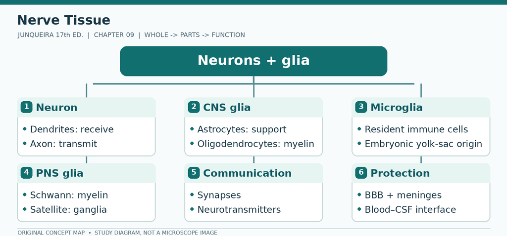

Chapter 9 original concept map: Neurons + glia; branches for Neuron, CNS glia, Microglia, PNS glia, Communication, Protection

**Two pathways to remember**

- **Composition:** Nervous tissue → neurons (signaling) + glia (support, myelin, defense)
- **Progression:** Myelin → CNS: oligodendrocyte / PNS: Schwann cell

### Quick notes — understand in 90 seconds

- **Neuron:** soma, dendrites, axon; receives and transmits electrical signals.
- **Oligodendrocytes:** myelinate several CNS axon segments.
- **Schwann cells:** support PNS axons; a myelinating Schwann cell forms one internode.
- **Astrocytes:** metabolic and structural CNS support; help regulate the local environment.
- **Microglia:** resident CNS immune cells, mainly established from embryonic yolk-sac progenitors.
- **Ependymal cells:** line ventricles and central canal.

**High-yield comparison:** **CNS myelin = oligodendrocyte; PNS myelin = Schwann cell.**

> **MNEMONIC** — Where is the axon? **CNS → oligo; PNS → Schwann**.

**Recall without looking:** Which glial cell makes myelin on several CNS axons?

### Learning objectives

By the end of this chapter you should be able to:

1. Draw a neuron and label its parts, and classify neurons by shape and function.
2. Name the six glial cell types and give each one’s job.
3. Explain how a synapse transmits a signal, and how myelin speeds conduction.
4. Compare regeneration in the peripheral and central nervous systems.

### The core idea

Nervous tissue is built for **rapid signaling over distance**. The neuron is a polarized cell with a receiving end (dendrites and soma), a conducting cable (axon), and a transmitting end (synapse). Everything else — myelin, glia, barriers — exists to make that signaling faster, safer, and better supplied.

### Development of Nerve Tissue

The nervous system arises from the **neural plate**, which folds into the **neural tube** (giving the CNS) while **neural crest** cells migrate away to form the peripheral neurons, Schwann cells, satellite cells, adrenal medulla, melanocytes, and much of the facial skeleton.

This embryology explains three exam facts: the CNS is lined by **ependyma** derived from the tube; Schwann cells are neural crest; and the adrenal medulla is neural crest while the cortex is mesoderm.

### Neurons

- **Perikaryon (soma)** — large, pale nucleus with a prominent nucleolus and abundant **Nissl bodies** (stacked RER and polysomes). Nissl substance is absent from the **axon hillock** — a useful landmark.
- **Dendrites** — short, branched, receptive; contain Nissl bodies.
- **Axon** — one per neuron, arises at the axon hillock, contains no Nissl bodies, specialized for conduction.
- **Axonal transport** — **kinesin** anterograde; **dynein** retrograde. Rabies, herpes, and tetanus toxin exploit retrograde transport.

**Classification:** multipolar (most CNS neurons and motor neurons), bipolar (retina, olfactory epithelium), pseudounipolar (sensory ganglia), anaxonic. Also by function — sensory, motor, interneuron.

**The synapse.** A chemical synapse has a presynaptic terminal with **synaptic vesicles** and mitochondria, a **synaptic cleft** (~20–30 nm), and a postsynaptic membrane with receptors. Transmission is unidirectional and modifiable. **Electrical synapses (gap junctions)** are fast and bidirectional.

### Glial Cells & Neuronal Activity

| Cell | Location | Function | Key point |
| --- | --- | --- | --- |
| **Astrocyte** | CNS | **The most numerous cell of the CNS**; hundreds of processes enclose neuronal perikarya, synapses, and capillaries, providing regulated microenvironments | **GFAP**; foot processes on capillaries; glial scar |
| **Oligodendrocyte** | CNS | Wraps flattened processes around portions of axons, forming **myelin sheaths** | One cell, many segments |
| **Microglia** | CNS | Resident phagocyte, immune surveillance | **Mesodermal** origin — the odd one out |
| **Ependymal cell** | CNS | Lines ventricles; cilia move CSF; choroid plexus | Produces CSF |
| **Schwann cell** (neurolemmocyte) | PNS | **Myelinates one segment of one axon** | Neural crest origin |
| **Satellite cell** | PNS ganglia | Supports sensory and autonomic neurons | — |

There are **six major glial types**: oligodendrocytes, astrocytes, ependymal cells, and microglia in the CNS; Schwann cells and satellite cells in the PNS. **Myelination:** in the PNS a Schwann cell wraps one axon segment; in the CNS an oligodendrocyte wraps several. The gaps are **nodes of Ranvier**, where voltage-gated Na⁺ channels cluster, so the impulse jumps by **saltatory conduction**.

Velocity rises with axon diameter and myelin thickness.

### Central Nervous System

- **Cerebral cortex** — six layers; **pyramidal cells** are the output neurons; gray matter outside.
- **Cerebellar cortex** — three layers: **molecular**, **Purkinje** (large flask-shaped cells, the only output), and **granular**.
- **Spinal cord** — gray matter in an H-shaped core, white matter outside; **anterior horn** motor, posterior horn sensory. This is the reverse of the cerebral cortex.
- **Meninges** — dura, arachnoid, pia; CSF in the subarachnoid space.
- **Choroid plexus** — produces CSF.
- **Blood–brain barrier** — tight junctions between endothelial cells, reinforced by astrocyte end-feet and pericytes. Absent in the circumventricular organs (area postrema, median eminence, pineal, posterior pituitary), which is how circulating hormones reach the brain.

### Peripheral Nervous System

- **Sensory ganglia** — pseudounipolar neurons with satellite cells; **no synapses inside the ganglion**.
- **Autonomic ganglia** — multipolar neurons, synapses present.
- **Peripheral nerve** — axons in fascicles surrounded by **perineurium**, the whole nerve by **epineurium**, individual fibers by **endoneurium**.

### Neural Plasticity & Regeneration

After axotomy the distal stump undergoes **Wallerian degeneration**; the soma shows **central chromatolysis**; Schwann cells form **bands of Büngner** to guide regrowth; regeneration proceeds at about **1 mm/day**. CNS axons regenerate poorly because of inhibitory molecules (Nogo, MAG) and glial scarring. **Plasticity** — the remodeling of synapses with use — is the basis of learning and of rehabilitation after injury.

> **CLINICAL** — **Multiple sclerosis** is autoimmune demyelination in the CNS. **Guillain–Barré syndrome** is demyelination in the PNS, ascending from the legs. **Parkinson disease** is loss of dopaminergic neurons in the substantia nigra with Lewy bodies. **Alzheimer disease** shows neurofibrillary tangles and amyloid plaques. **Poliomyelitis** destroys anterior horn motor neurons and produces flaccid paralysis.

> **MICRO** — Identify neurons by the **large pale nucleus, prominent nucleolus, and clumped Nissl bodies**. The axon hillock is the pale cone where Nissl substance stops. In peripheral nerve, look for **wavy bundles of axons with myelin rings** and connective tissue sheaths. In the cerebellar cortex, the **single row of enormous Purkinje cells** is unmistakable.

> **TIP** — **Oligodendrocyte = CNS, several axons. Schwann cell = PNS, one segment of one axon.** And **microglia are the only glia of mesodermal origin.**

### Chapter 9 — summary

- Neurons are classified by shape (multipolar, bipolar, pseudounipolar) and by function (sensory, motor, interneuron).
- Nissl bodies are rough ER plus polysomes; their position marks the soma and proximal dendrites.
- Oligodendrocytes myelinate the CNS (several axons each); Schwann cells myelinate the PNS (one segment each).
- Astrocytes form end-feet, contribute to the blood–brain barrier, and scar the CNS.
- **Microglia** are the resident CNS macrophages. Under usual physiological conditions they arise mainly from **embryonic yolk-sac myeloid progenitors**, colonize the developing CNS, and largely maintain themselves by local self-renewal; they are not simply replenished from circulating adult monocytes.
- Ependymal cells line the ventricles and produce cerebrospinal fluid.
- Myelin allows saltatory conduction between nodes of Ranvier.
- The blood–brain barrier is sealed by tight junctions between capillary endothelial cells.
- Peripheral axons can regrow along Schwann-cell **bands of Büngner** under favorable conditions; regeneration after adult CNS axonal injury is markedly restricted.

### Active recall

1. **Which glial cell myelinates the CNS, and which myelinates the PNS?** — Oligodendrocyte (CNS, several axons); Schwann cell (PNS, one segment of one axon).
2. **Which CNS glia act as resident macrophages, and where do they originate?** — Microglia; mainly from embryonic yolk-sac myeloid precursors rather than the adult circulating monocyte pool.
3. **What forms the blood–brain barrier?** — Tight junctions between capillary endothelial cells, reinforced by astrocyte end-feet and pericytes.
4. **How is a signal carried along an axon?** — An action potential; myelin allows saltatory conduction between nodes of Ranvier.
5. **Why does CNS injury scar rather than regenerate?** — Oligodendrocytes and myelin inhibit axon growth, astrocytes form a glial scar, and there is no permissive sheath like the PNS bands of Büngner.

### Exam-style question

**A peripheral nerve is cut and surgically reapproximated. Which cell guides regrowing axons?**

A. Oligodendrocyte  
B. Schwann cell  
C. Astrocyte  
D. Microglial cell

**Answer: B** — Schwann cells dedifferentiate, form bands of Büngner, and provide a physical and trophic guide for the regenerating axon.

### Practical identification

Identify a neuron by its large euchromatic nucleus, prominent nucleolus and Nissl bodies; find its dendrites and its single axon hillock. Distinguish astrocytes (star-shaped), oligodendrocytes (small, round, myelinating in the CNS), microglia (small, elongated, perivascular), ependymal cells (ciliated, lining ventricles), and, in peripheral nerve, Schwann cells and satellite cells.

In a nerve trunk, find the myelin sheath, node of Ranvier, endoneurium, perineurium and epineurium.

**Three-specimen localization exercise.** An unlabeled slide has large, round neuronal somata, each surrounded by a nearly continuous ring of small satellite-cell nuclei. This favors a **sensory (dorsal-root) ganglion**, not a peripheral nerve trunk. A second section has parallel bundles of nerve fibers enclosed by a distinct perineurium, but no large neuronal somata: this favors a **peripheral nerve**. A third section contains ependymal lining along a fluid-filled cavity, surrounded by nervous tissue: look for the **ventricular or central-canal region** rather than a ganglion.

| Evidence | Strongest interpretation | Important limitation |
| --- | --- | --- |
| Neuronal somata with close satellite-cell rings | Sensory ganglion | Orientation and neuronal size vary |
| Fascicles, endoneurium and perineurium, no ganglion somata | Peripheral nerve | Nodes of Ranvier may not be visible in routine H&E |
| White matter rich in myelinated fibers and glial nuclei | CNS tract | Specific glial classes may require special stains |

**Do not over-identify.** Small, dark glial nuclei in H&E usually cannot be assigned confidently to a particular glial class on nuclear appearance alone; cell-specific immunostains or ultrastructural evidence may be necessary.

## 10 · Muscle Tissue

**SPECIALTY EXAM:** `SURGERY`

**In this chapter:** Skeletal Muscle · Cardiac Muscle · Smooth Muscle · Regeneration of Muscle Tissue

### Chapter mind map — see the whole first

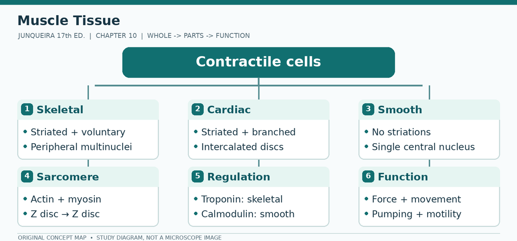

Chapter 10 original concept map: Contractile cells; branches for Skeletal, Cardiac, Smooth, Sarcomere, Regulation, Function

**Two pathways to remember**

- **Composition:** Muscle → skeletal / cardiac / smooth
- **Progression:** Sarcomere → actin + myosin → sliding → shortening (A band constant)

### Quick notes — understand in 90 seconds

- **Skeletal muscle:** striated, long multinucleated fibers with peripheral nuclei.
- **Cardiac muscle:** striated branching cells, central nuclei, intercalated discs.
- **Smooth muscle:** spindle cells with single central nuclei; no visible sarcomeric striations.
- **Sarcomere:** contractile unit between Z discs; actin slides past myosin.
- The **A band stays the same length** during normal sliding-filament contraction.

**High-yield comparison:** **Skeletal vs cardiac:** peripheral multiple nuclei versus central nuclei and intercalated discs.

> **MNEMONIC** — **Skeletal = stripes + many peripheral nuclei; cardiac = stripes + discs; smooth = no stripes**.

**Recall without looking:** What histological structure is most diagnostic of cardiac muscle?

### Learning objectives

By the end of this chapter you should be able to:

1. Distinguish skeletal, cardiac, and smooth muscle by light microscopy.
2. Explain the sarcomere and the sliding-filament mechanism.
3. Compare excitation–contraction coupling in the three muscle types.
4. Predict which muscle regenerates and which is replaced by scar.

### The core idea

Muscle tissue consists of cells that optimize the universal cell property of **contractility**. **Most muscle cells originate from embryonic mesoderm**; the intrinsic muscles of the iris and some head muscles are the standard exceptions, deriving from neural crest and other sources. Muscle differentiates by elongation and abundant synthesis of the myofibrillar proteins **actin and myosin**.

All three types use the same actin–myosin interaction but arrange it differently: **striated and voluntary** (skeletal), **striated and involuntary** (cardiac), **unstriated and involuntary** (smooth).

### Skeletal Muscle

**Organization, large to small:** muscle → fascicles → fibers → myofibrils → myofilaments. Each fiber is a long, cylindrical, **multinucleated** syncytium with **peripheral nuclei**, produced by fusion of myoblasts. Satellite cells persist beneath the basal lamina and mediate limited regeneration.

**The sarcomere**, bounded by two **Z lines**:

| Band | Contents | Behavior in contraction |
| --- | --- | --- |
| **A band** | Thick filaments (**myosin**) | Constant length |
| **I band** | Thin filaments (**actin**) only | Shortens |
| **H band** | Thick filaments only, no overlap | Shortens |
| **Z line** | Anchor for actin | Moves closer |
| **M line** | Center of the A band | — |

**Sliding filament mechanism:** myosin heads bind actin, hydrolyze ATP, and pivot, pulling thin filaments toward the M line. **The A band never changes length.**

**Control.** The **sarcoplasmic reticulum** stores Ca²⁺; **T-tubules** are invaginations of the sarcolemma that encircle each myofibril **near the aligned A- and I-band boundaries**, where each T-tubule associates with **two terminal cisternae** — a **triad**. Depolarization spreads along the T-tubules to trigger simultaneous Ca²⁺ release throughout the fiber. An action potential releases Ca²⁺, which binds **troponin C**, moves **tropomyosin** off the myosin-binding site, and contraction begins. Relaxation requires Ca²⁺ reuptake.

**Innervation.** The **motor end plate** — acetylcholine binds nicotinic receptors, depolarizes the sarcolemma, and triggers contraction. One motor neuron plus all the fibers it supplies is a **motor unit**.

**Fiber types:**

| Type | Speed | Metabolism | Fatigue | Color |
| --- | --- | --- | --- | --- |
| **I (slow, red)** | Slow | **Oxidative** | Resistant | Red |
| **IIa (fast, oxidative-glycolytic)** | Fast | Mixed | Intermediate | Intermediate |
| **IIx/IIb (fast, glycolytic)** | Fast | **Glycolytic** | Fast fatigue | White |

**Sensory receptors.** **Muscle spindles** (intrafusal fibers, Ia afferents, gamma motor neurons) sense length and stretch; **Golgi tendon organs** sense tension.

### Cardiac Muscle

- **Striated**, branched fibers, **one or two central nuclei**.
- **Intercalated discs** — the diagnostic feature — contain **fascia adherens** (anchors actin), **desmosomes** (mechanical strength), and **gap junctions** (electrical coupling), making the heart a functional syncytium.
- **Diads** at the **Z line** (one T-tubule + one cisterna), rather than the **triads** at the A–I junction of skeletal muscle.
- Abundant mitochondria and lipid droplets; highly oxidative; resistant to fatigue.
- **Purkinje fibers** — specialized conducting cells, larger and paler, with fewer myofibrils; they conduct rapidly through the ventricles.
- **Regeneration is essentially absent**; damage is repaired by fibrous scar.

### Smooth Muscle

- **Spindle-shaped** cells with a single **central** nucleus and no striations.
- Contractile apparatus: **dense bodies** (analogous to Z lines) linked by desmin and actin.
- **No troponin.** Calcium binds **calmodulin**, which activates **myosin light-chain kinase (MLCK)**.
- **Caveolae** replace T-tubules; the SR is sparse and Ca²⁺ entry across the membrane matters more.
- **Unitary (single-unit)** smooth muscle — gap junctions, spontaneous rhythmicity, in gut, uterus, bladder. **Multiunit** — each cell separately innervated, in the iris and vas deferens.
- Capable of **hypertrophy and hyperplasia** (uterine myometrium in pregnancy).

### Regeneration of Muscle Tissue

Skeletal muscle can regenerate to a limited extent from **satellite cells**; preserved basal-lamina and extracellular-matrix scaffolds favor aligned repair, whereas extensive destruction promotes fibrosis. **Adult cardiac muscle has very limited regenerative capacity**; substantial infarcts heal predominantly by replacement fibrosis rather than functional regeneration. **Smooth muscle** can both hypertrophy and, in the uterus, proliferate.

| Feature | Skeletal | Cardiac | Smooth |
| --- | --- | --- | --- |
| Striation | **Yes** | **Yes** | No |
| Nuclei | **Many, peripheral** | 1–2, **central** | 1, **central** |
| Cell shape | Long cylinder | Branched | Spindle |
| T-tubules | A–I junction, **triads** | Z line, **diads** | None (caveolae) |
| Ca²⁺ sensor | **Troponin C** | **Troponin C** | **Calmodulin** |
| Junctions | None between fibers | **Intercalated discs** | Gap junctions (unitary) |
| Control | Somatic, voluntary | Autonomic, involuntary | Autonomic, involuntary |
| Regeneration | Satellite cells (limited) | None | Hypertrophy/hyperplasia |

> **CLINICAL** — **Duchenne muscular dystrophy** is an X-linked defect of **dystrophin**, which links the sarcolemma to the extracellular matrix; without it, contraction tears the membrane, fibers die, and fat and fibrous tissue replace muscle (pseudohypertrophy). **Myasthenia gravis** is autoantibody blockade of the nicotinic acetylcholine receptor, producing fatigable weakness. **Cardiac hypertrophy** is an adaptation to pressure overload; beyond a point the myocytes outgrow their blood supply and fail.

> **MICRO** — Look first for **striations**; if present, look at the **nuclei**. **Many nuclei at the edge = skeletal. One or two central nuclei with dark transverse bands = cardiac (intercalated discs).** No striations and central nuclei in spindle-shaped cells = smooth.

> **MNEMONIC** — **“Skeletal = Surface nuclei. Cardiac = Central nucleus, Cross-striations, interCalated discs. Smooth = Spindle, Single central nucleus, no Striations.”**

> **TIP** — The A band does not shorten. This is the muscle fact to keep straight: I and H shorten, A stays constant, Z lines approach.

### Chapter 10 — summary

- Skeletal muscle: long cylinders, **many peripheral nuclei**, triads at the **A–I junction**.
- Cardiac muscle: branched cells, **one or two central nuclei**, **intercalated discs**, diads at the **Z line**.
- Smooth muscle: spindle cells, **one central nucleus**, no striations, no T-tubules (caveolae).
- Sarcomere = Z line to Z line; **A band constant**, I band and H zone shorten.
- Thin filament = actin + troponin + tropomyosin; thick filament = myosin.
- Ca²⁺ binds **troponin C** in striated muscle and **calmodulin** in smooth muscle.
- Smooth muscle contraction uses **myosin light-chain kinase**; it has no troponin.
- Intercalated discs contain **fasciae adherentes, desmosomes, and gap junctions** — not tight junctions.
- Skeletal muscle regeneration depends on **satellite cells** and is more effective when extracellular-matrix scaffolds are preserved.
- Adult cardiomyocyte renewal is very limited; a substantial myocardial infarct heals mainly through scar formation.
- Type I fibers = slow, oxidative, fatigue-resistant. Type II = fast, glycolytic.
- Duchenne dystrophy = **dystrophin** defect; myasthenia gravis = antibody to the nicotinic receptor.
- Muscle spindle = stretch receptor; Golgi tendon organ = tension receptor.

### Active recall

1. **Which band does not change length during contraction?** — The A band, because it is the length of the thick filaments.
2. **What hides the myosin-binding site at rest, and what moves it?** — Tropomyosin; calcium binds troponin C and shifts tropomyosin.
3. **Cardiac versus skeletal muscle at the T-tubule level?** — Cardiac diads lie at the Z line; skeletal triads lie at the A–I junction.
4. **What is the calcium sensor in smooth muscle?** — Calmodulin, which activates myosin light-chain kinase; smooth muscle has no troponin.
5. **Which muscle types regenerate?** — Skeletal (limited, from satellite cells), smooth (hyperplasia/hypertrophy); cardiac does not.

### Exam-style question

**A muscle biopsy shows branched fibers with one central nucleus and dark transverse bands. What is the diagnosis?**

A. Skeletal muscle  
B. Cardiac muscle  
C. Smooth muscle  
D. Dense regular connective tissue

**Answer: B** — Branching, central nuclei, and intercalated discs are the triad of cardiac muscle.

### Practical identification

Compare the three muscle types at the same magnification. Skeletal fibers are long, cylindrical and multinucleated with peripheral nuclei and striations; cardiac fibers branch, have central nuclei, intercalated discs and perinuclear halos; smooth muscle cells are spindle-shaped with central cigar-shaped nuclei and no striations.

In skeletal muscle, identify the A band, I band, Z line and triad; in cardiac muscle, the diad at the Z line.

# PART III — TRANSPORT, DEFENSE, AND BLOOD

## 11 · The Circulatory System

**SPECIALTY EXAM:** `INTERNAL MEDICINE` · `SURGERY`

**In this chapter:** Heart · Tissues of the Vascular Wall · Vasculature · Lymphatic Vascular System

### Chapter mind map — see the whole first

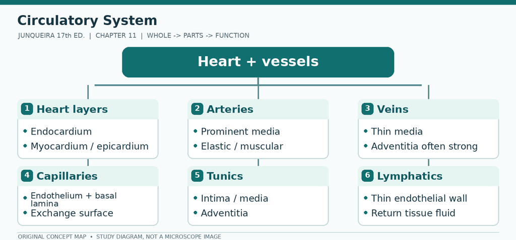

Chapter 11 original concept map: Heart + vessels; branches for Heart layers, Arteries, Veins, Capillaries, Tunics, Lymphatics

**Two pathways to remember**

- **Composition:** Vessel wall → tunica intima → media → adventitia
- **Progression:** Microcirculation → arterioles → capillaries → venules

### Quick notes — understand in 90 seconds

- Blood vessels have **tunica intima, media, and adventitia** (with variations in small vessels).
- **Arteries:** often a thicker smooth-muscle media relative to the lumen.
- **Veins:** commonly thinner media, irregular or collapsed lumina and prominent adventitia.
- **Capillaries:** mainly endothelium and its basal lamina for exchange.
- **Endothelium** is simple squamous epithelium; interpret its morphology with surrounding wall layers.

**High-yield comparison:** A round lumen alone does **not** prove artery; examine the **media** and elastic laminae.

> **MNEMONIC** — Vessel ID: **wall thickness → smooth muscle → elastic layers → surrounding tissue**.

**Recall without looking:** A vessel has a thick media and clear internal elastic lamina. Which category fits best?

**Visual anchor — simplified schematic:**

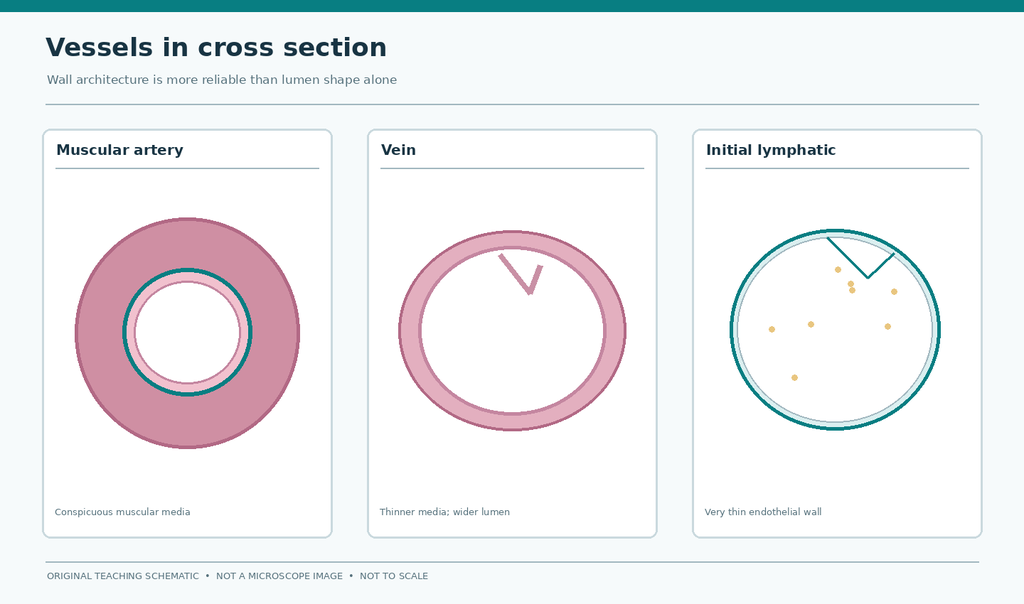

Original schematic comparing artery, vein and lymphatic capillary

### Learning objectives

By the end of this chapter you should be able to:

1. Name the three tunics of the heart and of a blood vessel, and describe what each contains.
2. Distinguish elastic artery, muscular artery, arteriole, capillary, venule, and vein in section.
3. Match each capillary type to the organ that needs it.
4. Trace the lymphatic system from blind-ended capillary to thoracic duct.

### The core idea

The circulatory system pumps and directs blood cells and substances to all tissues. The enormous capillary network provides a large exchange surface, although estimates of total capillary length and area vary with the method and assumptions used. Almost every vessel is a variation on one three-layered tube.

What changes between an aorta and a capillary is **how much muscle and elastic tissue each layer contains** — reflecting local hemodynamic forces, tissue requirements and developmental specialization.

### Heart

- **Endocardium** — endothelial lining and underlying connective tissue, continuous with the intima of vessels. A deeper **subendocardial layer**, particularly in the ventricles, may contain Purkinje fibers; they are not a universal layer of the endocardium.
- **Myocardium** — the thickest layer; cardiac muscle in complex spirals, atria thinner than ventricles, left ventricle thickest.
- **Epicardium** — connective tissue containing many **adipocytes**, covered by mesothelium; the visceral layer of the pericardium.
- **Cardiac skeleton** — dense irregular connective tissue rings that anchor the valves and electrically insulate atria from ventricles.
- **Valves** — endocardium folded over a connective-tissue core; valve leaflets are **largely avascular**, although small vessels may occur near their bases. The mitral and tricuspid have chordae tendineae and papillary muscles.

### Tissues of the Vascular Wall

| Layer | Contents | Function |
| --- | --- | --- |
| **Intima** | Endothelium, basal lamina, subendothelial connective tissue, **internal elastic lamina** (in arteries) | Non-thrombogenic surface, exchange, barrier |
| **Media** | **Smooth muscle** circularly arranged, elastic lamellae (in elastic arteries), **external elastic lamina** | Tone and compliance |
| **Adventitia** | Loose connective tissue, **vasa vasorum**, **nervi vascularis** | Anchorage and supply of the wall |

### Vasculature

| Vessel | Intima | Media | Adventitia | Distinguishing feature |
| --- | --- | --- | --- | --- |
| **Elastic artery** (aorta, pulmonary, common carotid) | Endothelium + subendothelial | **Many elastic lamellae** alternating with smooth muscle | Thin, with vasa vasorum | **Elastic lamellae** |
| **Muscular artery** | Prominent **internal elastic lamina** | Thick, 3–40 layers of smooth muscle | Moderate | **Well-defined IEL** |
| **Arteriole** | Endothelium + thin subendothelium | 1–2 layers of smooth muscle | Minimal | **The resistance vessel** |
| **Capillary** | Endothelium + basal lamina only | None | None | One cell thick |
| **Venule** | Endothelium | None or sparse pericytes | Thin | Site of **leukocyte diapedesis** |
| **Small/medium vein** | Endothelium | Thin | **Thickest layer** | Often collapsed on section |
| **Large vein** (vena cava) | Endothelium | Thin | **Thick, often with longitudinal smooth muscle** | Prominent adventitia; the venae cavae do not have the typical limb-vein valves |

**Capillaries:**

| Type | Structure | Location | Function |
| --- | --- | --- | --- |
| **Continuous** | Uninterrupted endothelium, tight junctions | Muscle, skin, lung, CNS | Regulated exchange; the **blood–brain barrier** depends on specialized CNS endothelial junctions and transport properties, supported by pericytes, basal lamina and astrocyte endfeet |
| **Fenestrated** | Endothelial pores, usually with diaphragms; **glomerular fenestrae generally lack diaphragms** | Kidney glomerulus, intestine, endocrine glands | Rapid fluid and solute exchange |
| **Sinusoidal** | Discontinuous, large gaps, incomplete basal lamina | **Liver, spleen, bone marrow** | Free passage of cells and large molecules |

**Microcirculation.** Arterioles feed capillary networks that drain into venules. Metarterioles and discrete precapillary sphincters are described in some vascular beds but are **not universal features** of all tissues. **Arteriovenous anastomoses** shunt blood directly, important in skin thermoregulation.

### Lymphatic Vascular System

Begins as blind-ended **lymphatic capillaries** with overlapping endothelial flaps and **anchoring filaments**, which open when interstitial pressure rises. They converge into collecting vessels with valves, then nodes, trunks, and the **thoracic duct** and **right lymphatic duct**.

Initial lymphatic capillaries have a discontinuous or sparse basal lamina and specialized overlapping endothelial junctions that permit interstitial fluid and cells to enter under appropriate conditions. Microbial spread and tumor-cell entry depend on additional biological mechanisms, not simply on the absence of fenestrations.

> **CLINICAL** — **Atherosclerosis** begins with endothelial dysfunction: LDL crosses the endothelium, is oxidized, and provokes monocyte recruitment. Macrophages become **foam cells**, a fatty streak forms, smooth muscle migrates into the intima, and a fibrous cap covers a necrotic core. Rupture of a thin cap exposes thrombogenic material and produces the acute coronary syndrome. **Aneurysm** follows destruction of medial elastic fibers. **Varicose veins** follow valve failure. **Lymphedema** follows lymphatic obstruction — classically after axillary node clearance.

> **MICRO** — Arteries: **round lumen, thick wall, corrugated internal elastic lamina**. Veins: **irregular collapsed lumen, thin media**. In elastic arteries the media shows wavy pink bands with no orderly muscle coat; in muscular arteries the media is uniform smooth muscle.

> **TIP** — The three capillaries are distinguished by **continuity, not size**: continuous (tight), fenestrated (pores), sinusoidal (gaps wide enough for a red cell). Liver, spleen, marrow = sinusoidal. Kidney glomerulus and intestine = fenestrated. Brain = continuous with tight junctions.

### Practical Microscopy: Artery, Vein, and Lymphatic Vessel

The first task in a vascular section is to locate the **endothelial lining**. Only after confirming a vessel should you classify it by the wall, lumen, and surrounding tissue. A collapsed vein can look like a narrow slit, while a contracted artery may show a folded internal elastic lamina.

| Feature | Muscular artery | Vein of comparable caliber | Initial lymphatic capillary |
| --- | --- | --- | --- |
| Lumen in routine sections | Often more rounded | Often irregular or collapsed | Thin-walled, often irregular |
| Dominant wall feature | Conspicuous smooth-muscle tunica media | Relatively thin media; adventitia may dominate | Endothelium with little supporting wall |
| Elastic lamina | Internal elastic lamina may be conspicuous | Usually less conspicuous | No arterial-type elastic lamina |
| Luminal contents | Erythrocytes may be present | Erythrocytes may be present | Usually no erythrocytes in normal tissue |

**Do not classify by lumen shape alone.** Fixation, tissue pressure and the angle of section can change apparent diameter. Large elastic arteries, venules and collecting lymphatics require additional criteria beyond this comparison.

**Worked case.** Two adjacent profiles have similar outer diameters. One has a thick concentric smooth-muscle media and a distinct wavy elastic lamina. The other has a thinner media and a wider, partly collapsed lumen. The first is most consistent with a **muscular artery**; the second with a **vein**.

**Blood–brain barrier distinction.** A CNS capillary is a continuous capillary, but the barrier is not created by astrocytes alone. Endothelial tight junctions and specialized low-permeability transport properties are central, while pericytes, the basement membrane and astrocytic endfeet support barrier development and maintenance.

**Active task.** In a tissue image, locate an artery–vein pair and explain the classification using two wall features. If you suspect a lymphatic, state what additional evidence (for example, lymphatic endothelial markers in an appropriate context) would improve confidence.

### Chapter 11 — summary

- Three tunics: intima (endothelium + subendothelial tissue), media (smooth muscle, elastic lamellae), adventitia (collagen).
- Elastic arteries have many concentric elastic lamellae; muscular arteries have a prominent internal elastic lamina.
- Arterioles have one or two smooth-muscle layers and control peripheral resistance.
- Continuous capillaries are the default; fenestrated ones serve endocrine glands, gut, and kidney; sinusoids serve liver, spleen, and marrow.
- Veins have thinner walls, larger lumens, and valves in medium-sized veins.
- The heart has endocardium, myocardium, and epicardium; Purkinje fibers conduct the impulse.
- Lymphatic capillaries are blind-ended and more permeable than blood capillaries; they drain to the thoracic duct.
- The thoracic duct empties into the left subclavian vein.

### Active recall

1. **Three layers of a vessel wall, outside in?** — Tunica adventitia, tunica media, tunica intima.
2. **Which vessel has a media of only one or two smooth-muscle layers and controls peripheral resistance?** — The arteriole.
3. **Which capillary type is fenestrated, and where is it found?** — Fenestrated capillaries are in endocrine glands, gut mucosa, and kidney; they allow rapid exchange.
4. **What distinguishes a vein from an artery in section?** — Veins have a larger, often collapsed lumen and a thinner wall with less muscle; valves are present in medium veins.
5. **Where does lymph begin and end?** — Blind-ended lymphatic capillaries in tissue; it drains through nodes to the thoracic duct and into the subclavian vein.

### Exam-style question

**A section shows a vessel with a thick media containing many elastic lamellae and a wide lumen. Which vessel is it?**

A. Large vein  
B. Elastic artery  
C. Arteriole  
D. Capillary

**Answer: B** — Numerous concentric elastic lamellae in a thick media define an elastic artery (aorta, pulmonary artery).

### Practical identification

Compare artery, vein and capillary in one section. Name the three tunics, and judge the artery by a thick media with concentric smooth-muscle layers and an internal elastic lamina; judge the vein by a thin media, a wide lumen and a thick adventitia. Distinguish elastic from muscular arteries by the amount of elastin in the media.

In a capillary bed, classify the endothelium as continuous, fenestrated or sinusoidal and relate that to the organ.

## 12 · Blood

**SPECIALTY EXAM:** `INTERNAL MEDICINE` · `SURGERY`

**In this chapter:** Composition of Plasma · Blood Cells

### Chapter mind map — see the whole first

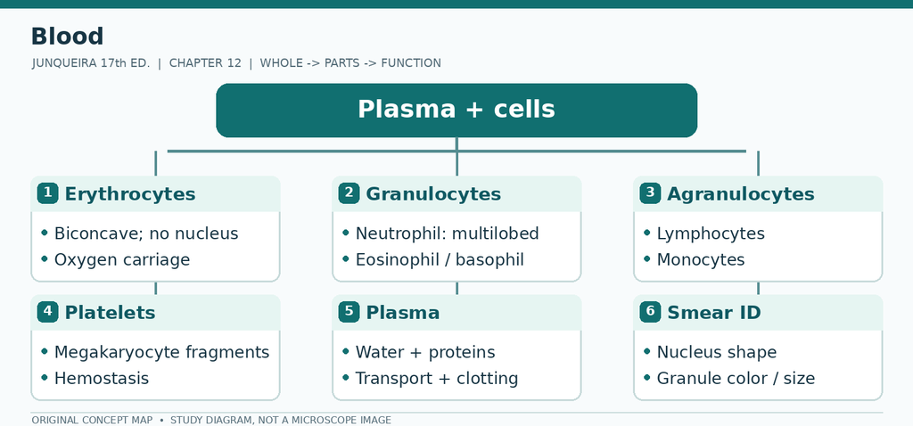

Chapter 12 original concept map: Plasma + cells; branches for Erythrocytes, Granulocytes, Agranulocytes, Platelets, Plasma, Smear ID

**Two pathways to remember**

- **Composition:** Blood → plasma + formed elements → RBC + WBC + platelets
- **Progression:** WBC → granulocytes (neutro/eosino/baso) + agranulocytes (lympho/mono)

### Quick notes — understand in 90 seconds

- **Erythrocyte:** anucleate, biconcave oxygen-transporting cell in humans.
- **Neutrophil:** segmented nucleus, fine granules; rapid response to many bacterial infections.
- **Eosinophil:** often bilobed nucleus, prominent eosinophilic granules.
- **Basophil:** coarse deeply staining granules that may conceal the nucleus.
- **Monocyte:** large, often folded nucleus; **lymphocyte:** dense round nucleus with limited cytoplasm.
- **Platelets:** small anucleate cytoplasmic fragments from megakaryocytes.

**High-yield comparison:** Monocyte and large lymphocyte are not identified by size alone; inspect **nuclear contour and cytoplasm**.

> **MNEMONIC** — **Neutro = many lobes; eosino = two lobes; baso = dark granules**.

**Recall without looking:** Which leukocyte has a bilobed nucleus and intensely eosinophilic granules?

### Learning objectives

By the end of this chapter you should be able to:

1. Describe plasma and explain how serum differs from it.
2. Relate erythrocyte shape, size, and lifespan to gas transport.
3. Identify each leukocyte by nucleus and granules, and state its function.
4. Explain platelet structure and the steps of hemostasis.

### The core idea

Blood is connective tissue with a liquid matrix. Its cells all derive from one stem cell, and their morphology is a direct readout of their job: **red for oxygen, granular white for killing, agranular white for immunity, and fragments for clotting.**

### Composition of Plasma

About **55% of blood volume**. Plasma consists mainly of water and dissolved proteins, electrolytes, nutrients, hormones, and waste. The **liver produces most major plasma proteins**, including albumin and fibrinogen, while **plasma cells produce immunoglobulins**; some complement and other circulating proteins also have extrahepatic sources.

The composition of plasma is summarized in the following table:

[output not shown]

On clotting, some proteins are consumed and others are released from platelets, leaving **serum**, whose biological properties differ from plasma. **Serum is plasma minus fibrinogen** (i.e., after clotting).

### Blood Cells

**Erythrocytes**

- **Biconcave disc**, **7.5 µm** in diameter, **2.6 µm** thick at the rim but only **0.75 µm** at the center — flexible enough to pass small capillaries; **no nucleus, no organelles**, so the cell is packed with hemoglobin.
- Lifespan about **120 days**; removed by splenic macrophages; the globin is recycled and the heme converted to bilirubin.
- Shape maintained by **spectrin and ankyrin**; defects produce hereditary spherocytosis.
- **Hemoglobin** — four globin chains, each with a heme group carrying Fe²⁺. Adult HbA (α₂β₂) and fetal HbF (α₂γ₂, higher affinity for O₂).
- **Reticulocytes** are young red cells with residual RNA, appearing polychromatic; a raised count signals active marrow output.
- **Hematocrit** — the sedimented erythrocyte column — is about **44% of total blood volume** in healthy adults; the thin layer between cells and plasma is the **buffy coat** of leukocytes and platelets. An average adult has **5–6 L** of blood.

**The leukocytes** — broadly grouped as **granulocytes** (neutrophils, eosinophils, basophils) and **agranulocytes** (lymphocytes, monocytes). The granulocytes are **12–15 µm**, with eosinophils about the same size as neutrophils or slightly larger. Lymphocytes range from **6 to 15 µm** — small, medium, and large forms — and monocytes are **12–20 µm**, the largest of the leukocytes in a smear. (Estimates differ: 12–15 µm in some descriptions, 12–20 µm in measurements made on smears. Both are recorded here rather than one being silently preferred.)

| Cell | % of WBC | Size | Nucleus | Cytoplasm | Main function |
| --- | --- | --- | --- | --- | --- |
| **Neutrophil** | **50–70%** | **12–15 µm** | **3–5 lobes**, dense | Pale; fine granules | **Phagocytosis of bacteria**; the acute responder |
| **Eosinophil** | **1–4%** | **12–15 µm** (neutrophil-sized or slightly larger) | **Bilobed** | **Bright orange-red** granules | **Parasites and allergy**; major basic protein |
| **Basophil** | **0.5–1%** | **12–15 µm** | **S-shaped**, obscured | **Large dark blue** granules | **Histamine and heparin** |
| **Lymphocyte** | **20–40%** | **6–15 µm** (small, medium, large) | Round, dense | Pale rim | **T cells**, **B cells**, **NK cells** |
| **Monocyte** | **2–8%** | **12–20 µm** (largest; some descriptions give 12–15 µm) | **Kidney-shaped** | Abundant blue-gray | Become **macrophages** |

**Neutrophil granules:** **azurophilic (primary)** granules contain myeloperoxidase and defensins; **specific (secondary)** granules contain lysozyme and lactoferrin. The neutrophil dies after phagocytosis; the accumulation of dead neutrophils and debris is **pus**. Each **phagocyte** kills ingested bacteria inside a phagolysosome.

**Platelets** are **2–4 µm** anucleate fragments of **megakaryocyte** cytoplasm, with a peripheral clear zone (hyalomere) and a central granular zone (granulomere). They number **150,000–400,000/µL** and circulate for about **10 days**. They adhere, activate, and aggregate to form the primary hemostatic plug; **von Willebrand factor** links them to collagen.

**Hemostasis in four steps** (the standard physiology sequence; this chapter describes only the platelet plug and clotting): (1) **Vascular spasm** — the injured vessel constricts, slowing flow. (2) **Primary hemostasis** — platelets bind exposed collagen (directly and through von Willebrand factor), degranulate, and aggregate into a soft plug. (3) **Coagulation** — exposed tissue factor and platelet phospholipid trigger the clotting cascade, converting prothrombin to **thrombin**, which cleaves fibrinogen into **fibrin**; the fibrin mesh stabilizes the plug as a clot. (4) **Retraction and repair** — the clot contracts, and endothelial cells and fibroblasts rebuild the wall.

> **CLINICAL** — The differential count is a diagnostic instrument. **Neutrophilia** suggests bacterial infection or steroid use; **eosinophilia** parasites or allergy; **lymphocytosis** viral infection or chronic lymphocytic leukemia; **pancytopenia** marrow failure. In **sickle cell disease** a single glutamic acid → valine substitution in β-globin allows deoxygenated HbS to polymerize; the cell sickles, occludes small vessels, and is removed by the spleen.

> **MICRO** — Count lobes, not granules. **Neutrophil: commonly 3–5 lobes. Eosinophil: usually bilobed, with orange-red granules. Basophil: granules so dark the nucleus is hidden. Monocyte: kidney-shaped nucleus, largest cell. Lymphocyte: round dense nucleus, almost no cytoplasm.**

> **MNEMONIC** — **“Never Let Monkeys Eat Bananas”** = **N**eutrophil, **L**ymphocyte, **M**onocyte, **E**osinophil, **B**asophil — in descending order of abundance.

> **TIP** — Eosinophil granules stain with eosin because they are **basic proteins** — the naming is the reverse of what students expect. The basophil’s granules contain **heparin and histamine**, so the “basic” cell is the one full of allergy mediators.

### Chapter 12 — summary

- Plasma is the fluid phase; serum is plasma after clotting and lacks fibrinogen.
- Erythrocytes are biconcave, 7.5 µm, anucleate, and live about 120 days.
- Hemoglobin is the gas carrier; the biconcave shape maximizes surface-to-volume ratio.
- Neutrophils are the most numerous leukocyte and the first responder to acute inflammation.
- Eosinophils have bilobed nuclei and orange-red granules (major basic protein); they attack parasites.
- Basophils carry histamine and heparin and mediate immediate hypersensitivity.
- Lymphocytes are the second most numerous; monocytes are the largest and become macrophages.
- Platelets are anucleate fragments of megakaryocytes and form the primary hemostatic plug.
- Hemostasis = vascular spasm → platelet plug → coagulation → clot retraction and repair.

### Active recall

1. **How does serum differ from plasma?** — Serum is plasma after clotting, so it lacks fibrinogen and consumed clotting factors.
2. **Normal erythrocyte dimensions and lifespan?** — About 7.5 µm diameter, biconcave with a 2.6-µm rim, circulating about 120 days.
3. **Which leukocyte is most numerous, and which is largest?** — Neutrophils (~50–70%); monocytes are the largest.
4. **What do eosinophil granules contain?** — Major basic protein and eosinophil cationic protein, active against parasites and in allergy.
5. **What are the four steps of hemostasis?** — Vascular spasm, primary hemostasis (platelet plug), coagulation (fibrin clot), and clot retraction with repair.

### Exam-style question

**A blood smear shows a cell with a bilobed nucleus and bright orange-red granules. What is it?**

A. Neutrophil  
B. Eosinophil  
C. Basophil  
D. Monocyte

**Answer: B** — Bilobed nucleus plus large eosinophilic granules is the eosinophil.

### Practical identification

On a stained blood smear, identify erythrocytes (biconcave, anucleate, pink), platelets (small purple fragments) and each leukocyte: neutrophil (segmented nucleus, fine granules), eosinophil (bilobed, orange-red granules), basophil (dark granules obscuring the nucleus), lymphocyte (round dense nucleus, thin cytoplasm) and monocyte (kidney-shaped nucleus, abundant blue-gray cytoplasm).

**Slide identification drill.** Scan a well-stained monolayer, then classify 100 leukocytes by **nuclear shape, cytoplasmic proportion and granule appearance** and explain what each cell does; flag uncertain cells rather than assigning them by color alone.

| Unknown field | Observation | Reasoned identification |
| --- | --- | --- |
| A | A bilobed nucleus with abundant conspicuous orange-red granules | **Eosinophil** |
| B | Dense deep-purple cytoplasmic granules that partly hide the nucleus | **Basophil** |
| C | A large cell with folded or kidney-shaped nucleus and blue-gray cytoplasm | **Monocyte** |
| D | Multiple separated nuclear lobes, pale cytoplasm and fine granules | **Neutrophil** |
| E | A dark purple speck beside an erythrocyte | **Platelet only if** morphology and size are consistent across the smear; otherwise consider stain precipitate or artifact |

## 13 · Hemopoiesis

**SPECIALTY EXAM:** `INTERNAL MEDICINE` · `SURGERY`

**In this chapter:** Stem Cells, Growth Factors, & Differentiation · Bone Marrow · Maturation of Erythrocytes · Maturation of Granulocytes · Maturation of Agranulocytes · Origin of Platelets

### Chapter mind map — see the whole first

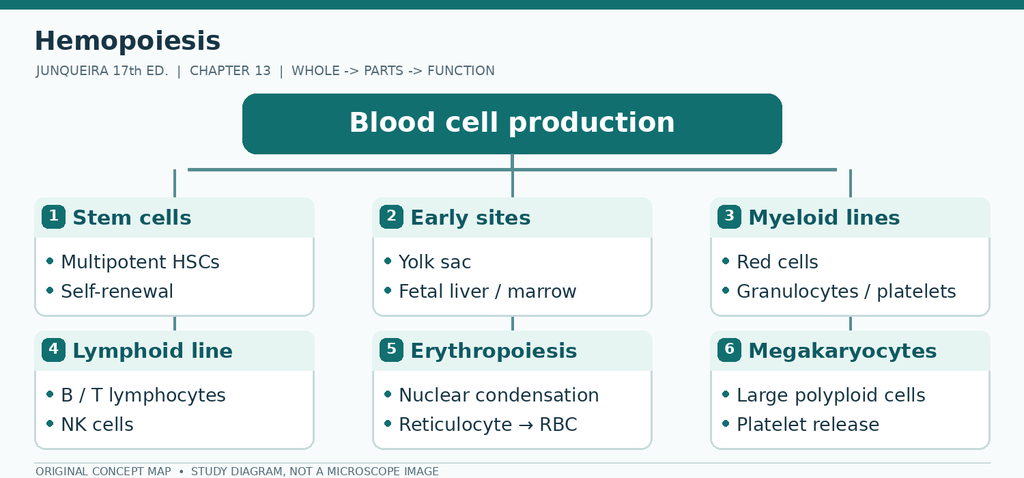

Chapter 13 original concept map: Blood cell production; branches for Stem cells, Early sites, Myeloid lines, Lymphoid line, Erythropoiesis, Megakaryocytes

**Two pathways to remember**

- **Composition:** HSC → myeloid progenitors + lymphoid progenitors → mature blood cells
- **Progression:** Erythroid maturation → erythroblast → nucleus expelled → reticulocyte → erythrocyte

### Quick notes — understand in 90 seconds

- **Red bone marrow** contains active developing blood cells, sinusoids and stromal support.
- **Hematopoietic stem cells are multipotent**, capable of generating several blood lineages.
- **Erythroid maturation:** cell becomes smaller, cytoplasm changes and nucleus is eventually expelled.
- **Megakaryocytes:** large polyploid marrow cells releasing platelet fragments.
- Erythrocytes, white blood cells and platelets have distinct developmental pathways and regulators.

**High-yield comparison:** **Reticulocyte** retains some ribosomal RNA; a mature human erythrocyte lacks a nucleus.

> **MNEMONIC** — Blood production: **stem cell → committed progenitor → immature cell → circulating cell**.

**Recall without looking:** Which marrow cell is the immediate parent of circulating platelets?

### Learning objectives

By the end of this chapter you should be able to:

1. Trace the shift of hemopoietic sites from embryo to adult.
2. Describe the marrow niche and the stromal cells that support it.
3. Follow each lineage from stem cell to mature cell, naming the recognizable stages.
4. Match growth factors and colony-stimulating factors to the lineages they drive.

### The core idea

All blood cells descend from one **hematopoietic stem cell**, and the pathway from that cell to a mature erythrocyte, granulocyte, or platelet is a sequence of named stages you can recognize by **decreasing nucleus, increasing cytoplasm, and changing color**. It is the lineage with the most named stages in histology, so it rewards systematic learning.

### Sites of hemopoiesis

| Period | Site |
| --- | --- |
| **First trimester** | Yolk sac (mesoblastic phase) |
| **Second trimester** | **Liver and spleen** (hepatic phase) |
| **Third trimester** | **Bone marrow** — marrow becomes the major organ in the third trimester as skeletal elements ossify |

In the adult, active **red marrow** persists in the **sternum, ribs, vertebrae, pelvis, skull, and proximal femur**. The rest is **yellow (fatty) marrow**, which can revert to red marrow under demand — why chronic anemia produces marrow expansion and frontal bossing.

### Stem Cells, Growth Factors, & Differentiation

The **hematopoietic stem cell (HSC)** is **multipotent**, not pluripotent: it self-renews and can give rise to the major blood-cell lineages. Human HSC-enriched populations commonly express **CD34**, but CD34 alone does not uniquely identify a functional stem cell. HSC behavior is regulated by a bone-marrow **niche** involving stromal cells, vascular cells, and extracellular matrix.

Committed **progenitor cells** — also called **CFUs** (colony-forming units) — proliferate and differentiate under growth factors, which are also called **CSFs** (colony-stimulating factors) or cytokines. Differentiation is driven by **growth factors**, listed here by name:

| Factor | Target |
| --- | --- |
| **Erythropoietin (EPO)** | Erythroid progenitors (kidney, some liver) |
| **Thrombopoietin (TPO)** | Megakaryocytes (liver) |
| **G-CSF** | Granulocyte production |
| **GM-CSF, M-CSF** | Granulocyte–monocyte and monocyte lineages |
| **IL-3** | Early multipotent progenitors |
| **IL-5** | Eosinophils |
| **SCF (stem cell factor)** | Stem cell maintenance |

### Bone Marrow

Between the trabeculae lie **hemopoietic cords** and **sinusoids** with a discontinuous endothelium, so mature cells can enter the circulation. The **myeloid:erythroid (M:E) ratio** is normally **2:1 to 4:1**; it shifts toward erythroid in hemolytic anemia and toward myeloid in infection or leukemia.

### Maturation of Erythrocytes

**Proerythroblast → basophilic → polychromatophilic → orthochromatophilic erythroblast → reticulocyte → erythrocyte**, developing in **erythropoietic islands or cords**. The names track the cytoplasm’s transition from **RNA-rich to hemoglobin-filled**; at the last stage the nucleus is **extruded**, producing a **reticulocyte** that still contains some polyribosomes when released into the circulation.

The cell **shrinks**, the nucleus **condenses and is extruded**, hemoglobin accumulates so the cytoplasm shifts from blue to pink, and the nucleolus disappears. The sequence takes about **a week**. EPO drives it; iron, vitamin B₁₂, and folate are required.

### Maturation of Granulocytes

**Myeloblast → promyelocyte → myelocyte → metamyelocyte → band cell → segmented neutrophil (or eosinophil/basophil).**

The suffixes carry the meaning: **-blast** = dividing precursor (**myeloblast**, **lymphoblast**, **proerythroblast**), **-cyte** = the later, maturing cell (**myelocyte**, **lymphocyte**, **reticulocyte**); the suffix does not by itself mean post-mitotic, because **myelocytes still divide**; **thrombocyte** is another name for the platelet.

**Primary (azurophilic) granules** appear at the promyelocyte stage, **specific granules** at the myelocyte stage, the nucleus indents at the metamyelocyte stage, and becomes a **C-shaped band** before segmenting. A **left shift** — more band forms and younger cells in the peripheral blood — indicates accelerated production: immature neutrophils, chiefly **band (stab) cells**, are released prematurely when the circulating neutrophil pool is depleted by bacterial infection.

### Maturation of Agranulocytes

**Lymphopoiesis** begins in the marrow for B cells and in the thymus for T cells. **Monopoiesis** produces monocytes that become tissue macrophages. Both pass through stages in which the nucleus becomes less lobated, the cytoplasm more abundant, and the chromatin pattern characteristic of the mature cell.

### Origin of Platelets

**Megakaryoblasts → megakaryocytes**, which become polyploid and develop **demarcation membranes** that delineate future platelet territories; platelets bud from the cytoplasm under TPO control.

> **CLINICAL** — **Aplastic anemia** is marrow failure with an empty, fatty marrow and pancytopenia. **Leukemia** is the opposite: marrow packed with malignant blasts, crowding out normal lineages and producing anemia, infection, and bleeding. **Megaloblastic anemia** (B₁₂ or folate deficiency) shows nuclear–cytoplasmic asynchrony — the nucleus matures more slowly than the cytoplasm, so cells are large and hypersegmented. **Iron deficiency** produces microcytic hypochromic cells because hemoglobin synthesis lags behind cell division.

> **MICRO** — Identify the lineage by **nucleus-to-cytoplasm ratio and granule color**. Early cells have a large nucleus, a thin rim of basophilic cytoplasm, and a nucleolus. As cells mature, the ratio falls, granules appear, and the nucleus condenses. **Maturation moves in one direction: nucleus shrinks, cytoplasm grows, color shifts from blue to pink or from blue to granular.**

> **TIP** — Two facts that are easy to invert: **EPO comes from the kidney** (peritubular interstitial cells), and **TPO comes mostly from the liver**. Students routinely invert these.

### Chapter 13 — summary

- Hemopoiesis shifts from yolk sac → liver and spleen → bone marrow; the adult site is red marrow of the axial skeleton.
- The marrow stroma (reticular cells, macrophages, adipocytes, endothelial cells) forms the hematopoietic niche.
- Erythropoiesis: proerythroblast → basophilic → polychromatophilic → orthochromatophilic normoblast → reticulocyte → erythrocyte.
- The nucleus is extruded at the orthochromatophilic erythroblast stage, producing the reticulocyte, which still contains residual RNA.
- Granulopoiesis: myeloblast → promyelocyte → myelocyte → metamyelocyte → band → segmented cell.
- Specific granules appear at the myelocyte stage; azurophilic granules at the promyelocyte stage.
- Megakaryocytes are polyploid and shed platelets from their cytoplasm.
- Erythropoietin from the kidney drives erythroid production; G-CSF drives granulocytes.
- The normal myeloid-to-erythroid ratio is about 2:1 to 4:1.

### Active recall

1. **Where does hemopoiesis occur in the adult?** — Red marrow of the axial skeleton (vertebrae, ribs, sternum, pelvis, proximal femur).
2. **What is the first recognizable erythroid precursor, and when is the nucleus lost?** — The proerythroblast; the nucleus is extruded at the orthochromatophilic erythroblast stage, leaving a reticulocyte that still contains residual RNA.
3. **How do you recognize a megakaryocyte?** — A huge polyploid cell with a lobulated nucleus whose cytoplasm fragments into platelets.
4. **Which growth factor drives erythroid production?** — Erythropoietin, made by peritubular interstitial cells of the kidney.
5. **What does the M:E ratio describe?** — The ratio of myeloid (granulocytic) to erythroid precursors in marrow, normally about 2:1 to 4:1.

### Exam-style question

**A bone marrow smear shows a cell with a large, lobulated nucleus and abundant granular cytoplasm producing platelets. What is it?**

A. Megakaryocyte  
B. Osteoclast  
C. Macrophage  
D. Proerythroblast

**Answer: A** — The megakaryocyte is the polyploid platelet factory; osteoclasts are multinucleated but resorb bone, not make platelets.

### Practical identification

In a marrow smear, identify the erythroid series by its round nucleus, progressively condensed chromatin and pink cytoplasm, and the granulocytic series by its granules and nuclear indentation. Name each stage by nuclear shape and cytoplasmic color rather than by size alone. Find a megakaryocyte by its large, lobulated nucleus, and explain how platelets are shed from it.

## 14 · The Immune System & Lymphoid Organs

**SPECIALTY EXAM:** `INTERNAL MEDICINE` · `SURGERY`

**In this chapter:** Innate & Adaptive Immunity · Cytokines · Antigens & Antibodies · Antigen Presentation · Cells of Adaptive Immunity · Thymus · Mucosa-Associated Lymphoid Tissue · Lymph Nodes · Spleen

### Chapter mind map — see the whole first

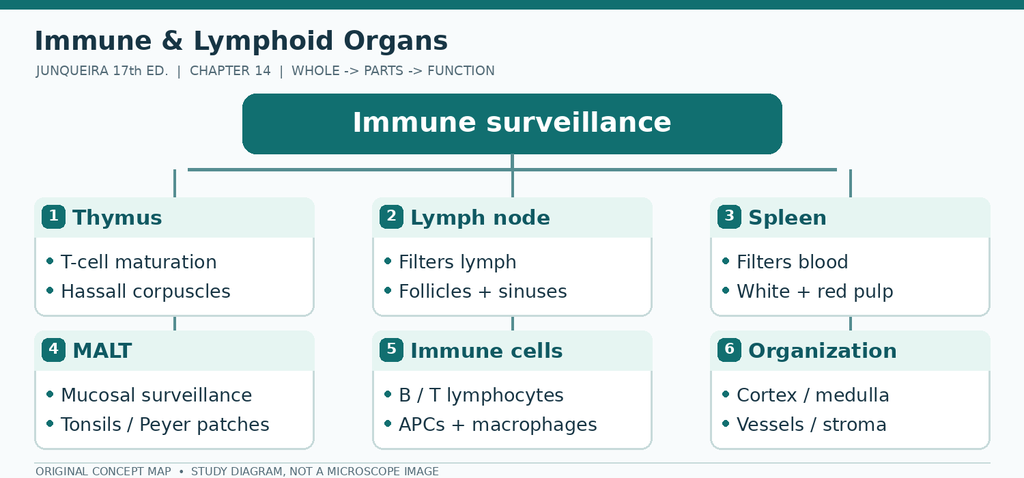

Chapter 14 original concept map: Immune surveillance; branches for Thymus, Lymph node, Spleen, MALT, Immune cells, Organization

**Two pathways to remember**

- **Composition:** Lymphoid organs → thymus (maturation) / nodes (lymph) / spleen (blood)
- **Progression:** Adaptive response → APCs present antigen → T cells / B cells respond

### Quick notes — understand in 90 seconds

- **Thymus:** lymphocyte-rich cortex, paler medulla, Hassall corpuscles; T-cell maturation.
- **Lymph node:** capsule, subcapsular sinus, cortical follicles, paracortex, medullary cords.
- **Spleen:** white pulp for immune responses; red pulp for blood filtration.
- **MALT/tonsils:** immune surveillance along mucosal surfaces.
- **Germinal centers** occur in active B-cell follicles—not in normal thymic lobules.

**High-yield comparison:** **Spleen filters blood; lymph nodes filter lymph; thymus matures T cells**.

> **MNEMONIC** — Hassall corpuscles → **thymus**; red and white pulp → **spleen**.

**Recall without looking:** A lobulated lymphoid organ contains Hassall corpuscles. Name it.

**Visual anchor — simplified schematic:**

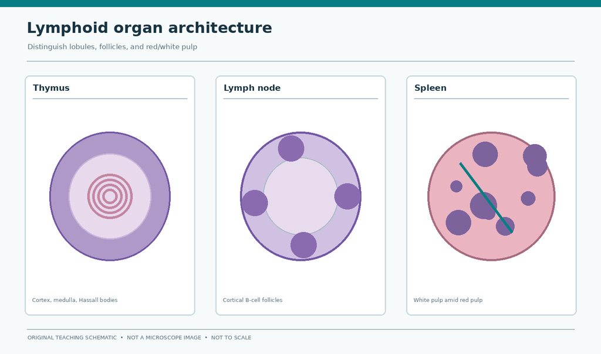

Original schematic comparing major lymphoid tissues

### Learning objectives

By the end of this chapter you should be able to:

1. Contrast innate and adaptive immunity in cells, speed, and memory.
2. Explain antigen presentation by MHC I and MHC II and the T-cell classes they activate.
3. Compare the architecture and function of thymus, lymph node, MALT, and spleen.
4. Explain how T and B cells are selected and activated, and what happens when selection fails.

### The core idea

The immune system is a set of organs arranged to **bring antigen to lymphocytes**. Each organ is a different solution to the same problem: how to filter a fluid (blood, lymph, or air/food), trap antigen, and present it to the right cell.

### Innate & Adaptive Immunity

| Feature | Innate | Adaptive |
| --- | --- | --- |
| Timing | **Present from birth**, acts within minutes | **Develops more slowly**, improves with exposure |
| Specificity | Broad molecular patterns | **Exact antigen** |
| Memory | None | **Yes** |
| Cells | **Granulocytes** (mainly neutrophils), macrophages, dendritic cells, NK cells | **T and B lymphocytes** |
| Mediators | **Defensins, complement, lysozyme, interferons**, cytokines | Antibodies, cytotoxic granules |

A working definition is worth memorizing: innate immunity is present from birth and uses leukocytes (mainly granulocytes) plus soluble proteins; adaptive immunity develops more slowly and is **based on antigen presentation to lymphocytes**.

### Cytokines

**Polypeptide hormones of the immune system**, secreted by immune cells to regulate one another. The ones worth naming: **interleukins** (IL-1, IL-2 for T-cell proliferation, IL-4 for IgE and Th2 responses, IL-5 for eosinophils, IL-6 for acute-phase response), **interferons** (antiviral; IFN-γ activates macrophages), **TNF-α** (inflammation, fever, cachexia), **chemokines** (directed leukocyte migration), and **colony-stimulating factors** (hemopoiesis, Chapter 13). Cytokines act locally (paracrine) or on the secreting cell (autocrine), and their excessive release produces a cytokine storm and the systemic inflammatory response.

### Antigens & Antibodies

**Antigens** are molecules recognized by the adaptive immune system; **epitopes** are the specific parts bound by a receptor. **Antibodies** are immunoglobulins:

| Class | Structure | Main role |
| --- | --- | --- |
| **IgG** | Monomer | Most abundant; crosses the placenta; opsonizes |
| **IgM** | Pentamer | First responder; complement activation |
| **IgA** | Dimer with secretory component | Mucosal secretions |
| **IgE** | Monomer | Mast-cell binding; allergy and parasites |
| **IgD** | Monomer | B-cell receptor |

### Antigen Presentation

**T cells cannot see free antigen.** They recognize peptide displayed on **MHC** molecules:

- **MHC class I** — expressed on **most nucleated cells**, presenting intracellularly derived peptide fragments (including viral peptides in infected cells) to **CD8⁺ cytotoxic T cells**. Some specialized cells, such as certain placental trophoblast populations, have distinct MHC-I expression patterns.
- **MHC class II** — expressed chiefly by **professional antigen-presenting cells** (dendritic cells, macrophages, B lymphocytes) and also by specialized cells such as thymic epithelial cells; expression can be induced in other cells during inflammation. It commonly presents peptides from extracellular proteins processed in endosomal compartments, including **self as well as foreign antigens**, to **CD4⁺ T cells**. The distinction from MHC I is useful but not absolute, because cross-presentation and other processing routes exist.

This pairing — **CD4/MHC II, CD8/MHC I** — is the one to know cold.

### Cells of Adaptive Immunity

**T lymphocytes** mature in the thymus and are responsible for cell-mediated immunity. Their **T-cell receptor (TCR)** is usually an **αβ heterodimer**; each T cell also carries one CD marker that fixes its class:

| T-cell class | Marker | Job |
| --- | --- | --- |
| **Helper T cell** | **CD4⁺** | Recognizes MHC II; secretes cytokines that activate B cells and macrophages |
| **Cytotoxic T cell** | **CD8⁺** | Recognizes MHC I; kills infected or tumor cells |
| **Regulatory T cell** | **CD4⁺ CD25⁺** | Suppresses immune responses and prevents autoimmunity |
| **γδ T cell** | γδ TCR | Mainly in **epithelia**; early defense at body surfaces |

**B lymphocytes** mature in bone marrow and carry a **B-cell receptor (BCR)** — surface **IgM or IgD** — that binds antigen directly, without MHC. On activation they become **plasma cells** (antibody factories) and **memory cells**. **NK cells** kill without prior sensitization and without MHC restriction.

### How a Lymphoid Nodule Forms

This sequence explains every secondary lymphoid organ in the chapter:

1. Lymphocytes are packed in a meshwork of **reticulin** made by **fibroblastic reticular cells**; most APCs among them are **dendritic cells** with many processes.
2. In a secondary organ, **follicular dendritic cells (FDCs)** display antigen–antibody complexes on their large surface. A B cell whose BCR binds that antigen is held there.
3. With cytokines from helper T cells, that B cell **proliferates clonally**, producing a large transient nodule with a pale **germinal center**.
4. Selected B cells can exit as **antibody-secreting plasma cells** or **memory B cells**. T follicular helper cells support the germinal-center reaction; the germinal center is **not a production site for memory T cells**. An active secondary follicle has a pale germinal center, whereas a resting primary follicle lacks one.

### Thymus

- **Capsule** with trabeculae dividing it into lobules, each with a **cortex** and a **medulla**.
- **No follicles.** The cortex is densely packed with developing **thymocytes** and epithelial reticular cells; the medulla is paler and contains **Hassall corpuscles** — concentric whorls of epithelial cells, unique to the thymus.
- **Blood–thymus barrier** — formed by **squamous thymic epithelial cells** joined by desmosomes and occluding junctions, together with vascular endothelium and pericytes — prevents unregulated exposure of thymocytes to antigens.
- **Cortex** is packed with **T lymphoblasts (thymocytes)**, macrophages, and **thymic epithelial cells (TECs)**. Stellate TECs form a **cytoreticulum** to which lymphocytes attach instead of reticulin fibers; these TECs are **antigen-presenting cells** expressing **MHC class II** and secreting cytokines — which is why the thymus is also counted among endocrine glands.
- **Hassall corpuscles** — aggregates of medullary TECs, concentrically arranged, **up to 100 µm**, **unique to the medulla**; their cells secrete cytokines that control local dendritic cells and promote regulatory T cells for peripheral tolerance.
- Function: **T-cell maturation and selection**. **Positive selection occurs in the cortex**: only thymocytes whose TCR recognizes the individual’s own MHC molecules survive. **Negative selection occurs in the medulla**: thymocytes that bind self-antigen too tightly are deleted, leaving tolerance. Medullary TECs express **Aire**, which lets them display a wide sample of tissue self-antigens for this test.
- **Involutes** after puberty, replaced by adipose tissue.

### Mucosa-Associated Lymphoid Tissue

**Tonsils** (palatine, lingual, pharyngeal/adenoid, tubal) — a partial capsule (hemicapsule), no afferent lymphatics, epithelium invaginates into crypts. **Peyer’s patches** in the ileum; **appendix**; **MALT** throughout the gut, respiratory tract, and genitourinary tract.

### Lymph Nodes

| Region | Contents | Function |
| --- | --- | --- |
| **Cortex** | **Lymphoid follicles** — primary (dense) or secondary (with pale **germinal center** and dark mantle) | **B-cell** zone |
| **Paracortex** | Diffuse lymphoid tissue, **high endothelial venules (HEV)** | **T-cell** zone; lymphocytes enter from blood here |
| **Medulla** | Cords and sinuses, macrophages and plasma cells | Filtration; antibody secretion |

**Flow:** afferent lymphatics → subcapsular sinus → trabecular sinuses → medullary sinuses → **efferent lymphatics at the hilum**. The one-way flow explains why nodal metastases lodge first in the subcapsular sinus.

### Spleen

- **No afferent lymphatics.** It filters **blood**.
- **White pulp** — lymphocytes around a central arteriole: the **periarteriolar lymphoid sheath (PALS)** is the T-cell zone; follicles at its periphery are the B-cell zone.
- **Red pulp** — **cords of Billroth** and **sinusoids** whose elongated endothelial **stave cells** are separated by narrow slits.
- **Two routes through the red pulp.** In the **closed circulation**, capillaries from the penicillar arterioles connect directly to sinusoids. In the **open circulation** (about half of the penicillar arterioles), capillaries are open-ended and dump blood into the splenic cords, so plasma and cells must squeeze between stave cells to re-enter the vasculature. Platelets, motile leukocytes, and thin flexible erythrocytes pass; **stiff or swollen erythrocytes at the end of their 120-day life are blocked and removed by macrophages**.
- **Iron recycling.** Splenic and hepatic macrophages break down senescent erythrocyte hemoglobin. Heme oxygenase releases iron for storage in ferritin or export through ferroportin; circulating iron binds transferrin for reuse in erythropoiesis. The heme ring is catabolized to biliverdin and then bilirubin for hepatic processing and biliary excretion. **Hemopexin binds free heme in plasma** to limit heme toxicity; it is not the carrier required for every intracellular heme-degradation reaction.
- **Functions:** blood filtration, removal of old erythrocytes, immune response to blood-borne antigen, and **extramedullary hemopoiesis** in fetal life and marrow failure.

| Organ | Capsule | Afferent lymphatics | Follicles | Unique feature |
| --- | --- | --- | --- | --- |
| **Thymus** | Yes | None | **No** | **Hassall corpuscles** |
| **Lymph node** | Yes | **Yes** | Yes | Cortex/paracortex/medulla; HEV |
| **Spleen** | Yes | **None** | Yes | **White and red pulp** |
| **Tonsil** | Partial | None | Yes | Crypts |

> **CLINICAL** — **DiGeorge syndrome** is thymic aplasia (third and fourth pharyngeal pouches) with T-cell deficiency and hypocalcemia. **Severe combined immunodeficiency** is failure of both arms. **Hodgkin lymphoma** spreads contiguously through nodes and shows Reed–Sternberg cells. **Splenectomy** increases susceptibility to encapsulated organisms — pneumococcus, meningococcus, *Haemophilus influenzae* — because the spleen’s marginal zone is the first line against polysaccharide capsules.

> **MICRO** — Ask **“what is at the center of the nodule?”** Thymus: lobules with dark cortex and pale medulla plus pink whorls (Hassall corpuscles). Lymph node: capsule, subcapsular sinus, hilum. Spleen: **white pulp islands inside a red sea** of sinusoids and cords.

> **MNEMONIC** — **“Thymus Teaches T cells; Nodes Filter lymph; Spleen Filters blood.”** And **“CD4 sees MHC II (2 × 2); CD8 sees MHC I (8 × 1).”**

> **TIP** — Two negative facts are worth more than most positive ones: the **thymus has no follicles**, and the **spleen has no afferent lymphatics**.

### Chapter 14 — summary

- Innate immunity = present at birth, granulocytes and soluble proteins; adaptive = antigen presentation to lymphocytes.
- MHC I is on **most nucleated cells** and usually presents intracellular peptides to **CD8⁺** T cells.
- MHC II is expressed mainly on **dendritic cells, macrophages and B cells**, with additional specialized or inducible expression; it presents processed peptides to **CD4⁺** T cells.
- BCR = surface **IgM or IgD**; TCR is usually **αβ** with a CD co-receptor.
- T cells: CD4 helper, CD8 cytotoxic, CD4⁺CD25⁺ regulatory, γδ in epithelia.
- B cells make antibodies (humoral); T cells mediate cell-mediated immunity.
- Plasma cells secrete antibody; memory B and T cells give the rapid second response.
- Primary lymphoid organs: **bone marrow (B)** and **thymus (T)**.
- Secondary: lymph nodes, MALT, spleen — where lymphocytes are activated.
- FDCs display antigen–antibody complexes; activated B cells form germinal centers.
- Thymus: cortex = positive selection, medulla = negative selection; **Aire** displays self-antigens.
- Thymus has **no follicles** and Hassall corpuscles in the medulla.
- Lymph node: cortex B cells, paracortex T cells and HEVs, medulla cords and sinuses.
- Spleen: white pulp (PALS = T zone, follicles = B zone) and red pulp (cords + sinusoids).
- Spleen filters blood; **open circulation** lets macrophages remove stiff 120-day erythrocytes.
- Iron is stored as **ferritin**, carried by **transferrin**, and heme iron binds **hemopexin**; the rest becomes bilirubin.

### Exam-style question

**A child has thymic aplasia with absent T cells and hypocalcemia. Which structure failed to develop?**

A. First pharyngeal arch  
B. Third and fourth pharyngeal pouches  
C. Neural crest  
D. Spleen

**Answer: B** — DiGeorge syndrome is a third/fourth pharyngeal pouch defect affecting the thymus and parathyroids.

### Practical identification

Compare the four lymphoid organs. In the thymus, find lobules with a dark cortex, pale medulla and Hassall corpuscles; in a lymph node, the capsule, subcapsular sinus, cortical follicles, paracortex with high endothelial venules, and medullary cords; in the spleen, white pulp around a central arteriole and red pulp with sinusoids and cords; in a tonsil, crypts and a partial capsule.

Use the presence or absence of afferent lymphatics to separate them.

# PART IV — DIGESTION AND RESPIRATION

## 15 · Digestive Tract

**SPECIALTY EXAM:** `INTERNAL MEDICINE`

**In this chapter:** General Structure of the Digestive Tract · Oral Cavity · Esophagus · Stomach · Small Intestine · Large Intestine

### Chapter mind map — see the whole first

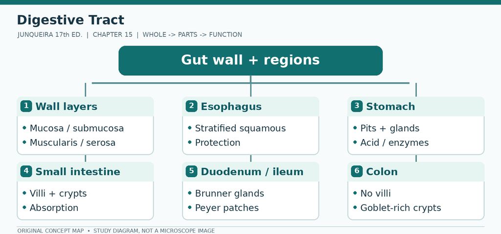

Chapter 15 original concept map: Gut wall + regions; branches for Wall layers, Esophagus, Stomach, Small intestine, Duodenum / ileum, Colon

**Two pathways to remember**

- **Composition:** GI wall → mucosa → submucosa → muscularis externa → serosa/adventitia
- **Progression:** Small intestine → duodenum (Brunner) / jejunum / ileum (Peyer)

### Quick notes — understand in 90 seconds

- Most GI segments have **mucosa, submucosa, muscularis externa, outer serosa/adventitia**.
- **Esophagus:** stratified squamous nonkeratinized lining (in most human regions).
- **Stomach:** pits and gastric glands; no intestinal villi.
- **Duodenum:** intestinal villi plus **Brunner glands** in submucosa.
- **Ileum:** villi and often **Peyer patches**; **colon:** straight goblet-rich crypts without villi.
- **Auerbach plexus:** between muscle layers; **Meissner plexus:** submucosa.

**High-yield comparison:** **Duodenum → Brunner glands; ileum → Peyer patches; colon → no villi**.

> **MNEMONIC** — Find the wall layers first; then identify **regional signature structures**.

**Recall without looking:** Which structure in the submucosa strongly supports duodenum?

**Visual anchor — simplified schematic:**

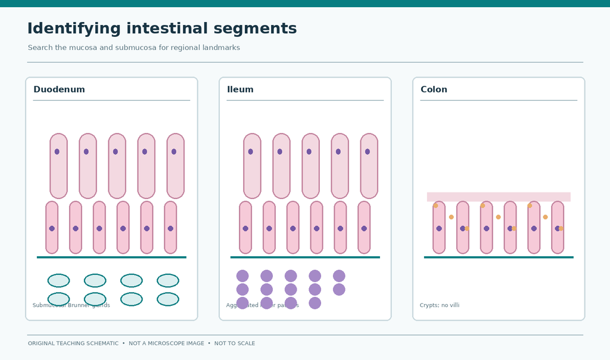

Original schematic showing duodenum, ileum and colon

### Learning objectives

By the end of this chapter you should be able to:

1. Draw and name the four layers of the gut wall and their contents.
2. Identify each segment of the digestive tract from its mucosa and muscularis.
3. Match each gastric and intestinal cell type to its product.
4. Explain how the small intestine amplifies surface area and how each nutrient is absorbed.

### The core idea

The gut is one tube with four concentric layers, and every region is a modification of those four layers for a specific job: **grinding, acidifying, absorbing, or dehydrating**. Learn the four layers and their regional variations and you can describe any segment from esophagus to anus.

### General Structure of the Digestive Tract

| Layer | Contents | Function |
| --- | --- | --- |
| **Mucosa** | Epithelium + **lamina propria** + **muscularis mucosae** | Digestion, absorption, secretion, barrier |
| **Submucosa** | Loose connective tissue, vessels, lymphatics, **Meissner (submucosal) plexus**, glands where present | Supply and control of secretion |
| **Muscularis** | Inner circular + outer longitudinal smooth muscle, **Auerbach (myenteric) plexus** between them | Peristalsis |
| **Serosa or adventitia** | Mesothelium + connective tissue (intraperitoneal) or connective tissue only (retroperitoneal) | Suspension and protection |

This is the skeleton of every answer about the gut. Two rules organize it:

- In the digestive tract the **mucosa has three components** — a lining epithelium, a lamina propria of loose connective tissue, and smooth muscle from the **muscularis mucosae**. The epithelium changes; the other two do not.
- **Serosa = suspended in the abdomen; adventitia = embedded in surrounding tissue.** The esophagus develops within the mediastinum and therefore has an adventitia along almost its whole length.

Both plexuses belong to the **enteric nervous system**: Meissner’s controls secretion and blood flow, Auerbach’s controls motility. The lymphocytes and nodules scattered through mucosa and submucosa are **MALT** (Chapter 14).

### Oral Cavity

The lining is **stratified squamous** everywhere, but the degree of keratinization tracks wear: **keratinized on the hard palate and gingiva**, partly keratinized on the lips, and **nonkeratinized** over most of the soft oral mucosa.

**Lips** — three zones: cutaneous (skin with hair and sebaceous glands), **vermilion** (thin keratinized epithelium over vascular connective tissue — the red of the lip), and mucosal (nonkeratinized, wet). A core of **striated muscle** makes the lips mobile.

**Tongue** — skeletal muscle in bundles, covered by stratified squamous epithelium with four papilla types:

| Papilla | Shape | Taste buds | Notes |
| --- | --- | --- | --- |
| **Filiform** | Cone-shaped, **heavily keratinized** | **No** | Most numerous; mechanical; gives the whitish dorsal appearance |
| **Fungiform** | Mushroom-shaped, lightly keratinized | Yes | Scattered among filiform |
| **Foliate** | Leaf-like folds | Yes | Lateral margins |
| **Vallate (circumvallate)** | Largest, **1–3 mm** wide, in a trench | **Yes, ~250 per papilla** | **8–12** in a V in front of the terminal sulcus |

**Taste buds** are ovoid intraepithelial organs of **50–100 cells**, about half of them elongated **gustatory cells** with a **7–10-day** turnover. Their microvilli project toward a **taste pore** in the epithelial surface; support cells and basal stem cells complete the bud. **Filiform papillae never carry taste buds** — a standard trap.

**Teeth.** An adult has **32 permanent teeth**. Each has a crown, a constricted neck, and roots in dental alveoli.

- **Enamel** — hardest material in the body: **96% calcium hydroxyapatite**, only **2–3% organic**, **no collagen**. It is built of **enamel rods ~5 µm wide** running the full **~2 mm** thickness. **Ameloblasts** secrete a collagen-free matrix rich in **amelogenin (20 kDa)**, which initiates and guides crystal growth. Enamel is **acellular**; ameloblasts disappear at eruption, so enamel cannot regenerate, and it is lost from decalcified sections.
- **Dentin** — **70% hydroxyapatite** in a **type I collagen** matrix, harder than bone. **Odontoblasts** (cranial neural crest) secrete **predentin**, which mineralizes within about a day. Odontoblasts can persist for many years, and their processes extend into **dentinal tubules**, although their extent varies. Sensory nerve fibers enter the inner dentin in some regions; they do not accompany every odontoblast process throughout the full dentin thickness. Movement of fluid within dentinal tubules is a leading explanation for dentin sensitivity (the **hydrodynamic theory**).
- **Cementum** — bone-like covering of the roots. **Pulp** — vascular, innervated loose connective tissue entering through apical foramina.
- **Periodontium** = **cementum + periodontal ligament + alveolar bone + gingiva**. The ligament’s collagen bundles (**Sharpey fibers**) bind cementum to bone; it is **150–350 µm** thick.

### Esophagus

A muscular tube about **25 cm** long. **Nonkeratinized stratified squamous** epithelium, a thick muscularis mucosae, **esophageal glands in the submucosa** (mucus-secreting, lubricating), and small **cardiac glands** in the lamina propria near the junction.

The muscularis shows the progression to know: **skeletal muscle at the superior end → mixed in the middle → exclusively smooth in the lower third**. The outer layer is **adventitia** except for the distal **1–2 cm**, which lies in the peritoneal cavity and has a serosa. At the **esophagogastric junction** the epithelium changes abruptly from stratified squamous to simple columnar, and the adventitia gives way to serosa.

### Practical Histology: Identifying the Esophagus–Stomach Transition

At low magnification, begin with the **luminal epithelium** rather than the thickness of the muscle wall. The esophagus has nonkeratinized stratified squamous epithelium designed to resist abrasion. The stomach has simple columnar mucous epithelium that descends into gastric pits. The transition between the two epithelial patterns is usually abrupt.

Next, inspect the **mucosal glands**. Esophageal submucosal glands are mucus-secreting and sit beneath the muscularis mucosae; the stomach’s gastric pits and glands belong to the mucosa. A gland’s position relative to the muscularis mucosae is often more informative than its color alone.

Finally, assess the **muscularis externa**. Esophageal muscle changes from skeletal to smooth along its length, while the stomach’s muscular wall is predominantly smooth muscle. Do not use muscle type alone to identify the junction: a small or obliquely cut specimen may not show the full wall.

| Observation | Favors esophagus | Favors stomach |
| --- | --- | --- |
| Surface epithelium | Stratified squamous, nonkeratinized | Simple columnar, mucous |
| Surface invaginations | No gastric pits | Gastric pits present |
| Mucosal glands | Usually absent except near the ends | Region-specific gastric glands |
| Submucosal glands | May be present | Not a defining feature |
| Best initial clue | Abrasion-resistant epithelial sheet | Secretory surface with pits |

**Clinical connection.** Chronic reflux may cause replacement of the distal esophageal squamous lining by intestinal-type columnar epithelium (Barrett esophagus). Identification and grading require proper biopsy interpretation; the mere presence of columnar cells at a junction is not sufficient by itself.

**Slide challenge.** Find the muscularis mucosae first, then locate one gland and decide whether it lies above or below that boundary. Explain why the location changes your identification.

### Stomach

**Four regions:** the superior **cardia** and inferior **pylorus** resemble each other histologically (branching mucous glands, few parietal or chief cells), while the intervening **fundus and body** contain the main gastric glands. Cardiac and pyloric glands are predominantly mucous; **parietal cells may be present in small numbers**, especially near transitions. They should not be described as categorically absent. The surface is perforated by **gastric pits**, which are lined by the same **surface mucous cells** as the stomach lumen and lead into branching glands. **No goblet cells, no villi.**

The gland epithelium contains surface mucous cells, mucous neck cells, parietal cells, chief cells, and enteroendocrine cells, plus epithelial stem and progenitor populations concentrated in the isthmus/neck region:

| Cell | Location | Product | Function |
| --- | --- | --- | --- |
| **Parietal (oxyntic)** | Upper half of gland | **HCl + intrinsic factor** | Large cell, many mitochondria, **intracellular canaliculi**; intrinsic factor is required for **vitamin B₁₂** uptake; **eosinophilic** |
| **Chief (zymogenic)** | Deeper half of gland | **Pepsinogen** | Activated to **pepsin** by luminal acid; **basophilic** with apical zymogen granules |
| **Mucous neck** | Neck | Mucus (less alkaline than surface mucus) | Secretion; the proliferative stem-cell zone lies among them |
| **Surface mucous** | Surface and pits | **Viscous mucus + bicarbonate** | The barrier that protects the mucosa |
| **Enteroendocrine** | Throughout | **Gastrin, histamine**, others | Paracrine and endocrine control of secretion |
| **Stem and progenitor cells** | Predominantly isthmus/neck region | — | Renew the gastric epithelial lineages; these are tissue-specific, not pluripotent embryonic stem cells |

Parietal cells are controlled both by **parasympathetic innervation** and by paracrine **histamine** and **gastrin** from enteroendocrine cells — the pharmacological basis of proton-pump inhibitors and H₂ blockers. The **muscularis has three layers** (oblique, circular, longitudinal), an exception to the four-layer template that allows churning.

### Small Intestine

The small intestine is several metres long in adults; measured length varies with whether it is examined in vivo or after removal and with the degree of muscular contraction. Its absorptive surface is amplified at three levels: **plicae circulares** (mucosa + submucosa, about a 3-fold increase), **villi** (mucosa, about 10-fold), and **microvilli** (cell surface, a further 20-fold), with a large cumulative increase in absorptive surface; **published total-area estimates vary considerably with the measurement method** — the clearest “structure follows function” example in the body.

Each **villus** is a finger of lamina propria covered by simple columnar epithelium, containing a **lacteal** and smooth muscle. Between villi, simple tubular **crypts (of Lieberkühn)** are the proliferative compartment. Smooth muscle of the lamina propria and muscularis mucosae, controlled by **Meissner’s plexus**, moves the villi and propels lymph; the muscularis, controlled by **Auerbach’s plexus**, produces peristalsis.

**Cell types and what each absorbs or secretes:**

- **Enterocytes** — brush border; **disaccharidases and peptidases in the glycocalyx** complete digestion, and the resulting monosaccharides and amino acids are absorbed across the brush border and pass to capillaries.
- **Goblet cells** — mucus.
- **M cells** — specialized epithelium over the lymphoid nodules, which takes up antigen from the lumen and hands it to the lymphocytes below.
- **Paneth cells** — base of crypts, **eosinophilic** granules, secrete **defensins** (and lysozyme).
- **Enteroendocrine cells** — CCK, secretin, GIP, motilin.
- **Stem cells** — crypt base, replacing the epithelium every few days.

**Lipid absorption** is different and worth knowing: lipid products associate with **bile salts**, enter enterocytes, are re-esterified to **triglycerides** and packaged as **chylomicrons**, and leave through the **lacteal** rather than the capillary.

| Region | Defining feature |
| --- | --- |
| **Duodenum** | **Duodenal (Brunner) glands in the submucosa**; leaf-like villi |
| **Jejunum** | Tallest villi; no Brunner glands; Peyer’s patches belong to the ileum |
| **Ileum** | **Peyer’s patches** (mucosal and submucosal); shortest villi |

### Large Intestine

Three regions: the short **cecum** with the **appendix**; the long **colon** (ascending, transverse, descending, **sigmoid**); and the **rectum**.

**No villi**, straight tubular crypts lined by **colonocytes** (absorptive, water and electrolyte uptake) and **abundant goblet cells**. The outer longitudinal muscle is gathered into three **teniae coli**, which produce the bulging **haustra**; the serosa carries hanging fat masses, the **omental appendages** (appendices epiploicae). Function: water and electrolyte absorption, mucus secretion, bacterial fermentation. The **appendix** is a blind diverticulum of the cecum with abundant lymphoid tissue in its lamina propria and submucosa — part of MALT.

The **rectum** continues as the **anal canal**. There the mucosa is highly vascular, folded into **anal columns (of Morgagni)** with intervening anal sinuses, and the columnar lining changes to **stratified squamous** epithelium at the rectoanal junction. Swollen mucosal or submucosal veins here are **hemorrhoids**.

> **CLINICAL** — **Peptic ulcer** — *H. pylori* breaches the mucous barrier; acid and pepsin digest the wall, classically in the duodenal bulb or gastric antrum. **Pernicious anemia** — loss of parietal cells means no intrinsic factor, so B₁₂ cannot be absorbed in the terminal ileum. **Celiac disease** — villous atrophy, crypt hyperplasia, and intraepithelial lymphocytes in the proximal small intestine, driven by gluten. **Barrett esophagus** — chronic acid reflux causes metaplasia from stratified squamous to **intestinal-type columnar epithelium with goblet cells**, a premalignant change. **Diverticulosis** — mucosa and submucosa herniate between the teniae coli; trapped feces cause diverticulitis.

> **MICRO** — Identify the segment by **the surface, not the glands**. **Villi + crypts = small intestine. No villi + deep pits + thick gland mass = stomach. No villi + straight crypts + many goblet cells = colon.** Then find the regional marker: Brunner glands = duodenum; Peyer’s patches = ileum; three muscle layers = stomach.

> **MNEMONIC** — **“Duodenum has Brunner Below; Ileum has Peyer’s Patches.”** And **“Filiform = Feel only; Vallate = Carry most taste.”**

### Practical Histology: Distinguishing Duodenum, Jejunum, Ileum, and Colon

Identify the intestinal segment from **multiple tissue layers**, not from a single villus or lymphoid nodule. Orientation, distension, and the depth of the biopsy can hide useful landmarks.

| Segment | Mucosal pattern | Most discriminating supporting feature |
| --- | --- | --- |
| Duodenum | Villi and intestinal crypts | **Brunner glands in the submucosa**; a superficial biopsy may miss them |
| Jejunum | Often prominent villi and plicae circulares | No defining Brunner glands or extensive aggregated Peyer patches in a representative full-thickness section |
| Ileum | Villi and crypts; often more goblet cells distally | **Aggregated lymphoid nodules (Peyer patches)**, typically extending into the submucosa |
| Colon | Straight crypts rich in goblet cells; **no normal villi** | Continuous crypt-rich mucosa without small-intestinal villi |

**Worked example 1.** A specimen contains villi and crypts, plus pale mucous glands *beneath the muscularis mucosae*. **Best answer:** duodenum. Confirm that the glands lie in the submucosa, rather than confusing them with ordinary intestinal crypts.

**Worked example 2.** A section shows numerous straight goblet-rich crypts and a flat luminal surface without villi. **Best answer:** colonic mucosa. A biopsy alone may not reliably distinguish individual colonic segments.

**Worked example 3.** A villous small-intestinal specimen has a large aggregate of lymphoid follicles extending toward the submucosa. **Best answer:** ileum, especially if the aggregate is characteristic of a Peyer patch. Isolated lymphoid follicles can occur elsewhere, so use the complete pattern.

**Boundary of inference.** Villus height, goblet-cell abundance and fold prominence vary along the intestine and with sampling. If submucosa is absent and the distinguishing landmarks are not seen, report *small-intestinal mucosa* rather than guessing a segment.

**Self-test.** Why can a routine mucosal biopsy fail to establish duodenal identity even when the patient has duodenal tissue? **Answer:** the biopsy may not include the submucosa, where Brunner glands are located.

### Chapter 15 — summary

- Four gut layers, outside in: mucosa, submucosa, muscularis, serosa or adventitia.
- Gut mucosa = epithelium + lamina propria + muscularis mucosae.
- Serosa where the gut is suspended; adventitia where it is embedded.
- Auerbach lies between the muscle layers (motility); Meissner lies in the submucosa (secretion, blood flow).
- Keratinized oral epithelium: hard palate and gingiva. Everywhere else, mostly nonkeratinized.
- Filiform papillae are the only type without taste buds.
- Vallate papillae: 8–12, largest, ~250 taste buds each.
- Enamel is acellular and cannot regenerate; ameloblasts disappear at eruption.
- Dentin is 70% hydroxyapatite in type I collagen; odontoblast processes stay in dentinal tubules.
- Esophageal muscle: skeletal above, mixed in the middle, smooth below.
- Esophagogastric junction: squamous → columnar, and adventitia → serosa.
- Parietal cells: HCl + intrinsic factor, intracellular canaliculi. Chief cells: pepsinogen.
- Stomach has three muscle layers and no goblet cells; the colon has teniae coli and no villi.
- Duodenum = Brunner glands; ileum = Peyer’s patches; colon = teniae coli.
- Lipids leave the villus as chylomicrons in the lacteal; sugars and amino acids enter capillaries.

### Active recall

1. **Name the four layers of the gut wall in order.** — Mucosa, submucosa, muscularis, serosa or adventitia.
2. **Which cells secrete HCl and intrinsic factor?** — Parietal cells; they have intracellular canaliculi and many mitochondria.
3. **What are the three surface amplifiers of the small intestine?** — Plicae circulares, villi, and microvilli.
4. **How do lipids leave the villus?** — As chylomicrons through the lacteal, not through capillaries.
5. **Which segment has teniae coli and no villi?** — The colon (large intestine).

### Exam-style question

**A biopsy of the small intestine shows submucosal mucous glands. Which segment is it?**

A. Duodenum  
B. Jejunum  
C. Ileum  
D. Colon

**Answer: A** — Brunner (duodenal) glands lie in the submucosa of the duodenum only.

### Practical identification

Walk the gut from esophagus to anal canal on the sections available. At each level, name the epithelium, the shape of the glands and whether villi are present. Identify the four wall layers and the two plexuses. In the stomach, distinguish parietal cells (eosinophilic, with canaliculi) from chief cells (basophilic); in the small intestine, find a villus with a lacteal and crypts with Paneth cells; in the colon, find straight crypts and teniae coli.

## 16 · Organs Associated with the Digestive Tract

**SPECIALTY EXAM:** `INTERNAL MEDICINE`

**In this chapter:** Salivary Glands · Pancreas · Liver · Biliary Tract & Gallbladder

### Chapter mind map — see the whole first

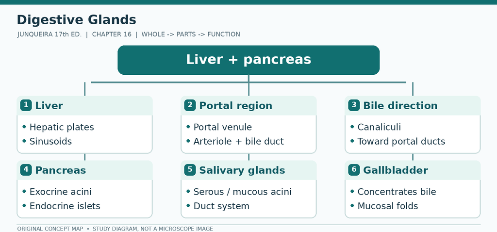

Chapter 16 original concept map: Liver + pancreas; branches for Liver, Portal region, Bile direction, Pancreas, Salivary glands, Gallbladder

**Two pathways to remember**

- **Composition:** Liver lobule → portal blood → sinusoids → central vein
- **Progression:** Pancreas → exocrine acini + endocrine islets

### Quick notes — understand in 90 seconds

- **Liver:** hepatic plates and sinusoids between portal areas and central veins.
- **Portal triad:** portal venule, hepatic arteriole, bile ductule.
- **Blood** travels through sinusoids toward the central vein; **bile** travels toward portal bile ducts.
- **Pancreas:** exocrine acini plus pale endocrine islets; centroacinar cells occur in exocrine pancreas.
- **Gallbladder:** mucosal folds and absorptive epithelium; lacks distinct muscularis mucosae and submucosa.

**High-yield comparison:** Pancreas has **islets**; salivary glands have **ducts** but no endocrine pancreatic islets.

> **MNEMONIC** — Liver: **blood inward to central vein; bile outward to portal duct**.

**Recall without looking:** In a liver lobule, which direction does bile travel relative to blood?

**Visual anchor — simplified schematic:**

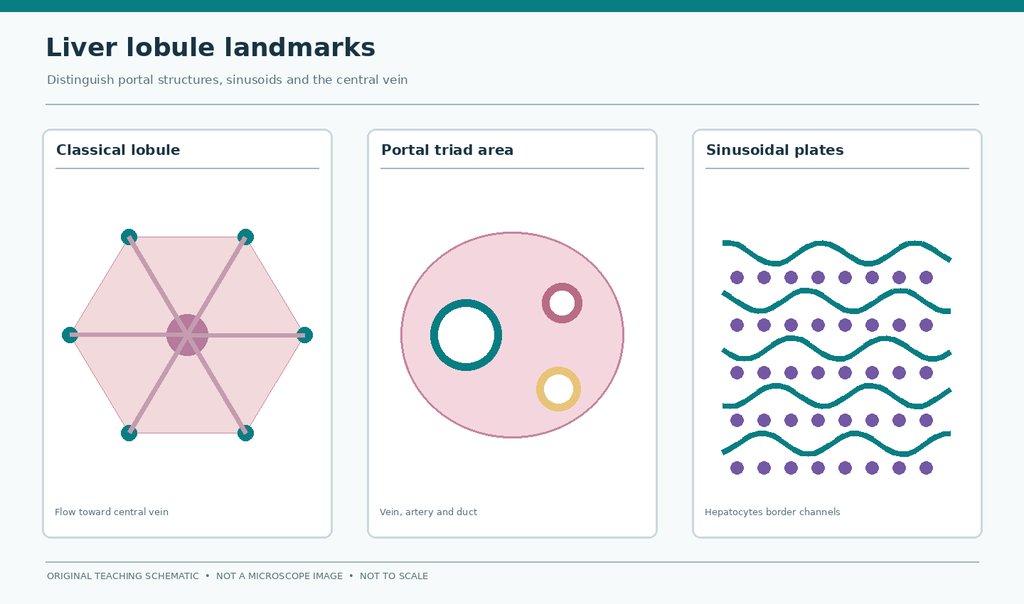

Original schematic showing liver microscopic architecture

### Learning objectives

By the end of this chapter you should be able to:

1. Compare the secretory units and ducts of the three major salivary glands.
2. Explain how the exocrine pancreas makes and delivers digestive enzymes and bicarbonate.
3. Trace blood and bile through a hepatic lobule in opposite directions.
4. Explain how the gallbladder concentrates bile and what controls its release.